# q=8 hierarchical harmonic-worldtube matching

This notebook is the executable companion to `q8_harmonic_worldtube_matching_report.pdf`. It analyzes one full-resolution q=8 volume-data slice at $T=950M_{\rm tot}$ and develops the matching calculation from first-order minimal blocks through selected second-order subsystems and alternating first-/second-order solves.

The central question throughout is:

> Do coefficients inferred from a restricted set of metric/STF blocks predict independent blocks, radial derivatives, and inverse-metric values inside the worldtube?

The small-black-hole mass is fixed to its initial-data value $M_B=1/9$. The bookkeeping parameter $\epsilon$ labels perturbative order and is set to one only when the complete truncated metric is evaluated. It is not a numerical velocity.

A common operational center is obtained from the Kretschmann dipole and then held fixed across all fitting radii. This is not an assertion that the Kretschmann center, apparent-horizon areal center, and physical singularity position coincide at finite perturbative order.

The response functions are imported from the audited q=4 package. In particular, the spatial-strain response is evaluated at fixed final/inertial points and includes transport of the spatially varying Schwarzschild background.

## How to navigate this notebook

The calculation is organized into four phases:

1. **Setup and first order (Sections 1--8).** Construct the common center, enumerate every minimal first-order estimator, test omitted STF blocks, propagate estimator ambiguity into the interior metric, and select the provisional V1+C3 hierarchy.
2. **Spatial derivatives (Sections 9--10).** Use the evolved $\Phi_{iab}$ field first as held-out radial closure and then as an additional equation in an overdetermined value-plus-derivative fit.
3. **Second order (Sections 11--14).** Subtract the fixed first-order model and known quadratic source, test the complete 43-column response space, isolate recoverable STF subsystems, and add radial derivatives.
4. **Cross-order coupling (Sections 15--16).** Alternate the selected first- and second-order solves using block Gauss--Seidel updates and test every iteration against independent interior points.

Four residuals appear repeatedly:

| name | data used | role |
| --- | --- | --- |
| **training residual** | blocks included in a solve | verifies that the selected equations can be fitted |
| **surface closure** | component/STF blocks omitted from the solve | tests angular and component consistency |
| **radial closure** | $R n^i\partial_iG^{ab}$ from $\Phi_{iab}$ | tests an independent radial observable |
| **interior error** | 768 fixed random points inside the smallest sphere | primary out-of-sample metric test |

The notebook distinguishes three statuses:

- **algebraic validation:** manufactured data are recovered to roundoff;
- **numerical validation:** a fitted subsystem predicts held-out simulation data;
- **provisional interpretation:** a trend is useful but has not yet been demonstrated across enough radii, times, and simulations.

The single-slice notebook does not contain the later ten-slice time-derivative analysis. A summary and links to those companion calculations are included after Section 16.

```python
import os
import sys
from itertools import combinations
from pathlib import Path

SPECTRE_BUILD = Path(os.environ.get(
    "SPECTRE_BUILD", "/Users/niko/caltech/spectre/build-Release"))
sys.path.insert(0, str(SPECTRE_BUILD / "bin/python"))
sys.path.insert(
    0, str(SPECTRE_BUILD / "lib/python3.13/site-packages"))

AUDIT_PACKAGE_ROOT = Path(os.environ.get(
    "GAUGE_MATCHING_AUDIT",
    "/Users/niko/caltech/worldtube-gravity/gauge-matching-audit",
))
sys.path.insert(0, str(AUDIT_PACKAGE_ROOT / "python"))

Q8_DIRECTORY = Path(os.environ.get(
    "Q8DIR", "/Users/niko/caltech/simulations/harmonic-sims/q8"))
sys.path.insert(0, str(Q8_DIRECTORY))

os.environ.setdefault("HDF5_USE_FILE_LOCKING", "FALSE")
os.environ.setdefault("MPLCONFIGDIR", "/tmp/q8-matching-matplotlib")
os.environ.setdefault("XDG_CACHE_HOME", "/tmp/q8-matching-cache")

import matplotlib
if "ipykernel" in sys.modules:
    matplotlib.use("module://matplotlib_inline.backend_inline")
import matplotlib.pyplot as plt
import numpy as np

import spectre.IO.H5 as spectre_h5
from spectre.DataStructures import DataVector
from spectre.DataStructures.Tensor import Frame, tnsr
from spectre.IO.Exporter import ObservationId, interpolate_to_points
from spectre.SphericalHarmonics import Spherepack, SpherepackIterator
from worldtube_matching.responses import (
    first_order_response_columns,
    inverse_harmonic_schwarzschild,
)
from second_order_responses import (
    FULL_GROUP_SLICES,
    FULL_PARAMETER_NAMES,
    STF_BASIS,
    STAGE1_INDICES,
    STAGE1_GROUP_SLICES,
    STAGE1_PARAMETER_NAMES,
    STAGE2_INDICES,
    STAGE3_INDICES,
    electric_response_at_direction,
    full_response_columns_at_points,
    known_quadratic_first_order_source,
    matrix_to_metric_tuple,
    spatial_quadrupole_response_at_direction,
    stage1_response_columns_at_points,
    strain_rate_response_at_direction,
    time_quadrupole_response_at_direction,
)

VOLUME_FILES = [str(Q8_DIRECTORY / "subset.h5")]
REDUCTIONS_FILE = str(Q8_DIRECTORY / "BbhReductions.h5")
VOLUME_SUBFILE = "MetricAndScalars"
OUTPUT_DIRECTORY = Path(os.environ.get("Q8_OUTPUT_DIR", Q8_DIRECTORY))
OUTPUT_DIRECTORY.mkdir(parents=True, exist_ok=True)

REQUESTED_TIME = 950.0
SMALL_BLACK_HOLE_MASS = 1.0 / 9.0
SPHEREPACK_L_MAX = 16
CENTER_FINDING_RADIUS = 0.20
RADIUS_TEST_VALUES = np.array([
    0.20, 0.24, 0.28, 0.34, 0.40,
    0.48, 0.58, 0.68, 0.80,
    0.96, 1.16, 1.36, 1.60,
])
RADIUS_OVER_SMALL_MASS = RADIUS_TEST_VALUES / SMALL_BLACK_HOLE_MASS

plt.rcParams.update({
    "figure.figsize": (10.0, 4.8),
    "figure.max_open_warning": 0,
    "axes.grid": True,
    "grid.alpha": 0.25,
    "font.size": 11,
})
```

## 1. Angular projection conventions

SpECTRE's `Spherepack` performs the physical-to-spectral transform. We retain ordinary real spherical-harmonic modes and, where useful for the center, convert through $\ell=2$ to the Cartesian polynomial basis

$$ 1,\quad n_x,\ n_y,\ n_z,\quad n_xn_y,\ n_xn_z,\ n_yn_z,\quad n_x^2-n_y^2,\quad 2n_z^2-n_x^2-n_y^2. $$

The first-order closure calculation itself keeps complete real-$Y_{\ell m}$ blocks. It therefore does not depend on manually identifying individual Cartesian STF components.

```python
def spherepack_grid(ell_max):
    spherepack = Spherepack(ell_max, ell_max)
    theta, phi = map(np.asarray, spherepack.theta_phi_points)
    directions = np.column_stack((
        np.sin(theta) * np.cos(phi),
        np.sin(theta) * np.sin(phi),
        np.cos(theta),
    ))
    return spherepack, directions


def spherical_harmonic_modes(ell_max):
    return tuple(
        (ell, m)
        for ell in range(ell_max + 1)
        for m in range(-ell, ell + 1)
    )


def spherical_harmonic_coefficients(
        values, spherepack, ell_max):
    spectral = np.asarray(
        spherepack.phys_to_spec(DataVector(np.asarray(values))))
    iterator = SpherepackIterator(
        SPHEREPACK_L_MAX, SPHEREPACK_L_MAX)
    indices = []
    for ell, m in spherical_harmonic_modes(ell_max):
        iterator.set(ell, m)
        indices.append(iterator())
    return spectral[indices]


def ylm_to_cartesian_matrix(spherepack, directions):
    nx, ny, nz = directions.T
    cartesian_basis = np.column_stack((
        np.ones_like(nx), nx, ny, nz,
        nx * ny, nx * nz, ny * nz,
        nx * nx - ny * ny,
        2.0 * nz * nz - nx * nx - ny * ny,
    ))
    cartesian_to_ylm = np.column_stack([
        spherical_harmonic_coefficients(
            cartesian_basis[:, column], spherepack, ell_max=2)
        for column in range(cartesian_basis.shape[1])
    ])
    return np.linalg.inv(cartesian_to_ylm)


def cartesian_multipoles(values):
    ylm = spherical_harmonic_coefficients(
        values, SPHEREPACK, ell_max=2)
    coefficients = YLM_TO_CARTESIAN @ ylm
    monopole = coefficients[0]
    dipole = coefficients[1:4].copy()
    quadrupole = np.zeros((3, 3))
    quadrupole[0, 1] = quadrupole[1, 0] = coefficients[4]
    quadrupole[0, 2] = quadrupole[2, 0] = coefficients[5]
    quadrupole[1, 2] = quadrupole[2, 1] = coefficients[6]
    quadrupole[0, 0] += coefficients[7] - coefficients[8]
    quadrupole[1, 1] -= coefficients[7] + coefficients[8]
    quadrupole[2, 2] += 2.0 * coefficients[8]
    return monopole, dipole, quadrupole


SPHEREPACK, DIRECTIONS = spherepack_grid(SPHEREPACK_L_MAX)
YLM_TO_CARTESIAN = ylm_to_cartesian_matrix(
    SPHEREPACK, DIRECTIONS)

print(
    f"Spherepack l_max={SPHEREPACK_L_MAX}: "
    f"{len(DIRECTIONS)} collocation points")
```

```
Spherepack l_max=16: 561 collocation points
```

## 2. Select the first downloaded slice

The volume file contains ten observations from $950M_{\rm tot}$ through $995M_{\rm tot}$ in steps of $5M_{\rm tot}$. We select the observation nearest $950M_{\rm tot}$ and use the inertial apparent-horizon center only as the initial guess for the curvature-center iteration.

```python
def volume_observations():
    with spectre_h5.H5File(VOLUME_FILES[0], "r") as h5file:
        volume = h5file.get_vol("/" + VOLUME_SUBFILE)
        return sorted([
            (
                volume.get_observation_value(observation_id),
                observation_id,
            )
            for observation_id in volume.list_observation_ids()
        ])


def horizon_b_center(time):
    with spectre_h5.H5File(REDUCTIONS_FILE, "r") as h5file:
        centers = np.asarray(h5file.get_dat(
            "/ApparentHorizons/ControlSystemAhB_Centers"
        ).get_data())
    return np.array([
        np.interp(time, centers[:, 0], centers[:, component])
        for component in range(4, 7)
    ])


def horizon_b_mass(time):
    with spectre_h5.H5File(REDUCTIONS_FILE, "r") as h5file:
        horizon = h5file.get_dat("/ObservationAhB")
        legend = list(horizon.get_legend())
        data = np.asarray(horizon.get_data())
    mass_column = legend.index("ChristodoulouMass")
    return np.interp(time, data[:, 0], data[:, mass_column])


OBSERVATIONS = volume_observations()
observation_times = np.array([time for time, _ in OBSERVATIONS])
observation_index = int(np.argmin(
    np.abs(observation_times - REQUESTED_TIME)))
TEST_TIME, TEST_OBSERVATION_ID = OBSERVATIONS[observation_index]
AH_B_CENTER = horizon_b_center(TEST_TIME)
AH_B_MASS = horizon_b_mass(TEST_TIME)

print(f"selected time:                 {TEST_TIME:.12f}")
print(f"observation id:                {TEST_OBSERVATION_ID}")
print("AH-B inertial center:          ", AH_B_CENTER)
print(f"fixed initial-data mass:       {SMALL_BLACK_HOLE_MASS:.12f}")
print(f"measured AH-B mass at slice:   {AH_B_MASS:.12f}")
print(
    "worldtube radii R/M_B:       ",
    np.array2string(RADIUS_OVER_SMALL_MASS, precision=3),
)
```

```
selected time:                 950.000000000147
observation id:                5529711531949795886
AH-B inertial center:           [-1.32765048e+01 -5.70709756e+00  1.64654468e-08]
fixed initial-data mass:       0.111111111111
measured AH-B mass at slice:   0.111111529489
worldtube radii R/M_B:        [ 1.8   2.16  2.52  3.06  3.6   4.32  5.22  6.12  7.2   8.64 10.44 12.24
 14.4 ]
```

## 3. One common Kretschmann-dipole center

For Schwarzschild,

$$ \mathcal K=\frac{48M_B^2}{r^6}, \qquad \rho=r-M_B, $$

where $r$ is the areal radius and $\rho$ the harmonic radius. We therefore infer a Schwarzschild harmonic radius from the numerical Gauss--Bonnet scalar,

$$ \rho_{\mathcal K} =\left(\frac{48M_B^2}{\mathcal K}\right)^{1/6}-M_B. $$

On a coordinate sphere of radius $R$ centered at the current guess, define

$$ F(n^i)=R^2-\rho_{\mathcal K}^2. $$

If the physical center is displaced by $\delta z^i$, then to leading order $F=2R\,\delta z_i n^i+\cdots$. Thus the Cartesian dipole gives the Newton correction

$$ \delta z_i=\frac{F_i^{\ell=1}}{2R}. $$

We resample after every correction at $R=0.2M_{\rm tot}$ and use the converged result as one common center for all fitting radii.

```
AH center:              [-1.32765048e+01 -5.70709756e+00  1.64654468e-08]
curvature center:       [-1.32763282e+01 -5.70702318e+00  1.64652910e-08]
curvature - AH center:  [ 1.76653797e-04  7.43816235e-05 -1.55831646e-13]
last center correction: [-1.02788928e-13  5.35655132e-13  1.86059797e-17] norm = 5.454282575249213e-13
```

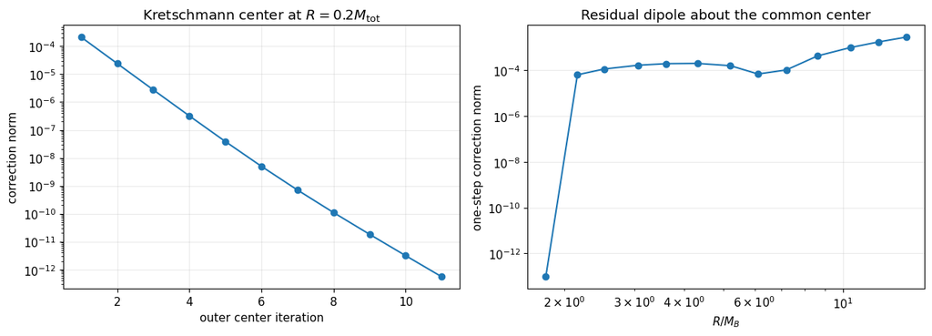

```python
def interpolate_components(
        observation_id, points, component_names):
    points = np.asarray(points)
    target_points = tnsr.I[DataVector, 3, Frame.Inertial](
        points.T.copy())
    return np.asarray(interpolate_to_points(
        VOLUME_FILES,
        subfile_name=VOLUME_SUBFILE,
        observation=ObservationId(observation_id),
        tensor_components=list(component_names),
        target_points=target_points,
        error_on_missing_points=True,
    ))


def interpolate_gauss_bonnet(
        observation_id, centers, radii):
    centers = np.asarray(centers)
    radii = np.broadcast_to(np.asarray(radii), (len(centers),))
    points = np.concatenate([
        center[None, :] + radius * DIRECTIONS
        for center, radius in zip(centers, radii)
    ])
    values = interpolate_components(
        observation_id, points, ["GaussBonnetScalar"])[0]
    return values.reshape(len(centers), len(DIRECTIONS))


def kretschmann_harmonic_radius(
        kretschmann, mass=SMALL_BLACK_HOLE_MASS):
    areal_radius = (
        48.0 * mass**2 / np.asarray(kretschmann)
    ) ** (1.0 / 6.0)
    return areal_radius - mass


def curvature_center_correction(kretschmann, radius):
    inferred_radius = kretschmann_harmonic_radius(kretschmann)
    radial_residual = radius**2 - inferred_radius**2
    _, dipole, _ = cartesian_multipoles(radial_residual)
    return dipole / (2.0 * radius)


def iterate_curvature_center(
        initial_center, radius, maximum_iterations=12,
        tolerance=1.0e-12):
    center = np.array(initial_center, dtype=float)
    history = []
    for _ in range(maximum_iterations):
        kretschmann = interpolate_gauss_bonnet(
            TEST_OBSERVATION_ID, [center], [radius])[0]
        correction = curvature_center_correction(
            kretschmann, radius)
        center += correction
        history.append((center.copy(), correction.copy()))
        if np.linalg.norm(correction) < tolerance:
            break
    return center, history


CURVATURE_CENTER, CENTER_ITERATION_HISTORY = (
    iterate_curvature_center(
        AH_B_CENTER, CENTER_FINDING_RADIUS))
center_positions = np.asarray([
    entry[0] for entry in CENTER_ITERATION_HISTORY])
center_corrections = np.asarray([
    entry[1] for entry in CENTER_ITERATION_HISTORY])

# Diagnose the remaining one-step correction on every fitting radius without
# allowing the metric fit itself to change centers.
kretschmann_by_radius = interpolate_gauss_bonnet(
    TEST_OBSERVATION_ID,
    np.repeat(CURVATURE_CENTER[None, :], len(RADIUS_TEST_VALUES), axis=0),
    RADIUS_TEST_VALUES,
)
CENTER_CORRECTIONS_BY_RADIUS = np.asarray([
    curvature_center_correction(values, radius)
    for values, radius in zip(
        kretschmann_by_radius, RADIUS_TEST_VALUES)
])

print("AH center:             ", AH_B_CENTER)
print("curvature center:      ", CURVATURE_CENTER)
print("curvature - AH center: ", CURVATURE_CENTER - AH_B_CENTER)
print(
    "last center correction:",
    center_corrections[-1],
    "norm =", np.linalg.norm(center_corrections[-1]),
)

fig_center, axes = plt.subplots(1, 2, figsize=(12.5, 4.6))
axes[0].semilogy(
    np.arange(1, len(center_corrections) + 1),
    np.linalg.norm(center_corrections, axis=1),
    "o-",
)
axes[0].set_xlabel("outer center iteration")
axes[0].set_ylabel("correction norm")
axes[0].set_title(
    rf"Kretschmann center at $R={CENTER_FINDING_RADIUS:g}M_{{\rm tot}}$")

axes[1].loglog(
    RADIUS_OVER_SMALL_MASS,
    np.linalg.norm(CENTER_CORRECTIONS_BY_RADIUS, axis=1),
    "o-",
)
axes[1].set_xlabel(r"$R/M_B$")
axes[1].set_ylabel("one-step correction norm")
axes[1].set_title("Residual dipole about the common center")
fig_center.tight_layout()
fig_center.savefig(
    OUTPUT_DIRECTORY / "q8_t950_curvature_center.pdf")
plt.show()
```

## Perturbative hierarchy used below

After centering, write the inverse metric as

$$ G^{ab} =G_{(0)}^{ab} +\epsilon A_1^{ab}p_1 +\epsilon^2\left[ Q_{11}^{ab}(p_1,p_1)+A_2^{ab}p_2 \right] +O(\epsilon^3). $$

At each order, all lower-order contributions are moved to the data side. The new coefficients then enter linearly:

$$ d_{(n),B}=A_{(n),BA}p_{(n)}^A+e_{(n),B}. $$

The source subscript denotes its **total** perturbative order. For example, $Q_{11}(p_1,p_1)$ is constructed from first-order coefficients but belongs to the second-order source because it is quadratic.

The angular STF decomposition block-diagonalizes the exact response by rotation and parity. It does not guarantee statistical independence on finite-mass-ratio data: omitted higher orders can project into the same blocks. This is why every solve below is paired with omitted-block and interior validation.

The hierarchy is linear only after lower orders are held fixed. The known quadratic source and the later first-/second-order Gauss--Seidel iteration are the two places where cross-order nonlinearity enters explicitly.

## 4. First-order response blocks

The thirteen unknown first-order affine-map coefficients are

$$ p_{(1)} =\left( \dot q^0,\, \beta_i,\, \dot q^i,\, \sigma_{ij} \right), \qquad \sigma_{ij}=\sigma_{ji}. $$

After subtracting harmonic Schwarzschild at the common curvature center,

$$ d_{\rm block} =G_{\rm numerical,block}-G_{\rm Schwarzschild,block} =R_{\rm block}\,p_{(1)}+\text{unmodeled terms}. $$

Parity and rotational structure separate the response into two independent sectors:

| Sector | Unknowns | Candidate metric/STF blocks |
| --- | --- | --- |
| Vector | $\beta_i,\dot q^i$ | $G^{TT}_{\ell=1}$, $G^{Ti}_{\ell=0,2}$, $G^{ij}_{\ell=1}$ |
| Clock/strain | $\dot q^0,\sigma_{ij}$ | $G^{TT}_{\ell=0,2}$, $G^{Ti}_{\ell=1,3}$, $G^{ij}_{\ell=0,2,4}$ |

A *minimal estimator* is an inclusion-minimal subset of candidate blocks with full column rank. It is fitted using only its selected blocks. Its held-out closure residual is

$$ \mathcal C =\frac{\lVert d_{\rm omitted}-R_{\rm omitted}\hat p\rVert_2} {\lVert d_{\rm omitted}\rVert_2}. $$

This tests whether parameters inferred from one set of metric projections predict independent projections that were not used in the fit.

```python
INVERSE_METRIC_COMPONENT_NAMES = (
    "InverseSpacetimeMetric_tt",
    "InverseSpacetimeMetric_xt",
    "InverseSpacetimeMetric_yt",
    "InverseSpacetimeMetric_zt",
    "InverseSpacetimeMetric_xx",
    "InverseSpacetimeMetric_yx",
    "InverseSpacetimeMetric_yy",
    "InverseSpacetimeMetric_zx",
    "InverseSpacetimeMetric_zy",
    "InverseSpacetimeMetric_zz",
)
SPATIAL_COMPONENTS = (
    (0, 0), (0, 1), (0, 2),
    (1, 1), (1, 2), (2, 2),
)
DATA_SPATIAL_COMPONENTS = (
    (0, 0), (0, 1), (1, 1),
    (0, 2), (1, 2), (2, 2),
)
FIRST_ORDER_PARAMETER_NAMES = (
    "qdot0",
    "beta_x", "beta_y", "beta_z",
    "qdot_x", "qdot_y", "qdot_z",
    "sigma_xx", "sigma_xy", "sigma_xz",
    "sigma_yy", "sigma_yz", "sigma_zz",
)


def interpolate_inverse_metric(
        observation_id, center, radii):
    points = np.concatenate([
        center[None, :] + radius * DIRECTIONS
        for radius in radii
    ])
    values = interpolate_components(
        observation_id,
        points,
        INVERSE_METRIC_COMPONENT_NAMES,
    )
    return values.reshape(
        len(INVERSE_METRIC_COMPONENT_NAMES),
        len(radii),
        len(DIRECTIONS),
    )


def unpack_inverse_metric(field_data):
    gtt = field_data[0]
    gti = np.moveaxis(field_data[1:4], 0, -1)
    gij = np.zeros((len(gtt), 3, 3))
    for values, (i, j) in zip(
            field_data[4:], DATA_SPATIAL_COMPONENTS):
        gij[:, i, j] = values
        gij[:, j, i] = values
    return gtt, gti, gij


def ell_block(values, ell):
    coefficients = spherical_harmonic_coefficients(
        values, SPHEREPACK, ell_max=ell)
    return coefficients[ell**2:(ell + 1)**2]


def metric_stf_block(gtt, gti, gij, block):
    metric_component, ell = block
    if metric_component == "GTT":
        return ell_block(gtt, ell)
    if metric_component == "GTI":
        return np.concatenate([
            ell_block(gti[:, component], ell)
            for component in range(3)
        ])
    if metric_component == "GIJ":
        return np.concatenate([
            ell_block(gij[:, i, j], ell)
            for i, j in SPATIAL_COMPONENTS
        ])
    raise ValueError(f"Unknown metric component {metric_component}")


FIRST_ORDER_BLOCKS = (
    ("GTT", 0), ("GTT", 1), ("GTT", 2),
    ("GTI", 0), ("GTI", 1), ("GTI", 2), ("GTI", 3),
    ("GIJ", 0), ("GIJ", 1), ("GIJ", 2), ("GIJ", 4),
)

FIRST_ORDER_METRIC_DATA = interpolate_inverse_metric(
    TEST_OBSERVATION_ID,
    CURVATURE_CENTER,
    RADIUS_TEST_VALUES,
)

BLOCK_DATA = {block: [] for block in FIRST_ORDER_BLOCKS}
BLOCK_RESPONSE = {block: [] for block in FIRST_ORDER_BLOCKS}

for radius_index, radius in enumerate(RADIUS_TEST_VALUES):
    numerical_metric = unpack_inverse_metric(
        FIRST_ORDER_METRIC_DATA[:, radius_index])
    local_points = radius * DIRECTIONS
    background_metric = inverse_harmonic_schwarzschild(
        local_points, SMALL_BLACK_HOLE_MASS)
    metric_residual = tuple(
        numerical - background
        for numerical, background in zip(
            numerical_metric, background_metric)
    )
    response_columns = first_order_response_columns(
        local_points, SMALL_BLACK_HOLE_MASS)

    for block in FIRST_ORDER_BLOCKS:
        BLOCK_DATA[block].append(
            metric_stf_block(*metric_residual, block))
        BLOCK_RESPONSE[block].append(np.column_stack([
            metric_stf_block(*response, block)
            for response in response_columns
        ]))

for block in FIRST_ORDER_BLOCKS:
    BLOCK_DATA[block] = np.asarray(BLOCK_DATA[block])
    BLOCK_RESPONSE[block] = np.asarray(BLOCK_RESPONSE[block])

print("first-order parameter order:")
print(FIRST_ORDER_PARAMETER_NAMES)
```

```
first-order parameter order:
('qdot0', 'beta_x', 'beta_y', 'beta_z', 'qdot_x', 'qdot_y', 'qdot_z', 'sigma_xx', 'sigma_xy', 'sigma_xz', 'sigma_yy', 'sigma_yz', 'sigma_zz')
```

```python
VECTOR_PARAMETER_INDICES = np.arange(1, 7)
CLOCK_STRAIN_PARAMETER_INDICES = np.r_[
    0, np.arange(7, 13)]

VECTOR_BLOCKS = (
    ("GTT", 1), ("GTI", 0),
    ("GTI", 2), ("GIJ", 1),
)
CLOCK_STRAIN_BLOCKS = (
    ("GTT", 0), ("GTT", 2),
    ("GTI", 1), ("GTI", 3),
    ("GIJ", 0), ("GIJ", 2), ("GIJ", 4),
)


def block_name(block):
    return f"{block[0]} l={block[1]}"


def estimator_label(selected_blocks):
    return " + ".join(map(block_name, selected_blocks))


def stacked_system(
        radius_index, parameter_indices, selected_blocks,
        block_data=BLOCK_DATA, block_response=BLOCK_RESPONSE):
    matrix = np.concatenate([
        block_response[block][radius_index][
            :, parameter_indices]
        for block in selected_blocks
    ], axis=0)
    data = np.concatenate([
        block_data[block][radius_index]
        for block in selected_blocks
    ])
    return matrix, data


def numerical_rank(matrix, relative_tolerance=1.0e-10):
    singular_values = np.linalg.svd(
        matrix, compute_uv=False)
    if len(singular_values) == 0 or singular_values[0] == 0.0:
        return 0
    return np.count_nonzero(
        singular_values
        > relative_tolerance * singular_values[0])


def minimal_full_rank_block_sets(
        parameter_indices, candidate_blocks):
    number_of_unknowns = len(parameter_indices)
    full_rank_sets = []
    for number_of_blocks in range(
            1, len(candidate_blocks) + 1):
        for selected_blocks in combinations(
                candidate_blocks, number_of_blocks):
            full_rank_at_every_radius = all(
                numerical_rank(stacked_system(
                    radius_index,
                    parameter_indices,
                    selected_blocks,
                )[0]) == number_of_unknowns
                for radius_index in range(
                    len(RADIUS_TEST_VALUES))
            )
            if not full_rank_at_every_radius:
                continue
            if any(
                set(previous).issubset(selected_blocks)
                for previous in full_rank_sets
            ):
                continue
            full_rank_sets.append(selected_blocks)
    return tuple(full_rank_sets)


def evaluate_estimators(
        parameter_indices, candidate_blocks,
        estimator_block_sets,
        block_data=BLOCK_DATA, block_response=BLOCK_RESPONSE):
    number_of_estimators = len(estimator_block_sets)
    number_of_radii = len(RADIUS_TEST_VALUES)
    number_of_parameters = len(parameter_indices)

    estimates = np.empty((
        number_of_estimators,
        number_of_radii,
        number_of_parameters,
    ))
    condition_numbers = np.empty((
        number_of_estimators, number_of_radii))
    fitted_block_residuals = np.empty((
        number_of_estimators, number_of_radii))
    held_out_residuals = np.empty((
        number_of_estimators, number_of_radii))
    held_out_rms = np.empty((
        number_of_estimators, number_of_radii))

    for estimator_index, selected_blocks in enumerate(
            estimator_block_sets):
        omitted_blocks = tuple(
            block for block in candidate_blocks
            if block not in selected_blocks)
        for radius_index in range(number_of_radii):
            matrix, data = stacked_system(
                radius_index,
                parameter_indices,
                selected_blocks,
                block_data,
                block_response,
            )
            estimates[
                estimator_index, radius_index
            ], *_ = np.linalg.lstsq(
                matrix, data, rcond=None)
            fitted_residual = (
                data
                - matrix
                @ estimates[estimator_index, radius_index]
            )
            condition_numbers[
                estimator_index, radius_index
            ] = np.linalg.cond(matrix)
            fitted_block_residuals[
                estimator_index, radius_index
            ] = (
                np.linalg.norm(fitted_residual)
                / max(np.linalg.norm(data), 1.0e-300)
            )

            omitted_matrix, omitted_data = stacked_system(
                radius_index,
                parameter_indices,
                omitted_blocks,
                block_data,
                block_response,
            )
            omitted_residual = (
                omitted_data
                - omitted_matrix
                @ estimates[estimator_index, radius_index]
            )
            held_out_residuals[
                estimator_index, radius_index
            ] = (
                np.linalg.norm(omitted_residual)
                / max(np.linalg.norm(omitted_data), 1.0e-300)
            )
            held_out_rms[
                estimator_index, radius_index
            ] = (
                np.linalg.norm(omitted_residual)
                / np.sqrt(len(omitted_residual))
            )

    return {
        "estimates": estimates,
        "condition_numbers": condition_numbers,
        "fitted_block_residuals": fitted_block_residuals,
        "held_out_residuals": held_out_residuals,
        "held_out_rms": held_out_rms,
    }


VECTOR_ESTIMATOR_BLOCKS = minimal_full_rank_block_sets(
    VECTOR_PARAMETER_INDICES, VECTOR_BLOCKS)
CLOCK_STRAIN_ESTIMATOR_BLOCKS = (
    minimal_full_rank_block_sets(
        CLOCK_STRAIN_PARAMETER_INDICES,
        CLOCK_STRAIN_BLOCKS,
    )
)

print("\nVector-sector minimal estimators")
for index, blocks in enumerate(VECTOR_ESTIMATOR_BLOCKS):
    print(f"  V{index + 1}: {estimator_label(blocks)}")
print("\nClock/strain-sector minimal estimators")
for index, blocks in enumerate(
        CLOCK_STRAIN_ESTIMATOR_BLOCKS):
    print(f"  C{index + 1}: {estimator_label(blocks)}")
```

```
Vector-sector minimal estimators
  V1: GTT l=1 + GTI l=0
  V2: GTT l=1 + GIJ l=1
  V3: GTI l=0 + GTI l=2
  V4: GTI l=0 + GIJ l=1
  V5: GTI l=2 + GIJ l=1

Clock/strain-sector minimal estimators
  C1: GTT l=0 + GTI l=1
  C2: GTT l=0 + GIJ l=0
  C3: GTT l=0 + GIJ l=2
  C4: GTI l=1 + GIJ l=0
  C5: GTI l=1 + GIJ l=2
```

### Analytic radial sensitivity of the first-order terms

Before perturbing fitted coefficients numerically, we can inspect the response functions themselves. Let $\rho$ be harmonic radius, $r=\rho+M_B$, and define

$$ F=1+\frac{2M_B}{r},\qquad H=\frac{4M_B^2}{r^2},\qquad P=\frac{\rho^2}{r^2},\qquad L=-\frac{M_B^2}{r^2},\qquad T=G^{TT}_{(0)}. $$

For a Cartesian component $a$, the clock, boost, and velocity responses are

$$ \begin{aligned} \partial_{\dot q^0}G^{TT}&=2T, & \partial_{\dot q^0}G^{Ti}&=Hn_i, \\ \partial_{\beta_a}G^{TT}&=2Hn_a, & \partial_{\beta_a}G^{Ti} &=P\delta_{ia}+L n_i n_a, \\ \partial_{\dot q^a}G^{Ti} &=-F(1+H)\delta_{ia}, & \partial_{\dot q^a}G^{ij} &=H(\delta_{ia}n_j+\delta_{ja}n_i). \end{aligned} $$

Writing $\sigma_{nn}=\sigma_{ab}n_an_b$, the strain response at fixed final harmonic coordinates is

$$ \begin{aligned} \partial_\sigma G^{TT} &=-\rho\,\sigma_{nn}T', \\ \partial_\sigma G^{Ti} &=\sigma_{nn}(H-\rho H')n_i, \\ \partial_\sigma G^{ij} &=2P\sigma_{ij} -\rho\,\sigma_{nn}P'\delta_{ij} \sigma_{nn}(2L-\rho L')n_i n_j. \end{aligned} $$

These formulas make an important point: every denominator is a power of $r=\rho+M_B$, not $\rho$. In these horizon-penetrating harmonic coordinates, the first-order response columns do **not** contain a pole at $\rho=M_B$ or as $\rho$ decreases toward zero. Indeed,

$$ F\to3,\quad H\to4,\quad P=O((\rho/M_B)^2),\quad L\to-1 \qquad(\rho\to0). $$

The clock, boost, and velocity responses therefore remain finite. Most strain responses remain finite as well, but the strain contribution to $G^{TT}$ vanishes linearly:

$$ \partial_\sigma G^{TT}=O(\rho/M_B). $$

The expected block behavior is:

| Unknown group | Nonzero STF blocks | Small-$\rho$ behavior | Large-$\rho$ behavior and likely weakness |
| --- | --- | --- | --- |
| $\dot q^0$ | $G^{TT}_{0}$, $G^{Ti}_{1}$ | both finite | $G^{TT}_{0}=O(1)$; $G^{Ti}_{1}=O((M_B/\rho)^2)$ |
| $\beta_i$ | $G^{TT}_{1}$, $G^{Ti}_{0,2}$ | all finite | $G^{TT}_{1}$ and $G^{Ti}_{2}$ decay as $(M_B/\rho)^2$; only the $G^{Ti}_{0}$ combination remains $O(1)$ |
| $\dot q^i$ | $G^{Ti}_{0}$, $G^{ij}_{1}$ | both finite | $G^{Ti}_{0}=O(1)$ while $G^{ij}_{1}=O((M_B/\rho)^2)$ |
| $\sigma_{ij}$ | $G^{TT}_{0,2}$, $G^{Ti}_{1,3}$, $G^{ij}_{0,2,4}$ | $G^{TT}_{0,2}$ lose strain sensitivity as $O(\rho/M_B)$; the other blocks remain finite | $G^{ij}_{0}=O(1)$, $G^{TT}_{0,2}$ and $G^{ij}_{2}$ decay roughly as $M_B/\rho$, and $G^{Ti}_{1,3}$ and $G^{ij}_{4}$ decay as $(M_B/\rho)^2$ |

This predicts no generic small-radius explosion of the first-order metric. It does predict loss of *absolute* strain sensitivity in $G^{TT}_{\ell=0,2}$ at sufficiently small radius. At large radius it predicts a more general loss of information: boost and velocity become difficult to separate, and clock information in $G^{Ti}_{1}$ becomes weak.

Consequently, a fractional closure error for a radially weak block can become large even when its absolute residual is small. The numerical analysis below therefore keeps separate:

1. response-column strength;
2. response-matrix singular values;
3. fitted-parameter ambiguity;
4. the resulting error in the held-out interior metric.

### Synthetic round-trip test

Before using simulation data, generate every block from one known set of all thirteen coefficients and pass those data through exactly the same rank selection, fitting, and held-out prediction code. Every minimal estimator must recover its coefficients and all omitted blocks to roundoff.

```python
SYNTHETIC_PARAMETERS = np.array([
    0.037,
    -0.12, 0.08, 0.025,
    -0.17, 0.045, -0.015,
    0.031, -0.012, 0.009,
    -0.021, 0.014, 0.006,
])
SYNTHETIC_BLOCK_DATA = {
    block: np.einsum(
        "rkp,p->rk",
        BLOCK_RESPONSE[block],
        SYNTHETIC_PARAMETERS,
    )
    for block in FIRST_ORDER_BLOCKS
}

synthetic_vector = evaluate_estimators(
    VECTOR_PARAMETER_INDICES,
    VECTOR_BLOCKS,
    VECTOR_ESTIMATOR_BLOCKS,
    block_data=SYNTHETIC_BLOCK_DATA,
)
synthetic_clock = evaluate_estimators(
    CLOCK_STRAIN_PARAMETER_INDICES,
    CLOCK_STRAIN_BLOCKS,
    CLOCK_STRAIN_ESTIMATOR_BLOCKS,
    block_data=SYNTHETIC_BLOCK_DATA,
)

vector_truth = SYNTHETIC_PARAMETERS[
    VECTOR_PARAMETER_INDICES]
clock_truth = SYNTHETIC_PARAMETERS[
    CLOCK_STRAIN_PARAMETER_INDICES]
maximum_coefficient_error = max(
    np.max(np.abs(
        synthetic_vector["estimates"]
        - vector_truth[None, None, :]
    )),
    np.max(np.abs(
        synthetic_clock["estimates"]
        - clock_truth[None, None, :]
    )),
)
maximum_closure_error = max(
    synthetic_vector["held_out_residuals"].max(),
    synthetic_clock["held_out_residuals"].max(),
)
assert maximum_coefficient_error < 1.0e-10
assert maximum_closure_error < 1.0e-10

print(
    "maximum absolute coefficient error:",
    f"{maximum_coefficient_error:.3e}",
)
print(
    "maximum fractional closure residual:",
    f"{maximum_closure_error:.3e}",
)
```

```
maximum absolute coefficient error: 9.784e-15
maximum fractional closure residual: 8.729e-14
```

## 5. Numerical minimal-estimator comparison

No estimator is selected in advance. The following cells show:

1. fractional held-out closure;
2. absolute held-out RMS residual;
3. residual on the blocks that were fitted;
4. condition number of each minimal response matrix;
5. the recovered coefficient groups as functions of worldtube radius.

All radius scans use $R/M_B$ on logarithmic axes.

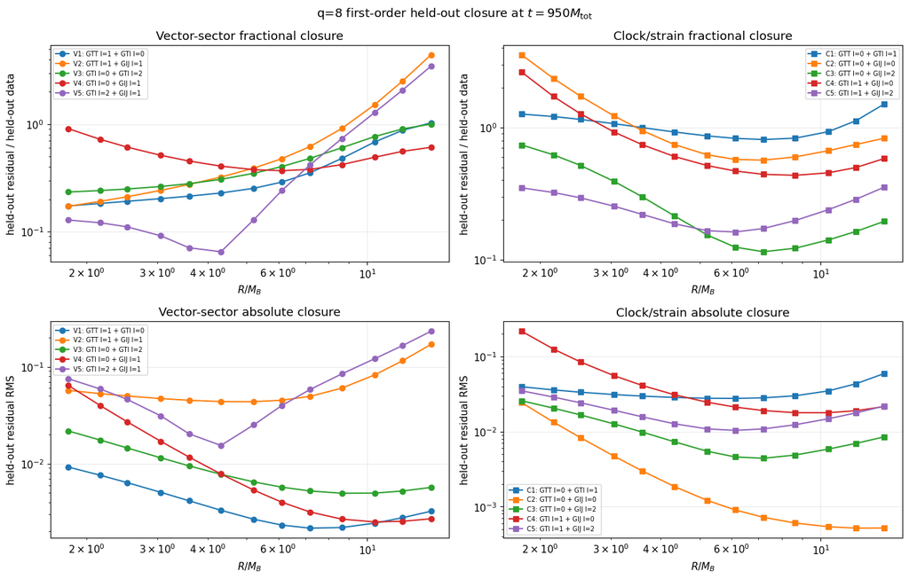

```python
VECTOR_RESULTS = evaluate_estimators(
    VECTOR_PARAMETER_INDICES,
    VECTOR_BLOCKS,
    VECTOR_ESTIMATOR_BLOCKS,
)
CLOCK_STRAIN_RESULTS = evaluate_estimators(
    CLOCK_STRAIN_PARAMETER_INDICES,
    CLOCK_STRAIN_BLOCKS,
    CLOCK_STRAIN_ESTIMATOR_BLOCKS,
)

VECTOR_LABELS = tuple(
    f"V{index + 1}: {estimator_label(blocks)}"
    for index, blocks in enumerate(VECTOR_ESTIMATOR_BLOCKS)
)
CLOCK_STRAIN_LABELS = tuple(
    f"C{index + 1}: {estimator_label(blocks)}"
    for index, blocks in enumerate(
        CLOCK_STRAIN_ESTIMATOR_BLOCKS)
)

fig_closure, axes = plt.subplots(
    2, 2, figsize=(14.0, 9.0))
for estimator_index, label in enumerate(VECTOR_LABELS):
    axes[0, 0].loglog(
        RADIUS_OVER_SMALL_MASS,
        VECTOR_RESULTS["held_out_residuals"][
            estimator_index],
        "o-",
        label=label,
    )
    axes[1, 0].loglog(
        RADIUS_OVER_SMALL_MASS,
        VECTOR_RESULTS["held_out_rms"][
            estimator_index],
        "o-",
        label=label,
    )
for estimator_index, label in enumerate(
        CLOCK_STRAIN_LABELS):
    axes[0, 1].loglog(
        RADIUS_OVER_SMALL_MASS,
        CLOCK_STRAIN_RESULTS["held_out_residuals"][
            estimator_index],
        "s-",
        label=label,
    )
    axes[1, 1].loglog(
        RADIUS_OVER_SMALL_MASS,
        CLOCK_STRAIN_RESULTS["held_out_rms"][
            estimator_index],
        "s-",
        label=label,
    )

axes[0, 0].set_title("Vector-sector fractional closure")
axes[0, 1].set_title("Clock/strain fractional closure")
axes[1, 0].set_title("Vector-sector absolute closure")
axes[1, 1].set_title("Clock/strain absolute closure")
for axis in axes[0]:
    axis.set_ylabel("held-out residual / held-out data")
for axis in axes[1]:
    axis.set_ylabel("held-out residual RMS")
for axis in axes.flat:
    axis.set_xlabel(r"$R/M_B$")
    axis.legend(fontsize=7)
fig_closure.suptitle(
    rf"q=8 first-order held-out closure at "
    rf"$t={TEST_TIME:g}M_{{\rm tot}}$")
fig_closure.tight_layout()
fig_closure.savefig(
    OUTPUT_DIRECTORY / "q8_t950_first_order_closure.pdf")
plt.show()
```

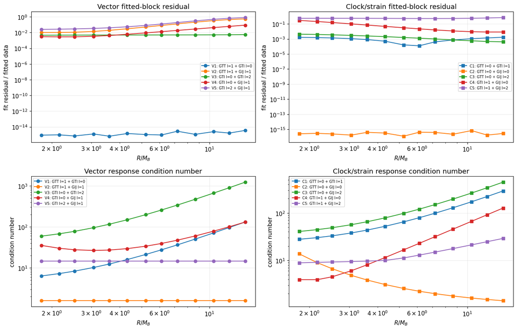

```python
fig_fit_quality, axes = plt.subplots(
    2, 2, figsize=(14.0, 9.0))
for estimator_index, label in enumerate(VECTOR_LABELS):
    axes[0, 0].loglog(
        RADIUS_OVER_SMALL_MASS,
        VECTOR_RESULTS["fitted_block_residuals"][
            estimator_index],
        "o-",
        label=label,
    )
    axes[1, 0].loglog(
        RADIUS_OVER_SMALL_MASS,
        VECTOR_RESULTS["condition_numbers"][
            estimator_index],
        "o-",
        label=label,
    )
for estimator_index, label in enumerate(
        CLOCK_STRAIN_LABELS):
    axes[0, 1].loglog(
        RADIUS_OVER_SMALL_MASS,
        CLOCK_STRAIN_RESULTS["fitted_block_residuals"][
            estimator_index],
        "s-",
        label=label,
    )
    axes[1, 1].loglog(
        RADIUS_OVER_SMALL_MASS,
        CLOCK_STRAIN_RESULTS["condition_numbers"][
            estimator_index],
        "s-",
        label=label,
    )
axes[0, 0].set_title("Vector fitted-block residual")
axes[0, 1].set_title("Clock/strain fitted-block residual")
axes[1, 0].set_title("Vector response condition number")
axes[1, 1].set_title("Clock/strain response condition number")
for axis in axes[0]:
    axis.set_ylabel("fit residual / fitted data")
for axis in axes[1]:
    axis.set_ylabel("condition number")
for axis in axes.flat:
    axis.set_xlabel(r"$R/M_B$")
    axis.legend(fontsize=7)
fig_fit_quality.tight_layout()
fig_fit_quality.savefig(
    OUTPUT_DIRECTORY / "q8_t950_first_order_fit_quality.pdf")
plt.show()
```

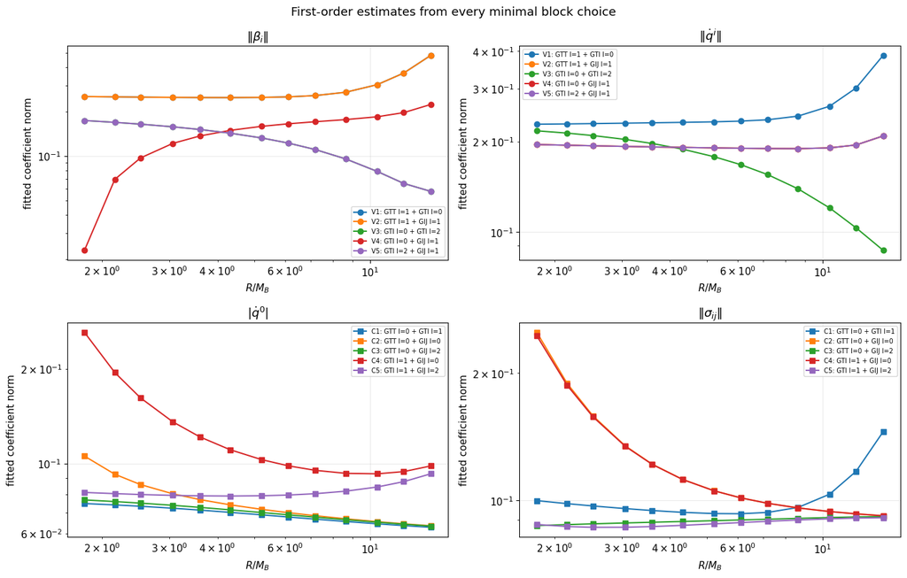

```python
fig_parameters, axes = plt.subplots(
    2, 2, figsize=(14.0, 9.0))

for estimator_index, label in enumerate(VECTOR_LABELS):
    estimates = VECTOR_RESULTS["estimates"][estimator_index]
    axes[0, 0].loglog(
        RADIUS_OVER_SMALL_MASS,
        np.linalg.norm(estimates[:, :3], axis=1),
        "o-",
        label=label,
    )
    axes[0, 1].loglog(
        RADIUS_OVER_SMALL_MASS,
        np.linalg.norm(estimates[:, 3:6], axis=1),
        "o-",
        label=label,
    )

for estimator_index, label in enumerate(
        CLOCK_STRAIN_LABELS):
    estimates = CLOCK_STRAIN_RESULTS["estimates"][
        estimator_index]
    axes[1, 0].loglog(
        RADIUS_OVER_SMALL_MASS,
        np.abs(estimates[:, 0]),
        "s-",
        label=label,
    )
    axes[1, 1].loglog(
        RADIUS_OVER_SMALL_MASS,
        np.linalg.norm(estimates[:, 1:], axis=1),
        "s-",
        label=label,
    )

axes[0, 0].set_title(r"$\|\beta_i\|$")
axes[0, 1].set_title(r"$\|\dot q^i\|$")
axes[1, 0].set_title(r"$|\dot q^0|$")
axes[1, 1].set_title(r"$\|\sigma_{ij}\|$")
for axis in axes.flat:
    axis.set_xlabel(r"$R/M_B$")
    axis.set_ylabel("fitted coefficient norm")
    axis.legend(fontsize=7)
fig_parameters.suptitle(
    "First-order estimates from every minimal block choice")
fig_parameters.tight_layout()
fig_parameters.savefig(
    OUTPUT_DIRECTORY / "q8_t950_first_order_parameters.pdf")
plt.show()
```

## 6. Out-of-sample inverse-metric reconstruction

Surface closure is an intermediate test. The quantity ultimately needed by the worldtube scheme is the metric extrapolated into the excised region. We therefore draw one fixed set of random validation points strictly inside the smallest fitting sphere, $R=0.2M_{\rm tot}$. The numerical domain is excised at smaller radii, so the validation points occupy three volume-uniform shells,

$$ 0.105 \leq \rho < 0.135,\qquad 0.135 \leq \rho < 0.165,\qquad 0.165 \leq \rho < 0.195, $$

with 256 points per shell. None of these 768 points participates in a surface fit.

Every vector estimator is combined with every clock/strain estimator. This gives 25 complete first-order parameter vectors at each fitting radius. For each one we evaluate

$$ E_{\rm total} =\frac{\lVert G_{\rm numerical}-G_{\rm model}\rVert_2} {\lVert G_{\rm numerical}\rVert_2}, \qquad E_{\rm pert} =\frac{\lVert G_{\rm numerical}-G_{\rm model}\rVert_2} {\lVert G_{\rm numerical}-G_{(0)}\rVert_2}. $$

Here $G_{(0)}$ is harmonic Schwarzschild. The first normalization measures the error in the full inverse metric. The second asks what fraction of the non-Schwarzschild content remains. The norm contains all ten independent inverse-metric components at all validation points.

```python
INTERIOR_RADIAL_EDGES = np.array([
    0.105, 0.135, 0.165, 0.195,
])
INTERIOR_POINTS_PER_SHELL = 256
INTERIOR_RANDOM_SEED = 20260728
interior_rng = np.random.default_rng(INTERIOR_RANDOM_SEED)

interior_local_points = []
interior_shell_indices = []
for shell_index, (inner_radius, outer_radius) in enumerate(zip(
        INTERIOR_RADIAL_EDGES[:-1],
        INTERIOR_RADIAL_EDGES[1:])):
    directions = interior_rng.normal(
        size=(INTERIOR_POINTS_PER_SHELL, 3))
    directions /= np.linalg.norm(
        directions, axis=1)[:, None]
    radii = (
        inner_radius**3
        + interior_rng.random(INTERIOR_POINTS_PER_SHELL)
        * (outer_radius**3 - inner_radius**3)
    ) ** (1.0 / 3.0)
    interior_local_points.append(
        radii[:, None] * directions)
    interior_shell_indices.append(np.full(
        INTERIOR_POINTS_PER_SHELL,
        shell_index,
        dtype=int,
    ))

INTERIOR_LOCAL_POINTS = np.concatenate(
    interior_local_points)
INTERIOR_SHELL_INDEX = np.concatenate(
    interior_shell_indices)
INTERIOR_RADII = np.linalg.norm(
    INTERIOR_LOCAL_POINTS, axis=1)
INTERIOR_INERTIAL_POINTS = (
    CURVATURE_CENTER[None, :] + INTERIOR_LOCAL_POINTS)

interior_raw_metric = interpolate_components(
    TEST_OBSERVATION_ID,
    INTERIOR_INERTIAL_POINTS,
    INVERSE_METRIC_COMPONENT_NAMES,
)
INTERIOR_NUMERICAL_METRIC = unpack_inverse_metric(
    interior_raw_metric)
INTERIOR_BACKGROUND_METRIC = inverse_harmonic_schwarzschild(
    INTERIOR_LOCAL_POINTS, SMALL_BLACK_HOLE_MASS)
INTERIOR_RESPONSE_COLUMNS = first_order_response_columns(
    INTERIOR_LOCAL_POINTS, SMALL_BLACK_HOLE_MASS)


def metric_values_by_point(metric):
    # Pack the ten independent components at every point.
    gtt, gti, gij = metric
    return np.column_stack([
        gtt,
        gti,
        *[gij[:, i, j] for i, j in SPATIAL_COMPONENTS],
    ])


INTERIOR_NUMERICAL_VALUES = metric_values_by_point(
    INTERIOR_NUMERICAL_METRIC)
INTERIOR_BACKGROUND_VALUES = metric_values_by_point(
    INTERIOR_BACKGROUND_METRIC)
INTERIOR_RESPONSE_DESIGN = np.stack([
    metric_values_by_point(column)
    for column in INTERIOR_RESPONSE_COLUMNS
], axis=-1)
INTERIOR_PERTURBATION_VALUES = (
    INTERIOR_NUMERICAL_VALUES
    - INTERIOR_BACKGROUND_VALUES)

number_of_vector_estimators = len(
    VECTOR_ESTIMATOR_BLOCKS)
number_of_clock_estimators = len(
    CLOCK_STRAIN_ESTIMATOR_BLOCKS)
number_of_radii = len(RADIUS_TEST_VALUES)
number_of_shells = len(INTERIOR_RADIAL_EDGES) - 1

INTERIOR_FIRST_ORDER_PARAMETERS = np.zeros((
    number_of_vector_estimators,
    number_of_clock_estimators,
    number_of_radii,
    len(FIRST_ORDER_PARAMETER_NAMES),
))
INTERIOR_TOTAL_ERROR = np.empty((
    number_of_vector_estimators,
    number_of_clock_estimators,
    number_of_radii,
))
INTERIOR_PERTURBATION_RESIDUAL = np.empty_like(
    INTERIOR_TOTAL_ERROR)
INTERIOR_SHELL_ERROR = np.empty((
    number_of_vector_estimators,
    number_of_clock_estimators,
    number_of_radii,
    number_of_shells,
))

numerical_norm = np.linalg.norm(
    INTERIOR_NUMERICAL_VALUES)
perturbation_norm = np.linalg.norm(
    INTERIOR_PERTURBATION_VALUES)
INTERIOR_ZEROTH_ORDER_ERROR = (
    perturbation_norm / numerical_norm)

for vector_index in range(number_of_vector_estimators):
    for clock_index in range(number_of_clock_estimators):
        for radius_index in range(number_of_radii):
            parameters = INTERIOR_FIRST_ORDER_PARAMETERS[
                vector_index, clock_index, radius_index]
            parameters[VECTOR_PARAMETER_INDICES] = (
                VECTOR_RESULTS["estimates"][
                    vector_index, radius_index])
            parameters[CLOCK_STRAIN_PARAMETER_INDICES] = (
                CLOCK_STRAIN_RESULTS["estimates"][
                    clock_index, radius_index])

            model_values = (
                INTERIOR_BACKGROUND_VALUES
                + np.einsum(
                    "ncp,p->nc",
                    INTERIOR_RESPONSE_DESIGN,
                    parameters,
                )
            )
            residual = (
                INTERIOR_NUMERICAL_VALUES - model_values)
            INTERIOR_TOTAL_ERROR[
                vector_index, clock_index, radius_index
            ] = np.linalg.norm(residual) / numerical_norm
            INTERIOR_PERTURBATION_RESIDUAL[
                vector_index, clock_index, radius_index
            ] = np.linalg.norm(residual) / perturbation_norm

            for shell_index in range(number_of_shells):
                in_shell = (
                    INTERIOR_SHELL_INDEX == shell_index)
                INTERIOR_SHELL_ERROR[
                    vector_index,
                    clock_index,
                    radius_index,
                    shell_index,
                ] = (
                    np.linalg.norm(residual[in_shell])
                    / np.linalg.norm(
                        INTERIOR_NUMERICAL_VALUES[in_shell])
                )

median_perturbation_by_pair = np.median(
    INTERIOR_PERTURBATION_RESIDUAL, axis=2)
SELECTED_INTERIOR_PAIR = np.unravel_index(
    np.argmin(median_perturbation_by_pair),
    median_perturbation_by_pair.shape,
)
selected_vector_index, selected_clock_index = (
    SELECTED_INTERIOR_PAIR)
selected_pair_errors = INTERIOR_TOTAL_ERROR[
    selected_vector_index, selected_clock_index]
SELECTED_INTERIOR_RADIUS_INDEX = int(np.argmin(
    selected_pair_errors))
GLOBAL_INTERIOR_MINIMUM_INDEX = np.unravel_index(
    np.argmin(INTERIOR_TOTAL_ERROR),
    INTERIOR_TOTAL_ERROR.shape,
)
(
    global_vector_index,
    global_clock_index,
    global_radius_index,
) = GLOBAL_INTERIOR_MINIMUM_INDEX

print(
    f"held-out interior points: {len(INTERIOR_LOCAL_POINTS)}")
print(
    "held-out radial range:",
    f"[{INTERIOR_RADII.min():.6f}, "
    f"{INTERIOR_RADII.max():.6f}] M_tot",
)
print(
    "zeroth-order total relative RMS:",
    f"{INTERIOR_ZEROTH_ORDER_ERROR:.6e}",
)
print(
    "lowest-median first-order pair:",
    f"V{selected_vector_index + 1} + "
    f"C{selected_clock_index + 1}",
)
print(
    "best total relative RMS for that pair:",
    f"{selected_pair_errors[SELECTED_INTERIOR_RADIUS_INDEX]:.6e}",
    "at R =",
    f"{RADIUS_TEST_VALUES[SELECTED_INTERIOR_RADIUS_INDEX]:.3f} M_tot",
)
print(
    "smallest individual first-order RMS:",
    f"{INTERIOR_TOTAL_ERROR[GLOBAL_INTERIOR_MINIMUM_INDEX]:.6e}",
    "from",
    f"V{global_vector_index + 1} + C{global_clock_index + 1}",
    "at R =",
    f"{RADIUS_TEST_VALUES[global_radius_index]:.3f} M_tot",
)
```

```
held-out interior points: 768
held-out radial range: [0.105143, 0.194988] M_tot
zeroth-order total relative RMS: 2.213806e-01
lowest-median first-order pair: V1 + C5
best total relative RMS for that pair: 3.800160e-02 at R = 0.400 M_tot
smallest individual first-order RMS: 3.605541e-02 from V1 + C3 at R = 0.200 M_tot
```

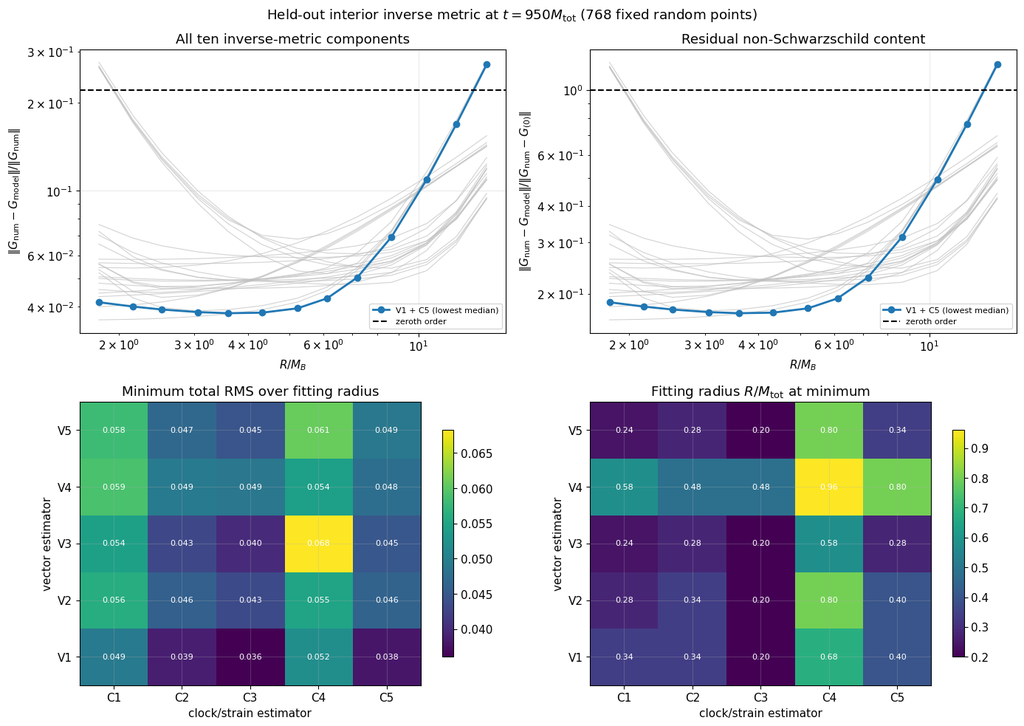

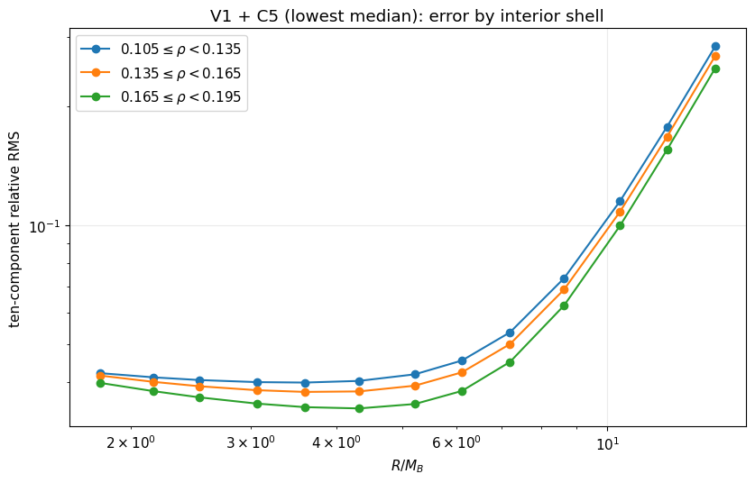

```python
fig_interior, axes = plt.subplots(
    2, 2, figsize=(14.0, 10.0))

all_total_errors = INTERIOR_TOTAL_ERROR.reshape(
    -1, number_of_radii)
all_perturbation_residuals = (
    INTERIOR_PERTURBATION_RESIDUAL.reshape(
        -1, number_of_radii))

for values in all_total_errors:
    axes[0, 0].loglog(
        RADIUS_OVER_SMALL_MASS,
        values,
        color="0.75",
        linewidth=0.8,
        alpha=0.7,
    )
for values in all_perturbation_residuals:
    axes[0, 1].loglog(
        RADIUS_OVER_SMALL_MASS,
        values,
        color="0.75",
        linewidth=0.8,
        alpha=0.7,
    )

selected_label = (
    f"V{selected_vector_index + 1} + "
    f"C{selected_clock_index + 1} "
    "(lowest median)")
axes[0, 0].loglog(
    RADIUS_OVER_SMALL_MASS,
    selected_pair_errors,
    "o-",
    linewidth=2.0,
    label=selected_label,
)
axes[0, 0].axhline(
    INTERIOR_ZEROTH_ORDER_ERROR,
    color="black",
    linestyle="--",
    label="zeroth order",
)
axes[0, 1].loglog(
    RADIUS_OVER_SMALL_MASS,
    INTERIOR_PERTURBATION_RESIDUAL[
        selected_vector_index, selected_clock_index],
    "o-",
    linewidth=2.0,
    label=selected_label,
)
axes[0, 1].axhline(
    1.0,
    color="black",
    linestyle="--",
    label="zeroth order",
)

axes[0, 0].set_title(
    "All ten inverse-metric components")
axes[0, 0].set_ylabel(
    r"$\|G_{\rm num}-G_{\rm model}\|/"
    r"\|G_{\rm num}\|$")
axes[0, 1].set_title(
    "Residual non-Schwarzschild content")
axes[0, 1].set_ylabel(
    r"$\|G_{\rm num}-G_{\rm model}\|/"
    r"\|G_{\rm num}-G_{(0)}\|$")
for axis in axes[0]:
    axis.set_xlabel(r"$R/M_B$")
    axis.legend(fontsize=8)

minimum_error_by_pair = np.min(
    INTERIOR_TOTAL_ERROR, axis=2)
best_radius_by_pair = RADIUS_TEST_VALUES[
    np.argmin(INTERIOR_TOTAL_ERROR, axis=2)]

image_error = axes[1, 0].imshow(
    minimum_error_by_pair,
    origin="lower",
    aspect="auto",
)
image_radius = axes[1, 1].imshow(
    best_radius_by_pair,
    origin="lower",
    aspect="auto",
)
for vector_index in range(number_of_vector_estimators):
    for clock_index in range(number_of_clock_estimators):
        axes[1, 0].text(
            clock_index,
            vector_index,
            f"{minimum_error_by_pair[vector_index, clock_index]:.3f}",
            ha="center",
            va="center",
            color="white",
            fontsize=8,
        )
        axes[1, 1].text(
            clock_index,
            vector_index,
            f"{best_radius_by_pair[vector_index, clock_index]:.2f}",
            ha="center",
            va="center",
            color="white",
            fontsize=8,
        )

for axis in axes[1]:
    axis.set_xticks(
        np.arange(number_of_clock_estimators),
        [f"C{index + 1}"
         for index in range(number_of_clock_estimators)],
    )
    axis.set_yticks(
        np.arange(number_of_vector_estimators),
        [f"V{index + 1}"
         for index in range(number_of_vector_estimators)],
    )
    axis.set_xlabel("clock/strain estimator")
    axis.set_ylabel("vector estimator")
axes[1, 0].set_title(
    "Minimum total RMS over fitting radius")
axes[1, 1].set_title(
    r"Fitting radius $R/M_{\rm tot}$ at minimum")
fig_interior.colorbar(
    image_error, ax=axes[1, 0], shrink=0.8)
fig_interior.colorbar(
    image_radius, ax=axes[1, 1], shrink=0.8)

fig_interior.suptitle(
    rf"Held-out interior inverse metric at "
    rf"$t={TEST_TIME:g}M_{{\rm tot}}$ "
    rf"({len(INTERIOR_LOCAL_POINTS)} fixed random points)")
fig_interior.tight_layout()
fig_interior.savefig(
    OUTPUT_DIRECTORY
    / "q8_t950_first_order_interior_residual.pdf")
plt.show()


fig_interior_shells, axis = plt.subplots(
    1, 1, figsize=(8.5, 5.5))
for shell_index, (inner_radius, outer_radius) in enumerate(zip(
        INTERIOR_RADIAL_EDGES[:-1],
        INTERIOR_RADIAL_EDGES[1:])):
    axis.loglog(
        RADIUS_OVER_SMALL_MASS,
        INTERIOR_SHELL_ERROR[
            selected_vector_index,
            selected_clock_index,
            :,
            shell_index,
        ],
        "o-",
        label=(
            fr"${inner_radius:.3f}\leq\rho"
            fr"<{outer_radius:.3f}$"
        ),
    )
axis.set_xlabel(r"$R/M_B$")
axis.set_ylabel("ten-component relative RMS")
axis.set_title(
    selected_label + ": error by interior shell")
axis.legend()
fig_interior_shells.tight_layout()
fig_interior_shells.savefig(
    OUTPUT_DIRECTORY
    / "q8_t950_first_order_interior_shells.pdf")
plt.show()
```

## 7. Radius-dependent first-order sensitivity

The response model is linear in all thirteen first-order parameters, so its Jacobian is exactly the set of response columns already used in the fit. No finite differencing is required.

We distinguish four quantities that are sometimes all called “sensitivity”:

1. **Raw surface response:** the RMS change in the worldtube metric per unit change in one parameter.
2. **Absolute identifiability:** the smallest singular value of a block or estimator response matrix. A small value means that some parameter combination produces little measurable surface signal.
3. **Empirical parameter ambiguity:** the spread among the 25 algebraically viable estimator pairs at the same radius.
4. **Interior impact:** the metric change on the fixed random validation points produced by that ambiguity.

For a fitted surface system $d_R=A_Rp+h_R$,

$$ \delta p=A_R^+h_R,\qquad \delta G_{\rm int}=J_{\rm int}A_R^+h_R. $$

We therefore also compute the operator norm of $J_{\rm int}A_R^+$. It measures how strongly unit RMS contamination in the selected surface blocks can be amplified into the held-out interior metric.

```python
number_of_parameters = len(FIRST_ORDER_PARAMETER_NAMES)

# Raw response strength on each fitting sphere.
SURFACE_PARAMETER_RESPONSE_RMS = np.empty((
    number_of_parameters, number_of_radii))
for radius_index, radius in enumerate(RADIUS_TEST_VALUES):
    surface_columns = first_order_response_columns(
        radius * DIRECTIONS, SMALL_BLACK_HOLE_MASS)
    for parameter_index, column in enumerate(surface_columns):
        values = metric_values_by_point(column)
        SURFACE_PARAMETER_RESPONSE_RMS[
            parameter_index, radius_index
        ] = np.linalg.norm(values) / np.sqrt(values.size)


# Absolute sensitivity of each individual STF block, restricted to the
# parameter directions to which that block responds.
BLOCK_SMALLEST_NONZERO_SINGULAR_VALUE = np.empty((
    len(FIRST_ORDER_BLOCKS), number_of_radii))
BLOCK_ACTIVE_PARAMETER_COUNT = np.empty(
    len(FIRST_ORDER_BLOCKS), dtype=int)
for block_index, block in enumerate(FIRST_ORDER_BLOCKS):
    representative_matrix = BLOCK_RESPONSE[block][0]
    column_norms = np.linalg.norm(
        representative_matrix, axis=0)
    active_parameters = np.flatnonzero(
        column_norms
        > 1.0e-12 * max(column_norms.max(), 1.0))
    BLOCK_ACTIVE_PARAMETER_COUNT[block_index] = len(
        active_parameters)
    for radius_index in range(number_of_radii):
        matrix = BLOCK_RESPONSE[block][radius_index][
            :, active_parameters]
        singular_values = np.linalg.svd(
            matrix, compute_uv=False)
        nonzero = singular_values[
            singular_values
            > 1.0e-10 * singular_values[0]]
        BLOCK_SMALLEST_NONZERO_SINGULAR_VALUE[
            block_index, radius_index
        ] = (
            nonzero[-1] / np.sqrt(matrix.shape[0])
            if len(nonzero) else 0.0
        )


def estimator_stability(
        parameter_indices, estimator_block_sets):
    smallest_singular_values = np.empty((
        len(estimator_block_sets), number_of_radii))
    interior_amplification = np.empty_like(
        smallest_singular_values)
    interior_design = INTERIOR_RESPONSE_DESIGN[
        :, :, parameter_indices].reshape(
            -1, len(parameter_indices))

    for estimator_index, selected_blocks in enumerate(
            estimator_block_sets):
        for radius_index in range(number_of_radii):
            matrix, _ = stacked_system(
                radius_index,
                parameter_indices,
                selected_blocks,
            )
            singular_values = np.linalg.svd(
                matrix, compute_uv=False)
            smallest_singular_values[
                estimator_index, radius_index
            ] = (
                singular_values[-1]
                / np.sqrt(matrix.shape[0])
            )
            # If the surface contamination has unit RMS, its Euclidean norm
            # is sqrt(number of fitted data).  Divide the predicted interior
            # norm by the numerical metric norm.
            interior_amplification[
                estimator_index, radius_index
            ] = (
                np.linalg.norm(
                    interior_design @ np.linalg.pinv(matrix),
                    ord=2,
                )
                * np.sqrt(matrix.shape[0])
                / numerical_norm
            )
    return smallest_singular_values, interior_amplification


(
    VECTOR_SMALLEST_SINGULAR_VALUE,
    VECTOR_INTERIOR_AMPLIFICATION,
) = estimator_stability(
    VECTOR_PARAMETER_INDICES,
    VECTOR_ESTIMATOR_BLOCKS,
)
(
    CLOCK_SMALLEST_SINGULAR_VALUE,
    CLOCK_INTERIOR_AMPLIFICATION,
) = estimator_stability(
    CLOCK_STRAIN_PARAMETER_INDICES,
    CLOCK_STRAIN_ESTIMATOR_BLOCKS,
)


# Empirical ambiguity among every algebraically viable complete first-order
# estimator pair.
PARAMETER_ENSEMBLE = INTERIOR_FIRST_ORDER_PARAMETERS.reshape(
    -1, number_of_radii, number_of_parameters)
PARAMETER_ENSEMBLE_MEAN = np.mean(
    PARAMETER_ENSEMBLE, axis=0)
PARAMETER_ENSEMBLE_SPREAD = np.std(
    PARAMETER_ENSEMBLE, axis=0)

interior_column_norm = np.array([
    np.linalg.norm(INTERIOR_RESPONSE_DESIGN[:, :, index])
    for index in range(number_of_parameters)
])
INTERIOR_PARAMETER_CONTRIBUTION = (
    np.abs(PARAMETER_ENSEMBLE_MEAN).T
    * interior_column_norm[:, None]
    / numerical_norm
)
INTERIOR_PARAMETER_UNCERTAINTY_IMPACT = (
    PARAMETER_ENSEMBLE_SPREAD.T
    * interior_column_norm[:, None]
    / numerical_norm
)

FIRST_ORDER_GROUPS = (
    ("clock rate", np.array([0])),
    ("boost", np.arange(1, 4)),
    ("velocity", np.arange(4, 7)),
    ("strain", np.arange(7, 13)),
)
INTERIOR_GROUP_PREDICTION_SPREAD = np.empty((
    len(FIRST_ORDER_GROUPS), number_of_radii))
INTERIOR_TOTAL_PREDICTION_SPREAD = np.empty(
    number_of_radii)

for radius_index in range(number_of_radii):
    parameter_deviation = (
        PARAMETER_ENSEMBLE[:, radius_index]
        - PARAMETER_ENSEMBLE_MEAN[radius_index])
    total_metric_deviation = np.einsum(
        "ncp,ep->enc",
        INTERIOR_RESPONSE_DESIGN,
        parameter_deviation,
    )
    INTERIOR_TOTAL_PREDICTION_SPREAD[radius_index] = (
        np.sqrt(np.mean(np.sum(
            total_metric_deviation**2, axis=(1, 2))))
        / numerical_norm
    )

    for group_index, (_, parameter_indices) in enumerate(
            FIRST_ORDER_GROUPS):
        group_metric_deviation = np.einsum(
            "ncg,eg->enc",
            INTERIOR_RESPONSE_DESIGN[
                :, :, parameter_indices],
            parameter_deviation[:, parameter_indices],
        )
        INTERIOR_GROUP_PREDICTION_SPREAD[
            group_index, radius_index
        ] = (
            np.sqrt(np.mean(np.sum(
                group_metric_deviation**2,
                axis=(1, 2),
            )))
            / numerical_norm
        )

print(
    "small-radius / minimum raw response ratio by parameter:")
minimum_radius_index = 0
for parameter_index, name in enumerate(
        FIRST_ORDER_PARAMETER_NAMES):
    values = SURFACE_PARAMETER_RESPONSE_RMS[
        parameter_index]
    print(
        f"  {name:10s}: "
        f"{values[minimum_radius_index] / values.min():.6e}"
    )

print("\nLargest individual uncertainty impact at each radius:")
for radius_index, radius in enumerate(RADIUS_TEST_VALUES):
    parameter_index = int(np.argmax(
        INTERIOR_PARAMETER_UNCERTAINTY_IMPACT[:, radius_index]))
    largest_impact = INTERIOR_PARAMETER_UNCERTAINTY_IMPACT[
        parameter_index, radius_index]
    print(
        f"  R={radius:.3f}: "
        f"{FIRST_ORDER_PARAMETER_NAMES[parameter_index]} "
        f"({largest_impact:.6e})"
    )
```

```
small-radius / minimum raw response ratio by parameter:
  qdot0     : 2.264191e+00
  beta_x    : 1.089575e+00
  beta_y    : 1.089575e+00
  beta_z    : 1.249196e+00
  qdot_x    : 2.329172e+00
  qdot_y    : 2.329172e+00
  qdot_z    : 2.357674e+00
  sigma_xx  : 1.021539e+00
  sigma_xy  : 1.040988e+00
  sigma_xz  : 1.084086e+00
  sigma_yy  : 1.021539e+00
  sigma_yz  : 1.084086e+00
  sigma_zz  : 1.205131e+00

Largest individual uncertainty impact at each radius:
  R=0.200: qdot0 (1.240523e-01)
  R=0.240: qdot0 (7.989055e-02)
  R=0.280: qdot0 (5.830394e-02)
  R=0.340: qdot0 (4.156417e-02)
  R=0.400: qdot0 (3.274709e-02)
  R=0.480: qdot0 (2.628922e-02)
  R=0.580: qdot0 (2.213411e-02)
  R=0.680: qdot_y (2.152254e-02)
  R=0.800: qdot_y (2.648449e-02)
  R=0.960: qdot_y (3.435613e-02)
  R=1.160: qdot_y (4.615705e-02)
  R=1.360: qdot_y (6.029013e-02)
  R=1.600: qdot_y (8.076037e-02)
```

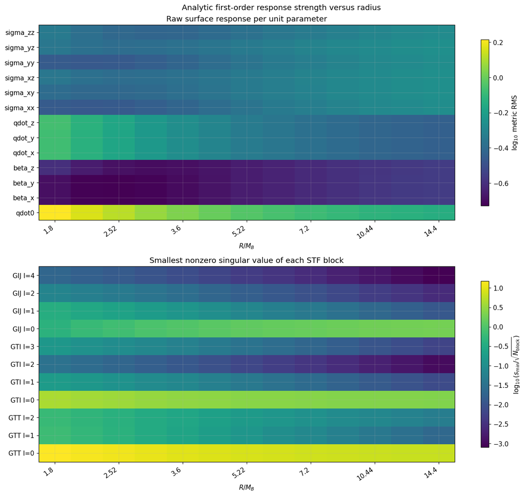

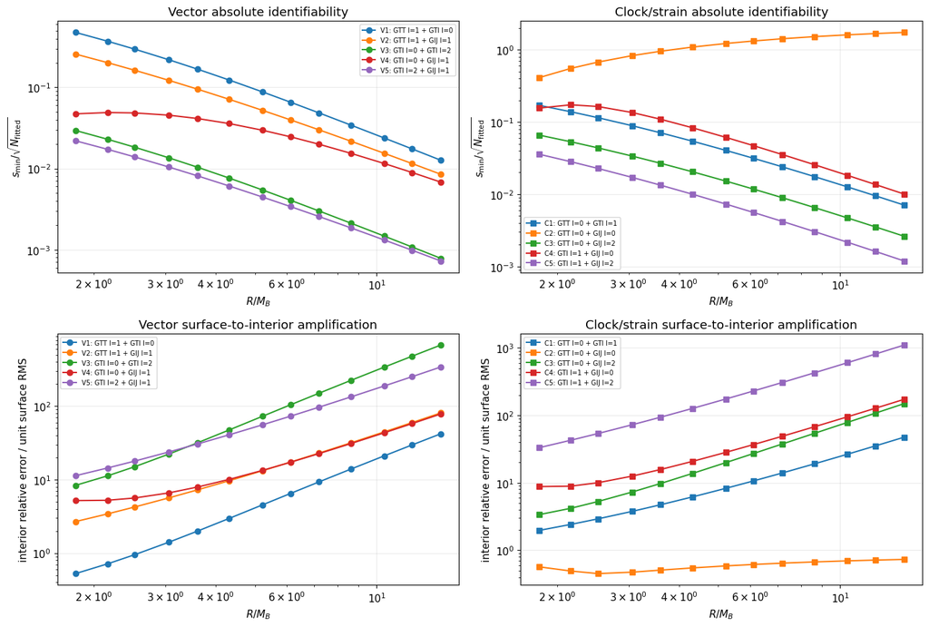

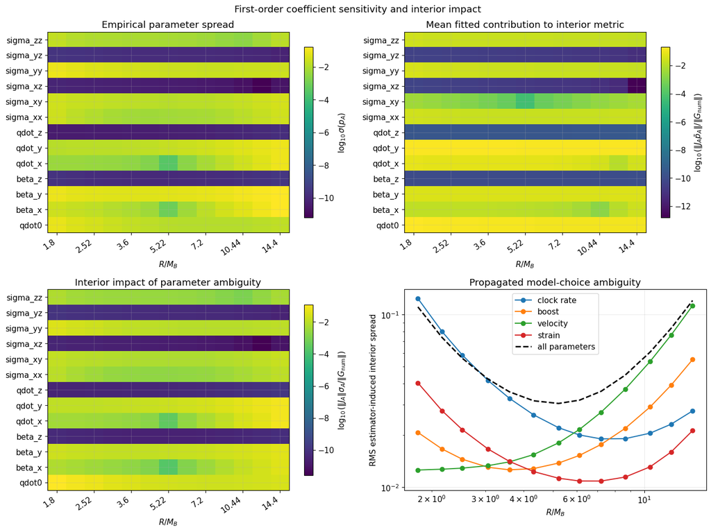

```python
def heatmap(
        axis, values, row_labels, title, colorbar_label,
        floor=1.0e-16):
    log_values = np.log10(np.maximum(values, floor))
    image = axis.imshow(
        log_values,
        origin="lower",
        aspect="auto",
    )
    axis.set_yticks(
        np.arange(len(row_labels)), row_labels)
    tick_indices = np.arange(
        0, number_of_radii, 2)
    axis.set_xticks(
        tick_indices,
        [f"{RADIUS_OVER_SMALL_MASS[index]:g}"
         for index in tick_indices],
        rotation=35,
        ha="right",
    )
    axis.set_xlabel(r"$R/M_B$")
    axis.set_title(title)
    colorbar = axis.figure.colorbar(
        image, ax=axis, shrink=0.85)
    colorbar.set_label(colorbar_label)
    return image


fig_response_sensitivity, axes = plt.subplots(
    2, 1, figsize=(13.5, 12.0))
heatmap(
    axes[0],
    SURFACE_PARAMETER_RESPONSE_RMS,
    FIRST_ORDER_PARAMETER_NAMES,
    "Raw surface response per unit parameter",
    r"$\log_{10}$ metric RMS",
)
heatmap(
    axes[1],
    BLOCK_SMALLEST_NONZERO_SINGULAR_VALUE,
    [block_name(block) for block in FIRST_ORDER_BLOCKS],
    "Smallest nonzero singular value of each STF block",
    r"$\log_{10}(s_{\min}/\sqrt{N_{\rm block}})$",
)
fig_response_sensitivity.suptitle(
    "Analytic first-order response strength versus radius")
fig_response_sensitivity.tight_layout()
fig_response_sensitivity.savefig(
    OUTPUT_DIRECTORY
    / "q8_t950_first_order_response_sensitivity.pdf")
plt.show()


fig_estimator_stability, axes = plt.subplots(
    2, 2, figsize=(14.0, 9.5))
for estimator_index, label in enumerate(VECTOR_LABELS):
    axes[0, 0].loglog(
        RADIUS_OVER_SMALL_MASS,
        VECTOR_SMALLEST_SINGULAR_VALUE[estimator_index],
        "o-",
        label=label,
    )
    axes[1, 0].loglog(
        RADIUS_OVER_SMALL_MASS,
        VECTOR_INTERIOR_AMPLIFICATION[estimator_index],
        "o-",
        label=label,
    )
for estimator_index, label in enumerate(
        CLOCK_STRAIN_LABELS):
    axes[0, 1].loglog(
        RADIUS_OVER_SMALL_MASS,
        CLOCK_SMALLEST_SINGULAR_VALUE[estimator_index],
        "s-",
        label=label,
    )
    axes[1, 1].loglog(
        RADIUS_OVER_SMALL_MASS,
        CLOCK_INTERIOR_AMPLIFICATION[estimator_index],
        "s-",
        label=label,
    )
axes[0, 0].set_title(
    "Vector absolute identifiability")
axes[0, 1].set_title(
    "Clock/strain absolute identifiability")
axes[1, 0].set_title(
    "Vector surface-to-interior amplification")
axes[1, 1].set_title(
    "Clock/strain surface-to-interior amplification")
for axis in axes[0]:
    axis.set_ylabel(
        r"$s_{\min}/\sqrt{N_{\rm fitted}}$")
for axis in axes[1]:
    axis.set_ylabel(
        "interior relative error / unit surface RMS")
for axis in axes.flat:
    axis.set_xlabel(r"$R/M_B$")
    axis.legend(fontsize=7)
fig_estimator_stability.tight_layout()
fig_estimator_stability.savefig(
    OUTPUT_DIRECTORY
    / "q8_t950_first_order_estimator_sensitivity.pdf")
plt.show()


fig_uncertainty, axes = plt.subplots(
    2, 2, figsize=(14.0, 10.5))
heatmap(
    axes[0, 0],
    PARAMETER_ENSEMBLE_SPREAD.T,
    FIRST_ORDER_PARAMETER_NAMES,
    "Empirical parameter spread",
    r"$\log_{10}\sigma(p_A)$",
)
heatmap(
    axes[0, 1],
    INTERIOR_PARAMETER_CONTRIBUTION,
    FIRST_ORDER_PARAMETER_NAMES,
    "Mean fitted contribution to interior metric",
    r"$\log_{10}(\|J_A\bar p_A\|/\|G_{\rm num}\|)$",
)
heatmap(
    axes[1, 0],
    INTERIOR_PARAMETER_UNCERTAINTY_IMPACT,
    FIRST_ORDER_PARAMETER_NAMES,
    "Interior impact of parameter ambiguity",
    r"$\log_{10}(\|J_A\|\sigma_A/\|G_{\rm num}\|)$",
)
for group_index, (group_name, _) in enumerate(
        FIRST_ORDER_GROUPS):
    axes[1, 1].loglog(
        RADIUS_OVER_SMALL_MASS,
        INTERIOR_GROUP_PREDICTION_SPREAD[group_index],
        "o-",
        label=group_name,
    )
axes[1, 1].loglog(
    RADIUS_OVER_SMALL_MASS,
    INTERIOR_TOTAL_PREDICTION_SPREAD,
    "k--",
    linewidth=2.0,
    label="all parameters",
)
axes[1, 1].set_xlabel(r"$R/M_B$")
axes[1, 1].set_ylabel(
    "RMS estimator-induced interior spread")
axes[1, 1].set_title(
    "Propagated model-choice ambiguity")
axes[1, 1].legend()
fig_uncertainty.suptitle(
    "First-order coefficient sensitivity and interior impact")
fig_uncertainty.tight_layout()
fig_uncertainty.savefig(
    OUTPUT_DIRECTORY
    / "q8_t950_first_order_uncertainty_propagation.pdf")
plt.show()
```

### Interpretation for choosing first-order blocks

The inward growth instead comes from disagreement among otherwise well-conditioned clock/strain fits. At $R=0.2M_{\rm tot}$ the inferred clock rates are

$$ \dot q^0=(0.0747,\ 0.1057,\ 0.0767,\ 0.2611,\ 0.0811) $$

for C1 through C5. C4 is the conspicuous outlier. The pairwise structure localizes the problem:

- C4 and C5 share $G^{Ti}_{1}$ but replace $G^{ij}_{0}$ by $G^{ij}_{2}$;
- C2 and C3 share $G^{TT}_{0}$ and make the same replacement.

Both comparisons point to systematic non-first-order content in $G^{ij}_{0}$ at small radius, rather than poor linear conditioning. This block retains an $O(1)$ strain response inward, so higher-order monopole content can be absorbed efficiently into the fitted trace strain and then feed back into the inferred clock rate.

For the present slice, the cleanest conservative hierarchy is therefore:

1. use V1, $G^{TT}_{1}+G^{Ti}_{0}$, for the vector sector; it has the largest small-radius singular value and the smallest interior amplification;
2. use C3, $G^{TT}_{0}+G^{ij}_{2}$, for the clock/strain sector;
3. use $G^{Ti}_{2}+G^{ij}_{1}$ as independent vector closure and $G^{Ti}_{1}$ as independent clock/strain closure;
4. retain $G^{ij}_{0}$ as a diagnostic absolute residual, but do not use it to determine the small-radius clock/strain parameters until its higher-order monopole content is modeled;
5. avoid interpreting a large *fractional* closure error in a block whose first-order response is radially weak. Plot its absolute residual alongside the fractional one.

This is a data-driven block choice for one slice, not yet a universal prescription. It should be checked on later q=8 slices and against the q=4 data before being promoted to the matching algorithm.

## 8. Provisional V1+C3 hierarchy

We now display the provisional hierarchy directly, without averaging it with the other estimators:

$$ \begin{aligned} \text{vector fit V1}:&\quad G^{TT}_{1}+G^{Ti}_{0}, \\ \text{clock/strain fit C3}:&\quad G^{TT}_{0}+G^{ij}_{2}. \end{aligned} $$

The primary independent closure blocks are

$$ G^{Ti}_{2}+G^{ij}_{1} \quad\text{and}\quad G^{Ti}_{1}. $$

The spatial monopole $G^{ij}_{0}$ is shown only through its absolute RMS residual. It is not included in the fitted system or in the recommended fractional closure score.

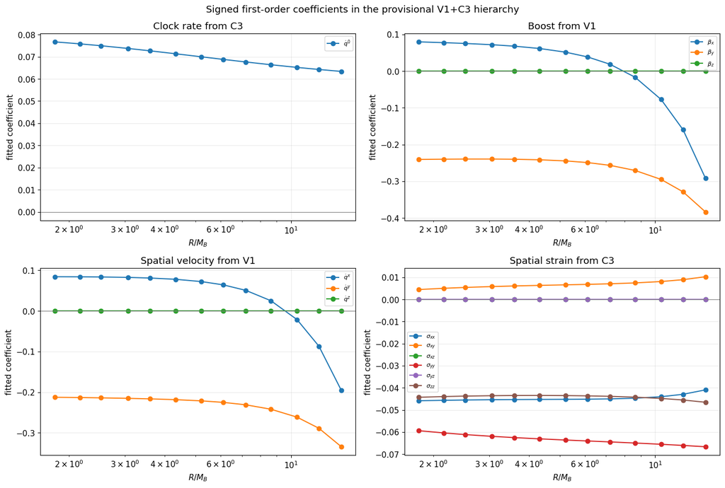

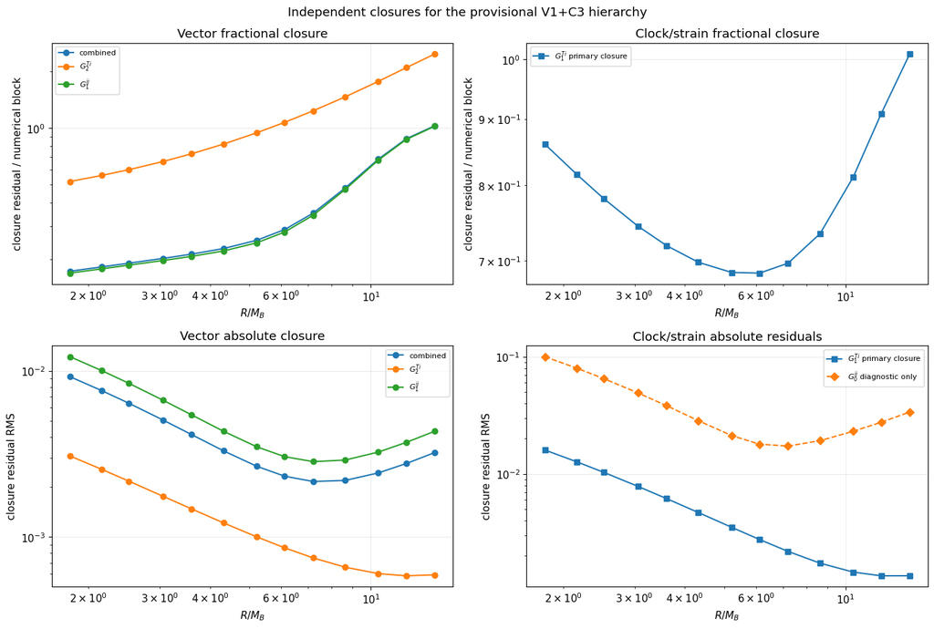

```
Provisional hierarchy closure minima
vector combined fractional      : 1.733107e-01 at R=0.200 M_tot
clock GTI l=1 fractional        : 6.848638e-01 at R=0.680 M_tot
GIJ l=0 diagnostic RMS          : 1.730381e-02 at R=0.800 M_tot
```

```python
PROVISIONAL_VECTOR_ESTIMATOR_INDEX = 0  # V1
PROVISIONAL_CLOCK_ESTIMATOR_INDEX = 2   # C3

PROVISIONAL_PARAMETERS = np.zeros((
    number_of_radii, number_of_parameters))
PROVISIONAL_PARAMETERS[:, VECTOR_PARAMETER_INDICES] = (
    VECTOR_RESULTS["estimates"][
        PROVISIONAL_VECTOR_ESTIMATOR_INDEX])
PROVISIONAL_PARAMETERS[
    :, CLOCK_STRAIN_PARAMETER_INDICES] = (
        CLOCK_STRAIN_RESULTS["estimates"][
            PROVISIONAL_CLOCK_ESTIMATOR_INDEX])


def provisional_closure(selected_blocks):
    fractional = np.empty(number_of_radii)
    absolute_rms = np.empty(number_of_radii)
    for radius_index in range(number_of_radii):
        data = np.concatenate([
            BLOCK_DATA[block][radius_index]
            for block in selected_blocks
        ])
        matrix = np.concatenate([
            BLOCK_RESPONSE[block][radius_index]
            for block in selected_blocks
        ], axis=0)
        residual = (
            data
            - matrix @ PROVISIONAL_PARAMETERS[radius_index])
        fractional[radius_index] = (
            np.linalg.norm(residual)
            / max(np.linalg.norm(data), 1.0e-300)
        )
        absolute_rms[radius_index] = (
            np.linalg.norm(residual)
            / np.sqrt(len(residual))
        )
    return fractional, absolute_rms


PROVISIONAL_VECTOR_CLOSURE_BLOCKS = (
    ("GTI", 2), ("GIJ", 1))
(
    PROVISIONAL_VECTOR_CLOSURE_FRACTION,
    PROVISIONAL_VECTOR_CLOSURE_RMS,
) = provisional_closure(
    PROVISIONAL_VECTOR_CLOSURE_BLOCKS)
(
    PROVISIONAL_GTI2_CLOSURE_FRACTION,
    PROVISIONAL_GTI2_CLOSURE_RMS,
) = provisional_closure((("GTI", 2),))
(
    PROVISIONAL_GIJ1_CLOSURE_FRACTION,
    PROVISIONAL_GIJ1_CLOSURE_RMS,
) = provisional_closure((("GIJ", 1),))
(
    PROVISIONAL_CLOCK_CLOSURE_FRACTION,
    PROVISIONAL_CLOCK_CLOSURE_RMS,
) = provisional_closure((("GTI", 1),))
(
    PROVISIONAL_GIJ0_DIAGNOSTIC_FRACTION,
    PROVISIONAL_GIJ0_DIAGNOSTIC_RMS,
) = provisional_closure((("GIJ", 0),))


fig_provisional_values, axes = plt.subplots(
    2, 2, figsize=(14.0, 9.5))

axes[0, 0].semilogx(
    RADIUS_OVER_SMALL_MASS,
    PROVISIONAL_PARAMETERS[:, 0],
    "o-",
    label=r"$\dot q^0$",
)
for component, label in enumerate(("x", "y", "z")):
    axes[0, 1].semilogx(
        RADIUS_OVER_SMALL_MASS,
        PROVISIONAL_PARAMETERS[:, 1 + component],
        "o-",
        label=fr"$\beta_{label}$",
    )
    axes[1, 0].semilogx(
        RADIUS_OVER_SMALL_MASS,
        PROVISIONAL_PARAMETERS[:, 4 + component],
        "o-",
        label=fr"$\dot q^{label}$",
    )

strain_labels = (
    r"$\sigma_{xx}$", r"$\sigma_{xy}$",
    r"$\sigma_{xz}$", r"$\sigma_{yy}$",
    r"$\sigma_{yz}$", r"$\sigma_{zz}$",
)
for component, label in enumerate(strain_labels):
    axes[1, 1].semilogx(
        RADIUS_OVER_SMALL_MASS,
        PROVISIONAL_PARAMETERS[:, 7 + component],
        "o-",
        label=label,
    )

axes[0, 0].set_title("Clock rate from C3")
axes[0, 1].set_title("Boost from V1")
axes[1, 0].set_title("Spatial velocity from V1")
axes[1, 1].set_title("Spatial strain from C3")
for axis in axes.flat:
    axis.axhline(0.0, color="0.5", linewidth=0.8)
    axis.set_xlabel(r"$R/M_B$")
    axis.set_ylabel("fitted coefficient")
    axis.legend(fontsize=8)
fig_provisional_values.suptitle(
    "Signed first-order coefficients in the provisional V1+C3 hierarchy")
fig_provisional_values.tight_layout()
fig_provisional_values.savefig(
    OUTPUT_DIRECTORY
    / "q8_t950_first_order_provisional_values.pdf")
plt.show()


fig_provisional_closure, axes = plt.subplots(
    2, 2, figsize=(14.0, 9.5))
vector_closure_curves = (
    (
        "combined",
        PROVISIONAL_VECTOR_CLOSURE_FRACTION,
        PROVISIONAL_VECTOR_CLOSURE_RMS,
    ),
    (
        r"$G^{Ti}_{2}$",
        PROVISIONAL_GTI2_CLOSURE_FRACTION,
        PROVISIONAL_GTI2_CLOSURE_RMS,
    ),
    (
        r"$G^{ij}_{1}$",
        PROVISIONAL_GIJ1_CLOSURE_FRACTION,
        PROVISIONAL_GIJ1_CLOSURE_RMS,
    ),
)
for label, fractional, absolute_rms in vector_closure_curves:
    axes[0, 0].loglog(
        RADIUS_OVER_SMALL_MASS,
        fractional,
        "o-",
        label=label,
    )
    axes[1, 0].loglog(
        RADIUS_OVER_SMALL_MASS,
        absolute_rms,
        "o-",
        label=label,
    )

axes[0, 1].loglog(
    RADIUS_OVER_SMALL_MASS,
    PROVISIONAL_CLOCK_CLOSURE_FRACTION,
    "s-",
    label=r"$G^{Ti}_{1}$ primary closure",
)
axes[1, 1].loglog(
    RADIUS_OVER_SMALL_MASS,
    PROVISIONAL_CLOCK_CLOSURE_RMS,
    "s-",
    label=r"$G^{Ti}_{1}$ primary closure",
)
axes[1, 1].loglog(
    RADIUS_OVER_SMALL_MASS,
    PROVISIONAL_GIJ0_DIAGNOSTIC_RMS,
    "D--",
    label=r"$G^{ij}_{0}$ diagnostic only",
)

axes[0, 0].set_title("Vector fractional closure")
axes[1, 0].set_title("Vector absolute closure")
axes[0, 1].set_title("Clock/strain fractional closure")
axes[1, 1].set_title(
    "Clock/strain absolute residuals")
for axis in axes[0]:
    axis.set_ylabel(
        "closure residual / numerical block")
for axis in axes[1]:
    axis.set_ylabel("closure residual RMS")
for axis in axes.flat:
    axis.set_xlabel(r"$R/M_B$")
    axis.legend(fontsize=8)
fig_provisional_closure.suptitle(
    "Independent closures for the provisional V1+C3 hierarchy")
fig_provisional_closure.tight_layout()
fig_provisional_closure.savefig(
    OUTPUT_DIRECTORY
    / "q8_t950_first_order_provisional_closure.pdf")
plt.show()


def print_provisional_minimum(name, values):
    minimum_index = int(np.argmin(values))
    print(
        f"{name:<32s}: {values[minimum_index]:.6e} "
        f"at R={RADIUS_TEST_VALUES[minimum_index]:.3f} M_tot"
    )


print("\nProvisional hierarchy closure minima")
print_provisional_minimum(
    "vector combined fractional",
    PROVISIONAL_VECTOR_CLOSURE_FRACTION,
)
print_provisional_minimum(
    "clock GTI l=1 fractional",
    PROVISIONAL_CLOCK_CLOSURE_FRACTION,
)
print_provisional_minimum(
    "GIJ l=0 diagnostic RMS",
    PROVISIONAL_GIJ0_DIAGNOSTIC_RMS,
)
```

### Reading the provisional curves

The fitted coefficients are smooth over the small and intermediate radii. The sharp drift in the boost and velocity components begins only at the larger radii, in the same region where their separating response blocks lose absolute sensitivity.

The closure plots also show why absolute and fractional residuals must be kept together:

- the combined vector fractional closure is smallest at the innermost sphere;
- the fractional $G^{Ti}_{2}$ error rises rapidly with radius even while its absolute residual decreases, because the numerical $\ell=2$ block itself is becoming small;
- the $G^{Ti}_{1}$ clock/strain fractional closure has a convex minimum, but its absolute residual decreases throughout the scan. Its large-radius fractional upturn is therefore predominantly loss of signal in the denominator, not growth of the mismatch;
- the absolute $G^{ij}_{0}$ diagnostic has a genuine convex shape and remains large at the smallest radii, consistent with the monopole-contamination diagnosis above.

Thus the most meaningful provisional closure is not one scalar fractional score. It is the collection of blockwise absolute residuals together with a fractional score only where the corresponding first-order block retains appreciable signal.

### Held-out interior metric for V1+C3

Finally, evaluate only the provisional hierarchy on the same 768 random points inside the smallest worldtube. These points were not used to choose or fit any surface block. We show the full ten-component error, the residual non-Schwarzschild content, the three validation shells, and the pointwise error distribution at the best V1+C3 fitting radius.

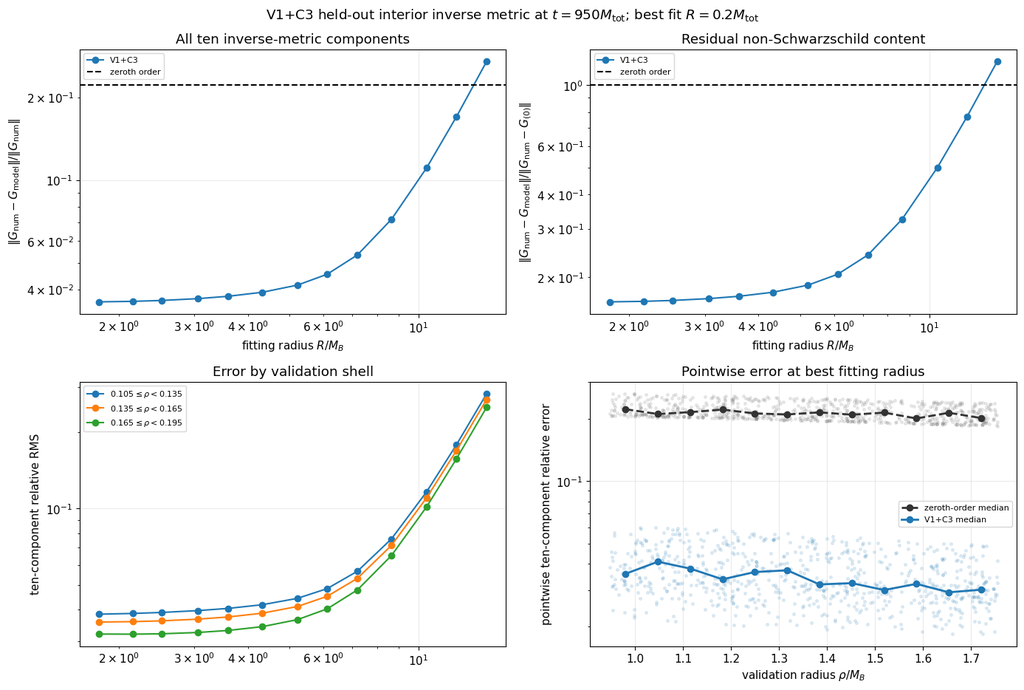

```
Provisional V1+C3 held-out interior minimum: 3.605541e-02 at R = 0.200 M_tot
improvement over zeroth order: 6.140x
```

```python
PROVISIONAL_INTERIOR_TOTAL_ERROR = INTERIOR_TOTAL_ERROR[
    PROVISIONAL_VECTOR_ESTIMATOR_INDEX,
    PROVISIONAL_CLOCK_ESTIMATOR_INDEX,
]
PROVISIONAL_INTERIOR_PERTURBATION_RESIDUAL = (
    INTERIOR_PERTURBATION_RESIDUAL[
        PROVISIONAL_VECTOR_ESTIMATOR_INDEX,
        PROVISIONAL_CLOCK_ESTIMATOR_INDEX,
    ]
)
PROVISIONAL_INTERIOR_SHELL_ERROR = INTERIOR_SHELL_ERROR[
    PROVISIONAL_VECTOR_ESTIMATOR_INDEX,
    PROVISIONAL_CLOCK_ESTIMATOR_INDEX,
]
PROVISIONAL_BEST_INTERIOR_RADIUS_INDEX = int(np.argmin(
    PROVISIONAL_INTERIOR_TOTAL_ERROR))
PROVISIONAL_BEST_INTERIOR_RADIUS = RADIUS_TEST_VALUES[
    PROVISIONAL_BEST_INTERIOR_RADIUS_INDEX]
PROVISIONAL_BEST_INTERIOR_ERROR = (
    PROVISIONAL_INTERIOR_TOTAL_ERROR[
        PROVISIONAL_BEST_INTERIOR_RADIUS_INDEX])
PROVISIONAL_INTERIOR_IMPROVEMENT = (
    INTERIOR_ZEROTH_ORDER_ERROR
    / PROVISIONAL_BEST_INTERIOR_ERROR)

provisional_best_model_values = (
    INTERIOR_BACKGROUND_VALUES
    + np.einsum(
        "ncp,p->nc",
        INTERIOR_RESPONSE_DESIGN,
        PROVISIONAL_PARAMETERS[
            PROVISIONAL_BEST_INTERIOR_RADIUS_INDEX],
    )
)
provisional_best_pointwise_residual = (
    INTERIOR_NUMERICAL_VALUES
    - provisional_best_model_values)
zeroth_pointwise_residual = (
    INTERIOR_NUMERICAL_VALUES
    - INTERIOR_BACKGROUND_VALUES)
pointwise_numerical_norm = np.linalg.norm(
    INTERIOR_NUMERICAL_VALUES, axis=1)
PROVISIONAL_POINTWISE_RELATIVE_ERROR = (
    np.linalg.norm(
        provisional_best_pointwise_residual, axis=1)
    / pointwise_numerical_norm
)
ZEROTH_POINTWISE_RELATIVE_ERROR = (
    np.linalg.norm(
        zeroth_pointwise_residual, axis=1)
    / pointwise_numerical_norm
)

pointwise_bin_edges = np.linspace(
    INTERIOR_RADII.min(),
    INTERIOR_RADII.max(),
    13,
)
pointwise_bin_centers = 0.5 * (
    pointwise_bin_edges[:-1] + pointwise_bin_edges[1:])
provisional_pointwise_median = np.full(
    len(pointwise_bin_centers), np.nan)
zeroth_pointwise_median = np.full(
    len(pointwise_bin_centers), np.nan)
for bin_index, (lower, upper) in enumerate(zip(
        pointwise_bin_edges[:-1],
        pointwise_bin_edges[1:])):
    in_bin = (
        (INTERIOR_RADII >= lower)
        & (INTERIOR_RADII < upper)
    )
    if np.any(in_bin):
        provisional_pointwise_median[bin_index] = np.median(
            PROVISIONAL_POINTWISE_RELATIVE_ERROR[in_bin])
        zeroth_pointwise_median[bin_index] = np.median(
            ZEROTH_POINTWISE_RELATIVE_ERROR[in_bin])


fig_provisional_interior, axes = plt.subplots(
    2, 2, figsize=(14.0, 9.5))

axes[0, 0].loglog(
    RADIUS_OVER_SMALL_MASS,
    PROVISIONAL_INTERIOR_TOTAL_ERROR,
    "o-",
    label="V1+C3",
)
axes[0, 0].axhline(
    INTERIOR_ZEROTH_ORDER_ERROR,
    color="black",
    linestyle="--",
    label="zeroth order",
)
axes[0, 0].set_title(
    "All ten inverse-metric components")
axes[0, 0].set_ylabel(
    r"$\|G_{\rm num}-G_{\rm model}\|/"
    r"\|G_{\rm num}\|$")

axes[0, 1].loglog(
    RADIUS_OVER_SMALL_MASS,
    PROVISIONAL_INTERIOR_PERTURBATION_RESIDUAL,
    "o-",
    label="V1+C3",
)
axes[0, 1].axhline(
    1.0,
    color="black",
    linestyle="--",
    label="zeroth order",
)
axes[0, 1].set_title(
    "Residual non-Schwarzschild content")
axes[0, 1].set_ylabel(
    r"$\|G_{\rm num}-G_{\rm model}\|/"
    r"\|G_{\rm num}-G_{(0)}\|$")

for shell_index, (inner_radius, outer_radius) in enumerate(zip(
        INTERIOR_RADIAL_EDGES[:-1],
        INTERIOR_RADIAL_EDGES[1:])):
    axes[1, 0].loglog(
        RADIUS_OVER_SMALL_MASS,
        PROVISIONAL_INTERIOR_SHELL_ERROR[:, shell_index],
        "o-",
        label=(
            fr"${inner_radius:.3f}\leq\rho"
            fr"<{outer_radius:.3f}$"
        ),
    )
axes[1, 0].set_title("Error by validation shell")
axes[1, 0].set_ylabel(
    "ten-component relative RMS")

axes[1, 1].scatter(
    INTERIOR_RADII / SMALL_BLACK_HOLE_MASS,
    ZEROTH_POINTWISE_RELATIVE_ERROR,
    s=7,
    alpha=0.12,
    color="0.4",
)
axes[1, 1].scatter(
    INTERIOR_RADII / SMALL_BLACK_HOLE_MASS,
    PROVISIONAL_POINTWISE_RELATIVE_ERROR,
    s=7,
    alpha=0.12,
    color="C0",
)
axes[1, 1].semilogy(
    pointwise_bin_centers / SMALL_BLACK_HOLE_MASS,
    zeroth_pointwise_median,
    "o--",
    color="0.2",
    linewidth=2.0,
    label="zeroth-order median",
)
axes[1, 1].semilogy(
    pointwise_bin_centers / SMALL_BLACK_HOLE_MASS,
    provisional_pointwise_median,
    "o-",
    color="C0",
    linewidth=2.0,
    label="V1+C3 median",
)
axes[1, 1].set_title(
    "Pointwise error at best fitting radius")
axes[1, 1].set_xlabel(r"validation radius $\rho/M_B$")
axes[1, 1].set_ylabel(
    "pointwise ten-component relative error")

for axis in axes[0]:
    axis.set_xlabel(r"fitting radius $R/M_B$")
for axis in axes[:, 0]:
    axis.legend(fontsize=8)
axes[0, 1].legend(fontsize=8)
axes[1, 1].legend(fontsize=8)

fig_provisional_interior.suptitle(
    rf"V1+C3 held-out interior inverse metric at "
    rf"$t={TEST_TIME:g}M_{{\rm tot}}$; "
    rf"best fit $R={PROVISIONAL_BEST_INTERIOR_RADIUS:g}"
    rf"M_{{\rm tot}}$")
fig_provisional_interior.tight_layout()
fig_provisional_interior.savefig(
    OUTPUT_DIRECTORY
    / "q8_t950_first_order_provisional_interior.pdf")
plt.show()

print(
    "\nProvisional V1+C3 held-out interior minimum:",
    f"{PROVISIONAL_BEST_INTERIOR_ERROR:.6e}",
    "at R =",
    f"{PROVISIONAL_BEST_INTERIOR_RADIUS:.3f} M_tot",
)
print(
    "improvement over zeroth order:",
    f"{PROVISIONAL_INTERIOR_IMPROVEMENT:.3f}x",
)
```

### Rendered V1+C3 interior-validation result

The preview below is stored beside this notebook, so it remains visible without rerunning the preceding cells.

[figure not shown]

## 9. Spatial radial derivative as a strictly held-out closure

The provisional V1+C3 parameters above were determined from values of the inverse metric only. We now test those same parameters against an independent observable,

$$ \mathcal D G^{ab} \equiv R n^i\partial_i G^{ab}. $$

No derivative data enter the fit. The evolved first-order reduction variable is

$$ \Phi_{iab}=\partial_i g_{ab}, $$

so the derivative of the inverse metric follows algebraically:

$$ \partial_iG^{ab} =-G^{ac}G^{bd}\Phi_{icd}. $$

The factor of (R) makes (\mathcal D) dimensionless and prevents a trivial overall (1/R) from dominating comparisons across the radius scan. We apply the same STF projections as for the metric values. The analytic Schwarzschild background and every first-order response column are differentiated along a fixed angular ray with a centered five-point stencil. This numerical differentiation acts only on smooth analytic functions; it does not finite-difference the simulation data.

Before using the result, we check the component ordering and inverse-metric identity by comparing the (\Phi)-based derivative with a centered radial finite difference of independently interpolated (G^{ab}). That check is a diagnostic only and does not enter either the fit or the closure.

```python
COVARIANT_COMPONENT_SUFFIXES = (
    "tt", "xt", "xx", "yt", "yx",
    "yy", "zt", "zx", "zy", "zz",
)
COVARIANT_DATA_COMPONENTS = (
    (0, 0), (0, 1), (1, 1), (0, 2), (1, 2),
    (2, 2), (0, 3), (1, 3), (2, 3), (3, 3),
)
PHI_COMPONENT_NAMES = tuple(
    f"Phi_{derivative}{suffix}"
    for derivative in ("x", "y", "z")
    for suffix in COVARIANT_COMPONENT_SUFFIXES
)


def inverse_metric_matrix(field_data):
    gtt, gti, gij = unpack_inverse_metric(field_data)
    matrix = np.zeros((len(gtt), 4, 4))
    matrix[:, 0, 0] = gtt
    matrix[:, 0, 1:] = gti
    matrix[:, 1:, 0] = gti
    matrix[:, 1:, 1:] = gij
    return matrix


def metric_tuple_from_matrix(matrix):
    return (
        matrix[:, 0, 0],
        matrix[:, 0, 1:],
        matrix[:, 1:, 1:],
    )


def interpolate_phi(observation_id, center, radii):
    points = np.concatenate([
        center[None, :] + radius * DIRECTIONS
        for radius in radii
    ])
    values = interpolate_components(
        observation_id, points, PHI_COMPONENT_NAMES)
    values = values.reshape(
        3,
        len(COVARIANT_DATA_COMPONENTS),
        len(radii),
        len(DIRECTIONS),
    )
    phi = np.zeros((
        len(radii), len(DIRECTIONS), 3, 4, 4))
    for derivative in range(3):
        for component_values, (a, b) in zip(
                values[derivative],
                COVARIANT_DATA_COMPONENTS):
            phi[:, :, derivative, a, b] = component_values
            phi[:, :, derivative, b, a] = component_values
    return phi


PHI_COVARIANT = interpolate_phi(
    TEST_OBSERVATION_ID,
    CURVATURE_CENTER,
    RADIUS_TEST_VALUES,
)
INVERSE_METRIC_MATRICES = np.asarray([
    inverse_metric_matrix(
        FIRST_ORDER_METRIC_DATA[:, radius_index])
    for radius_index in range(len(RADIUS_TEST_VALUES))
])

# d_i G^{ab} = -G^{ac} G^{bd} Phi_{icd}
INVERSE_METRIC_SPATIAL_DERIVATIVE = -np.einsum(
    "rpac,rpbd,rpicd->rpiab",
    INVERSE_METRIC_MATRICES,
    INVERSE_METRIC_MATRICES,
    PHI_COVARIANT,
)
NUMERICAL_RADIAL_DERIVATIVE = np.einsum(
    "pi,rpiab->rpab",
    DIRECTIONS,
    INVERSE_METRIC_SPATIAL_DERIVATIVE,
)


# Independent implementation check: finite-difference only the interpolated
# inverse metric, not the closure model.
PHI_CHECK_STEP = 2.0e-4
metric_plus = interpolate_inverse_metric(
    TEST_OBSERVATION_ID,
    CURVATURE_CENTER,
    RADIUS_TEST_VALUES + PHI_CHECK_STEP,
)
metric_minus = interpolate_inverse_metric(
    TEST_OBSERVATION_ID,
    CURVATURE_CENTER,
    RADIUS_TEST_VALUES - PHI_CHECK_STEP,
)
finite_difference_radial_derivative = np.asarray([
    (
        inverse_metric_matrix(metric_plus[:, radius_index])
        - inverse_metric_matrix(metric_minus[:, radius_index])
    ) / (2.0 * PHI_CHECK_STEP)
    for radius_index in range(len(RADIUS_TEST_VALUES))
])
PHI_FINITE_DIFFERENCE_RELATIVE_ERROR = np.asarray([
    np.linalg.norm(
        NUMERICAL_RADIAL_DERIVATIVE[radius_index]
        - finite_difference_radial_derivative[radius_index])
    / np.linalg.norm(
        finite_difference_radial_derivative[radius_index])
    for radius_index in range(len(RADIUS_TEST_VALUES))
])

print(
    "Phi-to-inverse radial derivative check:",
    f"min={PHI_FINITE_DIFFERENCE_RELATIVE_ERROR.min():.3e},",
    f"max={PHI_FINITE_DIFFERENCE_RELATIVE_ERROR.max():.3e}",
)
```

```
Phi-to-inverse radial derivative check: min=1.589e-08, max=9.077e-07
```

```python
def five_point_radial_derivative(
        metric_function, radius, relative_step=1.0e-4):
    step = relative_step * radius
    samples = [
        metric_function((radius + offset * step) * DIRECTIONS)
        for offset in (-2.0, -1.0, 1.0, 2.0)
    ]
    return tuple(
        (
            samples[0][component]
            - 8.0 * samples[1][component]
            + 8.0 * samples[2][component]
            - samples[3][component]
        ) / (12.0 * step)
        for component in range(3)
    )


def analytic_background_radial_derivative(
        radius, relative_step=1.0e-4):
    return five_point_radial_derivative(
        lambda points: inverse_harmonic_schwarzschild(
            points, SMALL_BLACK_HOLE_MASS),
        radius,
        relative_step,
    )


def analytic_response_radial_derivatives(
        radius, relative_step=1.0e-4):
    step = relative_step * radius
    samples = [
        first_order_response_columns(
            (radius + offset * step) * DIRECTIONS,
            SMALL_BLACK_HOLE_MASS,
        )
        for offset in (-2.0, -1.0, 1.0, 2.0)
    ]
    return tuple(
        tuple(
            (
                samples[0][parameter][component]
                - 8.0 * samples[1][parameter][component]
                + 8.0 * samples[2][parameter][component]
                - samples[3][parameter][component]
            ) / (12.0 * step)
            for component in range(3)
        )
        for parameter in range(len(FIRST_ORDER_PARAMETER_NAMES))
    )


DERIVATIVE_BLOCK_DATA = {
    block: [] for block in FIRST_ORDER_BLOCKS}
DERIVATIVE_BLOCK_RESPONSE = {
    block: [] for block in FIRST_ORDER_BLOCKS}
ANALYTIC_DERIVATIVE_STENCIL_ERROR = []

for radius_index, radius in enumerate(RADIUS_TEST_VALUES):
    numerical_derivative = metric_tuple_from_matrix(
        NUMERICAL_RADIAL_DERIVATIVE[radius_index])
    background_derivative = (
        analytic_background_radial_derivative(radius))
    response_derivatives = (
        analytic_response_radial_derivatives(radius))

    # Verify that halving the analytic stencil changes neither background nor
    # response derivatives appreciably.
    background_half_step = (
        analytic_background_radial_derivative(
            radius, relative_step=5.0e-5))
    response_half_step = (
        analytic_response_radial_derivatives(
            radius, relative_step=5.0e-5))
    full_step_values = np.concatenate([
        metric_values_by_point(background_derivative).ravel(),
        *[
            metric_values_by_point(column).ravel()
            for column in response_derivatives
        ],
    ])
    half_step_values = np.concatenate([
        metric_values_by_point(background_half_step).ravel(),
        *[
            metric_values_by_point(column).ravel()
            for column in response_half_step
        ],
    ])
    ANALYTIC_DERIVATIVE_STENCIL_ERROR.append(
        np.linalg.norm(full_step_values - half_step_values)
        / np.linalg.norm(half_step_values)
    )

    derivative_residual = tuple(
        radius * (numerical - background)
        for numerical, background in zip(
            numerical_derivative, background_derivative)
    )
    dimensionless_response_derivatives = tuple(
        tuple(radius * component for component in column)
        for column in response_derivatives
    )

    for block in FIRST_ORDER_BLOCKS:
        DERIVATIVE_BLOCK_DATA[block].append(
            metric_stf_block(*derivative_residual, block))
        DERIVATIVE_BLOCK_RESPONSE[block].append(
            np.column_stack([
                metric_stf_block(*response, block)
                for response in dimensionless_response_derivatives
            ])
        )

for block in FIRST_ORDER_BLOCKS:
    DERIVATIVE_BLOCK_DATA[block] = np.asarray(
        DERIVATIVE_BLOCK_DATA[block])
    DERIVATIVE_BLOCK_RESPONSE[block] = np.asarray(
        DERIVATIVE_BLOCK_RESPONSE[block])
ANALYTIC_DERIVATIVE_STENCIL_ERROR = np.asarray(
    ANALYTIC_DERIVATIVE_STENCIL_ERROR)

print(
    "analytic five-point stencil self-check:",
    f"max={ANALYTIC_DERIVATIVE_STENCIL_ERROR.max():.3e}",
)
```

```
analytic five-point stencil self-check: max=1.415e-11
```

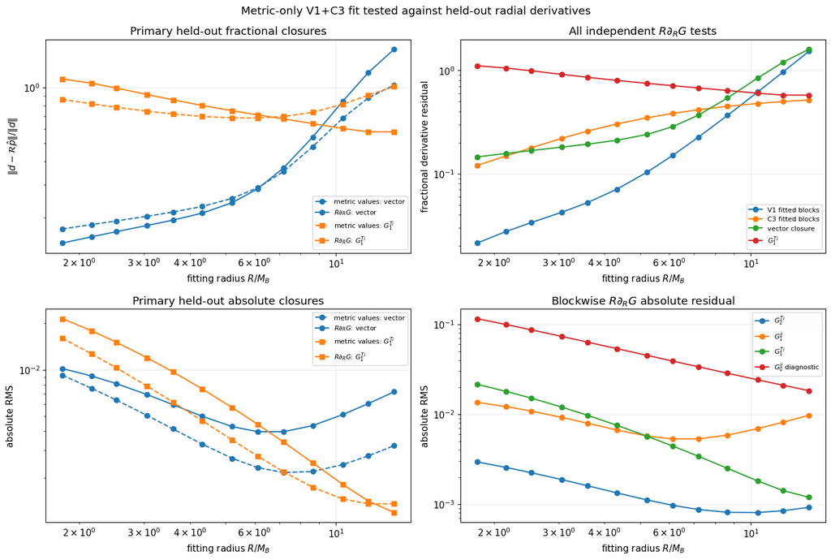

```
Held-out derivative minima
V1 fitted blocks             fraction=2.133082e-02, R=0.200, absolute RMS=1.264673e-02
C3 fitted blocks             fraction=1.206304e-01, R=0.200, absolute RMS=1.305296e-02
vector closure               fraction=1.455208e-01, R=0.200, absolute RMS=1.019039e-02
$G^{Ti}_{2}$                 fraction=3.551852e-01, R=0.200, absolute RMS=2.939265e-03
$G^{ij}_{1}$                 fraction=1.431980e-01, R=0.200, absolute RMS=1.353446e-02
$G^{Ti}_{1}$                 fraction=5.764012e-01, R=1.600, absolute RMS=1.187754e-03
$G^{ij}_{0}$ diagnostic      fraction=6.546228e-01, R=1.600, absolute RMS=1.826916e-02
```

```python
def closure_from_blocks(data_blocks, response_blocks, selected_blocks):
    fractional = np.empty(number_of_radii)
    absolute_rms = np.empty(number_of_radii)
    for radius_index in range(number_of_radii):
        data = np.concatenate([
            data_blocks[block][radius_index]
            for block in selected_blocks
        ])
        matrix = np.concatenate([
            response_blocks[block][radius_index]
            for block in selected_blocks
        ], axis=0)
        residual = (
            data
            - matrix @ PROVISIONAL_PARAMETERS[radius_index])
        fractional[radius_index] = (
            np.linalg.norm(residual)
            / max(np.linalg.norm(data), 1.0e-300)
        )
        absolute_rms[radius_index] = (
            np.linalg.norm(residual)
            / np.sqrt(len(residual))
        )
    return fractional, absolute_rms


DERIVATIVE_CLOSURES = {}
derivative_block_groups = {
    "V1 fitted blocks": (("GTT", 1), ("GTI", 0)),
    "C3 fitted blocks": (("GTT", 0), ("GIJ", 2)),
    "vector closure": (("GTI", 2), ("GIJ", 1)),
    r"$G^{Ti}_{2}$": (("GTI", 2),),
    r"$G^{ij}_{1}$": (("GIJ", 1),),
    r"$G^{Ti}_{1}$": (("GTI", 1),),
    r"$G^{ij}_{0}$ diagnostic": (("GIJ", 0),),
}
for label, blocks in derivative_block_groups.items():
    DERIVATIVE_CLOSURES[label] = closure_from_blocks(
        DERIVATIVE_BLOCK_DATA,
        DERIVATIVE_BLOCK_RESPONSE,
        blocks,
    )


fig_derivative, axes = plt.subplots(
    2, 2, figsize=(14.0, 9.5))

axes[0, 0].loglog(
    RADIUS_OVER_SMALL_MASS,
    PROVISIONAL_VECTOR_CLOSURE_FRACTION,
    "o--",
    color="C0",
    label="metric values: vector",
)
axes[0, 0].loglog(
    RADIUS_OVER_SMALL_MASS,
    DERIVATIVE_CLOSURES["vector closure"][0],
    "o-",
    color="C0",
    label=r"$R\partial_R G$: vector",
)
axes[0, 0].loglog(
    RADIUS_OVER_SMALL_MASS,
    PROVISIONAL_CLOCK_CLOSURE_FRACTION,
    "s--",
    color="C1",
    label=r"metric values: $G^{Ti}_{1}$",
)
axes[0, 0].loglog(
    RADIUS_OVER_SMALL_MASS,
    DERIVATIVE_CLOSURES[r"$G^{Ti}_{1}$"][0],
    "s-",
    color="C1",
    label=r"$R\partial_R G$: $G^{Ti}_{1}$",
)
axes[0, 0].set_title(
    "Primary held-out fractional closures")
axes[0, 0].set_ylabel(
    r"$\|d-\mathcal{R}\hat p\|/\|d\|$")

for label in (
        "V1 fitted blocks", "C3 fitted blocks",
        "vector closure", r"$G^{Ti}_{1}$"):
    axes[0, 1].loglog(
        RADIUS_OVER_SMALL_MASS,
        DERIVATIVE_CLOSURES[label][0],
        "o-",
        label=label,
    )
axes[0, 1].set_title(
    r"All independent $R\partial_R G$ tests")
axes[0, 1].set_ylabel("fractional derivative residual")

axes[1, 0].loglog(
    RADIUS_OVER_SMALL_MASS,
    PROVISIONAL_VECTOR_CLOSURE_RMS,
    "o--",
    color="C0",
    label="metric values: vector",
)
axes[1, 0].loglog(
    RADIUS_OVER_SMALL_MASS,
    DERIVATIVE_CLOSURES["vector closure"][1],
    "o-",
    color="C0",
    label=r"$R\partial_R G$: vector",
)
axes[1, 0].loglog(
    RADIUS_OVER_SMALL_MASS,
    PROVISIONAL_CLOCK_CLOSURE_RMS,
    "s--",
    color="C1",
    label=r"metric values: $G^{Ti}_{1}$",
)
axes[1, 0].loglog(
    RADIUS_OVER_SMALL_MASS,
    DERIVATIVE_CLOSURES[r"$G^{Ti}_{1}$"][1],
    "s-",
    color="C1",
    label=r"$R\partial_R G$: $G^{Ti}_{1}$",
)
axes[1, 0].set_title(
    "Primary held-out absolute closures")
axes[1, 0].set_ylabel("absolute RMS")

for label in (
        r"$G^{Ti}_{2}$", r"$G^{ij}_{1}$",
        r"$G^{Ti}_{1}$", r"$G^{ij}_{0}$ diagnostic"):
    axes[1, 1].loglog(
        RADIUS_OVER_SMALL_MASS,
        DERIVATIVE_CLOSURES[label][1],
        "o-",
        label=label,
    )
axes[1, 1].set_title(
    r"Blockwise $R\partial_R G$ absolute residual")
axes[1, 1].set_ylabel("absolute RMS")

for axis in axes.flat:
    axis.set_xlabel(r"fitting radius $R/M_B$")
    axis.legend(fontsize=8)
fig_derivative.suptitle(
    r"Metric-only V1+C3 fit tested against held-out radial derivatives")
fig_derivative.tight_layout()
fig_derivative.savefig(
    OUTPUT_DIRECTORY
    / "q8_t950_first_order_radial_derivative_closure.pdf")
fig_derivative.savefig(
    OUTPUT_DIRECTORY
    / "q8_t950_first_order_radial_derivative_closure.png",
    dpi=180,
)
plt.show()

print("\nHeld-out derivative minima")
for label, (fractional, absolute_rms) in (
        DERIVATIVE_CLOSURES.items()):
    best_index = int(np.argmin(fractional))
    print(
        f"{label:<28s} "
        f"fraction={fractional[best_index]:.6e}, "
        f"R={RADIUS_TEST_VALUES[best_index]:.3f}, "
        f"absolute RMS={absolute_rms[best_index]:.6e}"
    )
```

### How to read this test

The derivative curves are not additional fitting residuals. They answer the stronger question: do coefficients inferred from the metric values reproduce the radial variation of independent metric/STF blocks?

- The V1 and C3 curves test radial closure even in the blocks used for the value fit.
- The vector and (G^{Ti}_{1}) curves test blocks omitted from the fit in both component/STF structure and radial dependence.
- (G^{ij}_{0}) remains an absolute-only diagnostic because its small first-order signal makes a fractional score misleading.

Agreement of the (\Phi) and finite-difference derivatives is a prerequisite for interpreting these curves. A small analytic-stencil self-error only checks the differentiation of the exact response functions.

[figure not shown]

## 10. Joint value-and-radial-derivative fits

We now allow the derivative data to participate in the fit. For one sector and one fitting radius, the augmented system is

$$ \begin{pmatrix} \mathcal R_B\\ w_D\,R\partial_R\mathcal R_B \end{pmatrix} \widehat p \simeq \begin{pmatrix} d_B\\ w_D\,R\partial_Rd_B \end{pmatrix}. $$

Here (B) is exactly the block already used by the provisional hierarchy: V1 in the vector sector and C3 in the clock/strain sector. Thus this test adds radial information without adding a different component or STF projection. The unknowns remain the same six vector and seven clock/strain coefficients, so every nonzero (w_D) produces an overdetermined linear least-squares system.

The dimensionless weight (w_D) controls the relative influence of metric values and derivatives. We scan it rather than selecting it from the fitted residual. For every weight we retain as held-out validation:

- the value and derivative of (G^{Ti}*{2}+G^{ij}*{1}) in the vector sector;
- the value and derivative of (G^{Ti}_{1}) in the clock/strain sector;
- all random interior inverse-metric values.

Consequently, any improvement shown below cannot be obtained merely by driving the newly included derivative equations toward zero.

```python
JOINT_DERIVATIVE_WEIGHTS = np.array([
    0.0, 0.1, 0.3, 1.0, 3.0, 10.0,
])
JOINT_WEIGHT_LABELS = tuple(
    "metric only" if weight == 0.0
    else rf"$w_D={weight:g}$"
    for weight in JOINT_DERIVATIVE_WEIGHTS
)
JOINT_VECTOR_FIT_BLOCKS = (
    ("GTT", 1), ("GTI", 0))
JOINT_CLOCK_FIT_BLOCKS = (
    ("GTT", 0), ("GIJ", 2))


def stacked_block_system(
        data_blocks, response_blocks, blocks,
        radius_index, parameter_indices):
    data = np.concatenate([
        data_blocks[block][radius_index]
        for block in blocks
    ])
    matrix = np.concatenate([
        response_blocks[block][radius_index][
            :, parameter_indices]
        for block in blocks
    ], axis=0)
    return data, matrix


def solve_joint_sector(
        fit_blocks, parameter_indices, derivative_weight,
        radius_index):
    value_data, value_matrix = stacked_block_system(
        BLOCK_DATA,
        BLOCK_RESPONSE,
        fit_blocks,
        radius_index,
        parameter_indices,
    )
    derivative_data, derivative_matrix = stacked_block_system(
        DERIVATIVE_BLOCK_DATA,
        DERIVATIVE_BLOCK_RESPONSE,
        fit_blocks,
        radius_index,
        parameter_indices,
    )
    augmented_data = np.concatenate((
        value_data,
        derivative_weight * derivative_data,
    ))
    augmented_matrix = np.concatenate((
        value_matrix,
        derivative_weight * derivative_matrix,
    ), axis=0)
    estimate, _, rank, singular_values = np.linalg.lstsq(
        augmented_matrix, augmented_data, rcond=None)
    if rank != len(parameter_indices):
        raise RuntimeError(
            "Joint value/derivative system lost rank: "
            f"{rank} != {len(parameter_indices)}")
    condition_number = (
        singular_values[0] / singular_values[-1])
    return estimate, condition_number


JOINT_PARAMETERS = np.zeros((
    len(JOINT_DERIVATIVE_WEIGHTS),
    number_of_radii,
    number_of_parameters,
))
JOINT_VECTOR_CONDITION_NUMBER = np.zeros((
    len(JOINT_DERIVATIVE_WEIGHTS), number_of_radii))
JOINT_CLOCK_CONDITION_NUMBER = np.zeros_like(
    JOINT_VECTOR_CONDITION_NUMBER)

for weight_index, derivative_weight in enumerate(
        JOINT_DERIVATIVE_WEIGHTS):
    for radius_index in range(number_of_radii):
        (
            JOINT_PARAMETERS[
                weight_index,
                radius_index,
                VECTOR_PARAMETER_INDICES],
            JOINT_VECTOR_CONDITION_NUMBER[
                weight_index, radius_index],
        ) = solve_joint_sector(
            JOINT_VECTOR_FIT_BLOCKS,
            VECTOR_PARAMETER_INDICES,
            derivative_weight,
            radius_index,
        )
        (
            JOINT_PARAMETERS[
                weight_index,
                radius_index,
                CLOCK_STRAIN_PARAMETER_INDICES],
            JOINT_CLOCK_CONDITION_NUMBER[
                weight_index, radius_index],
        ) = solve_joint_sector(
            JOINT_CLOCK_FIT_BLOCKS,
            CLOCK_STRAIN_PARAMETER_INDICES,
            derivative_weight,
            radius_index,
        )

np.testing.assert_allclose(
    JOINT_PARAMETERS[0],
    PROVISIONAL_PARAMETERS,
    rtol=2.0e-12,
    atol=2.0e-13,
)
maximum_metric_only_difference = np.max(np.abs(
    JOINT_PARAMETERS[0] - PROVISIONAL_PARAMETERS))
print(
    "metric-only row reproduces V1+C3 to",
    f"{maximum_metric_only_difference:.3e}",
)
```

```
metric-only row reproduces V1+C3 to 9.356e-15
```

```python
def closure_for_parameter_grid(
        data_blocks, response_blocks, selected_blocks,
        parameter_grid):
    fractional = np.empty(parameter_grid.shape[:2])
    absolute_rms = np.empty(parameter_grid.shape[:2])
    for weight_index in range(parameter_grid.shape[0]):
        for radius_index in range(parameter_grid.shape[1]):
            data = np.concatenate([
                data_blocks[block][radius_index]
                for block in selected_blocks
            ])
            matrix = np.concatenate([
                response_blocks[block][radius_index]
                for block in selected_blocks
            ], axis=0)
            residual = (
                data
                - matrix @ parameter_grid[
                    weight_index, radius_index])
            fractional[weight_index, radius_index] = (
                np.linalg.norm(residual)
                / max(np.linalg.norm(data), 1.0e-300)
            )
            absolute_rms[weight_index, radius_index] = (
                np.linalg.norm(residual)
                / np.sqrt(len(residual))
            )
    return fractional, absolute_rms


(
    JOINT_VALUE_VECTOR_CLOSURE_FRACTION,
    JOINT_VALUE_VECTOR_CLOSURE_RMS,
) = closure_for_parameter_grid(
    BLOCK_DATA,
    BLOCK_RESPONSE,
    PROVISIONAL_VECTOR_CLOSURE_BLOCKS,
    JOINT_PARAMETERS,
)
(
    JOINT_DERIVATIVE_VECTOR_CLOSURE_FRACTION,
    JOINT_DERIVATIVE_VECTOR_CLOSURE_RMS,
) = closure_for_parameter_grid(
    DERIVATIVE_BLOCK_DATA,
    DERIVATIVE_BLOCK_RESPONSE,
    PROVISIONAL_VECTOR_CLOSURE_BLOCKS,
    JOINT_PARAMETERS,
)
(
    JOINT_VALUE_CLOCK_CLOSURE_FRACTION,
    JOINT_VALUE_CLOCK_CLOSURE_RMS,
) = closure_for_parameter_grid(
    BLOCK_DATA,
    BLOCK_RESPONSE,
    (("GTI", 1),),
    JOINT_PARAMETERS,
)
(
    JOINT_DERIVATIVE_CLOCK_CLOSURE_FRACTION,
    JOINT_DERIVATIVE_CLOCK_CLOSURE_RMS,
) = closure_for_parameter_grid(
    DERIVATIVE_BLOCK_DATA,
    DERIVATIVE_BLOCK_RESPONSE,
    (("GTI", 1),),
    JOINT_PARAMETERS,
)

JOINT_INTERIOR_TOTAL_ERROR = np.empty((
    len(JOINT_DERIVATIVE_WEIGHTS), number_of_radii))
JOINT_INTERIOR_PERTURBATION_RESIDUAL = np.empty_like(
    JOINT_INTERIOR_TOTAL_ERROR)
for weight_index in range(
        len(JOINT_DERIVATIVE_WEIGHTS)):
    for radius_index in range(number_of_radii):
        model_values = (
            INTERIOR_BACKGROUND_VALUES
            + np.einsum(
                "ncp,p->nc",
                INTERIOR_RESPONSE_DESIGN,
                JOINT_PARAMETERS[
                    weight_index, radius_index],
            )
        )
        residual = (
            INTERIOR_NUMERICAL_VALUES - model_values)
        JOINT_INTERIOR_TOTAL_ERROR[
            weight_index, radius_index] = (
                np.linalg.norm(residual)
                / np.linalg.norm(
                    INTERIOR_NUMERICAL_VALUES)
            )
        JOINT_INTERIOR_PERTURBATION_RESIDUAL[
            weight_index, radius_index] = (
                np.linalg.norm(residual)
                / np.linalg.norm(
                    INTERIOR_PERTURBATION_VALUES)
            )

np.testing.assert_allclose(
    JOINT_INTERIOR_TOTAL_ERROR[0],
    PROVISIONAL_INTERIOR_TOTAL_ERROR,
    rtol=2.0e-12,
    atol=2.0e-13,
)

metric_only_parameter_norm = np.linalg.norm(
    JOINT_PARAMETERS[0], axis=-1)
JOINT_PARAMETER_DISPLACEMENT = (
    np.linalg.norm(
        JOINT_PARAMETERS
        - JOINT_PARAMETERS[0][None, :, :],
        axis=-1,
    )
    / np.maximum(
        metric_only_parameter_norm[None, :],
        1.0e-300,
    )
)

# The two sectors are orthogonal, so they need not share a derivative weight.
# Assemble every vector-weight / clock-weight combination without refitting.
HYBRID_PARAMETERS = np.zeros((
    len(JOINT_DERIVATIVE_WEIGHTS),
    len(JOINT_DERIVATIVE_WEIGHTS),
    number_of_radii,
    number_of_parameters,
))
for vector_weight_index in range(
        len(JOINT_DERIVATIVE_WEIGHTS)):
    for clock_weight_index in range(
            len(JOINT_DERIVATIVE_WEIGHTS)):
        HYBRID_PARAMETERS[
            vector_weight_index,
            clock_weight_index,
            :,
            VECTOR_PARAMETER_INDICES,
        ] = JOINT_PARAMETERS[
            vector_weight_index,
            :,
            VECTOR_PARAMETER_INDICES,
        ]
        HYBRID_PARAMETERS[
            vector_weight_index,
            clock_weight_index,
            :,
            CLOCK_STRAIN_PARAMETER_INDICES,
        ] = JOINT_PARAMETERS[
            clock_weight_index,
            :,
            CLOCK_STRAIN_PARAMETER_INDICES,
        ]

HYBRID_INTERIOR_TOTAL_ERROR = np.empty((
    len(JOINT_DERIVATIVE_WEIGHTS),
    len(JOINT_DERIVATIVE_WEIGHTS),
    number_of_radii,
))
for vector_weight_index in range(
        len(JOINT_DERIVATIVE_WEIGHTS)):
    for clock_weight_index in range(
            len(JOINT_DERIVATIVE_WEIGHTS)):
        for radius_index in range(number_of_radii):
            model_values = (
                INTERIOR_BACKGROUND_VALUES
                + np.einsum(
                    "ncp,p->nc",
                    INTERIOR_RESPONSE_DESIGN,
                    HYBRID_PARAMETERS[
                        vector_weight_index,
                        clock_weight_index,
                        radius_index,
                    ],
                )
            )
            HYBRID_INTERIOR_TOTAL_ERROR[
                vector_weight_index,
                clock_weight_index,
                radius_index,
            ] = (
                np.linalg.norm(
                    INTERIOR_NUMERICAL_VALUES
                    - model_values)
                / np.linalg.norm(
                    INTERIOR_NUMERICAL_VALUES)
            )

HYBRID_MINIMUM_INTERIOR_ERROR = np.min(
    HYBRID_INTERIOR_TOTAL_ERROR, axis=-1)
HYBRID_MINIMUM_RADIUS_INDEX = np.argmin(
    HYBRID_INTERIOR_TOTAL_ERROR, axis=-1)
HYBRID_MINIMUM_RADIUS = RADIUS_TEST_VALUES[
    HYBRID_MINIMUM_RADIUS_INDEX]
HYBRID_GLOBAL_INDEX = np.unravel_index(
    np.argmin(HYBRID_INTERIOR_TOTAL_ERROR),
    HYBRID_INTERIOR_TOTAL_ERROR.shape,
)
```

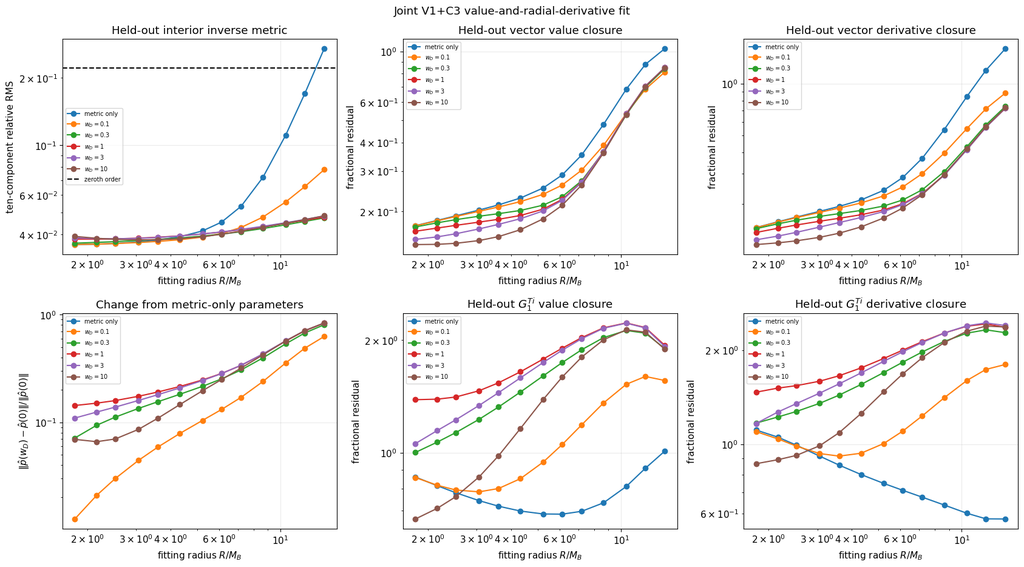

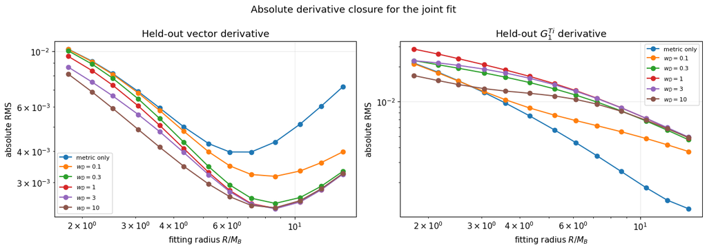

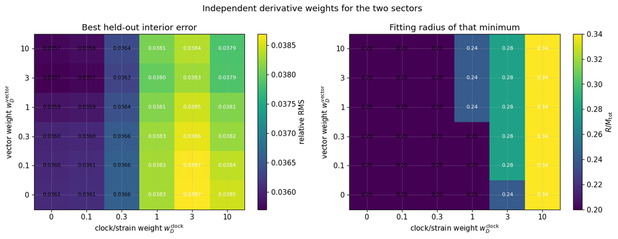

```python
fig_joint, axes = plt.subplots(
    2, 3, figsize=(17.0, 9.5))

for weight_index, label in enumerate(
        JOINT_WEIGHT_LABELS):
    axes[0, 0].loglog(
        RADIUS_OVER_SMALL_MASS,
        JOINT_INTERIOR_TOTAL_ERROR[weight_index],
        "o-",
        label=label,
    )
    axes[0, 1].loglog(
        RADIUS_OVER_SMALL_MASS,
        JOINT_VALUE_VECTOR_CLOSURE_FRACTION[
            weight_index],
        "o-",
        label=label,
    )
    axes[0, 2].loglog(
        RADIUS_OVER_SMALL_MASS,
        JOINT_DERIVATIVE_VECTOR_CLOSURE_FRACTION[
            weight_index],
        "o-",
        label=label,
    )
    axes[1, 0].loglog(
        RADIUS_OVER_SMALL_MASS,
        JOINT_PARAMETER_DISPLACEMENT[weight_index],
        "o-",
        label=label,
    )
    axes[1, 1].loglog(
        RADIUS_OVER_SMALL_MASS,
        JOINT_VALUE_CLOCK_CLOSURE_FRACTION[
            weight_index],
        "o-",
        label=label,
    )
    axes[1, 2].loglog(
        RADIUS_OVER_SMALL_MASS,
        JOINT_DERIVATIVE_CLOCK_CLOSURE_FRACTION[
            weight_index],
        "o-",
        label=label,
    )

axes[0, 0].axhline(
    INTERIOR_ZEROTH_ORDER_ERROR,
    color="black",
    linestyle="--",
    label="zeroth order",
)
axes[0, 0].set_title("Held-out interior inverse metric")
axes[0, 0].set_ylabel("ten-component relative RMS")
axes[0, 1].set_title(
    "Held-out vector value closure")
axes[0, 1].set_ylabel("fractional residual")
axes[0, 2].set_title(
    "Held-out vector derivative closure")
axes[0, 2].set_ylabel("fractional residual")
axes[1, 0].set_title(
    "Change from metric-only parameters")
axes[1, 0].set_ylabel(
    r"$\|\hat p(w_D)-\hat p(0)\|/\|\hat p(0)\|$")
axes[1, 1].set_title(
    r"Held-out $G^{Ti}_{1}$ value closure")
axes[1, 1].set_ylabel("fractional residual")
axes[1, 2].set_title(
    r"Held-out $G^{Ti}_{1}$ derivative closure")
axes[1, 2].set_ylabel("fractional residual")

for axis in axes.flat:
    axis.set_xlabel(r"fitting radius $R/M_B$")
    axis.legend(fontsize=7)
fig_joint.suptitle(
    "Joint V1+C3 value-and-radial-derivative fit")
fig_joint.tight_layout()
fig_joint.savefig(
    OUTPUT_DIRECTORY
    / "q8_t950_first_order_joint_derivative_fit.pdf")
fig_joint.savefig(
    OUTPUT_DIRECTORY
    / "q8_t950_first_order_joint_derivative_fit.png",
    dpi=180,
)
plt.show()


fig_joint_absolute, axes = plt.subplots(
    1, 2, figsize=(13.5, 4.8))
for weight_index, label in enumerate(
        JOINT_WEIGHT_LABELS):
    axes[0].loglog(
        RADIUS_OVER_SMALL_MASS,
        JOINT_DERIVATIVE_VECTOR_CLOSURE_RMS[
            weight_index],
        "o-",
        label=label,
    )
    axes[1].loglog(
        RADIUS_OVER_SMALL_MASS,
        JOINT_DERIVATIVE_CLOCK_CLOSURE_RMS[
            weight_index],
        "o-",
        label=label,
    )
axes[0].set_title(
    "Held-out vector derivative")
axes[1].set_title(
    r"Held-out $G^{Ti}_{1}$ derivative")
for axis in axes:
    axis.set_xlabel(r"fitting radius $R/M_B$")
    axis.set_ylabel("absolute RMS")
    axis.legend(fontsize=8)
fig_joint_absolute.suptitle(
    "Absolute derivative closure for the joint fit")
fig_joint_absolute.tight_layout()
fig_joint_absolute.savefig(
    OUTPUT_DIRECTORY
    / "q8_t950_first_order_joint_derivative_absolute.pdf")
fig_joint_absolute.savefig(
    OUTPUT_DIRECTORY
    / "q8_t950_first_order_joint_derivative_absolute.png",
    dpi=180,
)
plt.show()


fig_hybrid, axes = plt.subplots(
    1, 2, figsize=(13.5, 5.2))
weight_tick_labels = [
    f"{weight:g}" for weight in JOINT_DERIVATIVE_WEIGHTS]

image_error = axes[0].imshow(
    HYBRID_MINIMUM_INTERIOR_ERROR,
    origin="lower",
    aspect="auto",
)
axes[0].set_title(
    "Best held-out interior error")
axes[0].set_xlabel(r"clock/strain weight $w_D^{\rm clock}$")
axes[0].set_ylabel(r"vector weight $w_D^{\rm vector}$")
fig_hybrid.colorbar(
    image_error, ax=axes[0], label="relative RMS")

image_radius = axes[1].imshow(
    HYBRID_MINIMUM_RADIUS,
    origin="lower",
    aspect="auto",
)
axes[1].set_title(
    "Fitting radius of that minimum")
axes[1].set_xlabel(r"clock/strain weight $w_D^{\rm clock}$")
axes[1].set_ylabel(r"vector weight $w_D^{\rm vector}$")
fig_hybrid.colorbar(
    image_radius, ax=axes[1],
    label=r"$R/M_{\rm tot}$")

for axis in axes:
    axis.set_xticks(
        np.arange(len(JOINT_DERIVATIVE_WEIGHTS)),
        weight_tick_labels,
    )
    axis.set_yticks(
        np.arange(len(JOINT_DERIVATIVE_WEIGHTS)),
        weight_tick_labels,
    )
for row in range(len(JOINT_DERIVATIVE_WEIGHTS)):
    for column in range(len(JOINT_DERIVATIVE_WEIGHTS)):
        axes[0].text(
            column, row,
            f"{HYBRID_MINIMUM_INTERIOR_ERROR[row, column]:.4f}",
            ha="center", va="center",
            color="white"
            if HYBRID_MINIMUM_INTERIOR_ERROR[row, column]
            > np.median(HYBRID_MINIMUM_INTERIOR_ERROR)
            else "black",
            fontsize=8,
        )
        axes[1].text(
            column, row,
            f"{HYBRID_MINIMUM_RADIUS[row, column]:.2f}",
            ha="center", va="center",
            color="white"
            if HYBRID_MINIMUM_RADIUS[row, column]
            > np.median(HYBRID_MINIMUM_RADIUS)
            else "black",
            fontsize=8,
        )
fig_hybrid.suptitle(
    "Independent derivative weights for the two sectors")
fig_hybrid.tight_layout()
fig_hybrid.savefig(
    OUTPUT_DIRECTORY
    / "q8_t950_first_order_joint_derivative_hybrid.pdf")
fig_hybrid.savefig(
    OUTPUT_DIRECTORY
    / "q8_t950_first_order_joint_derivative_hybrid.png",
    dpi=180,
)
plt.show()
```

```python
print("\nJoint-fit validation summary")
for weight_index, (weight, label) in enumerate(zip(
        JOINT_DERIVATIVE_WEIGHTS,
        JOINT_WEIGHT_LABELS)):
    interior_index = int(np.argmin(
        JOINT_INTERIOR_TOTAL_ERROR[weight_index]))
    vector_value_index = int(np.argmin(
        JOINT_VALUE_VECTOR_CLOSURE_FRACTION[
            weight_index]))
    vector_derivative_index = int(np.argmin(
        JOINT_DERIVATIVE_VECTOR_CLOSURE_FRACTION[
            weight_index]))
    clock_value_index = int(np.argmin(
        JOINT_VALUE_CLOCK_CLOSURE_FRACTION[
            weight_index]))
    clock_derivative_index = int(np.argmin(
        JOINT_DERIVATIVE_CLOCK_CLOSURE_FRACTION[
            weight_index]))
    print(f"\n{label}")
    print(
        "  interior:",
        f"{JOINT_INTERIOR_TOTAL_ERROR[weight_index, interior_index]:.6e}",
        f"at R={RADIUS_TEST_VALUES[interior_index]:.3f}",
    )
    print(
        "  vector value / derivative:",
        f"{JOINT_VALUE_VECTOR_CLOSURE_FRACTION[weight_index, vector_value_index]:.6e}",
        "/",
        f"{JOINT_DERIVATIVE_VECTOR_CLOSURE_FRACTION[weight_index, vector_derivative_index]:.6e}",
    )
    print(
        "  clock value / derivative:",
        f"{JOINT_VALUE_CLOCK_CLOSURE_FRACTION[weight_index, clock_value_index]:.6e}",
        "/",
        f"{JOINT_DERIVATIVE_CLOCK_CLOSURE_FRACTION[weight_index, clock_derivative_index]:.6e}",
    )

(
    best_vector_weight_index,
    best_clock_weight_index,
    best_hybrid_radius_index,
) = HYBRID_GLOBAL_INDEX
print("\nBest sector-weight combination by held-out interior error")
print(
    "  vector weight:",
    JOINT_DERIVATIVE_WEIGHTS[
        best_vector_weight_index],
)
print(
    "  clock weight:",
    JOINT_DERIVATIVE_WEIGHTS[
        best_clock_weight_index],
)
print(
    "  fitting radius:",
    RADIUS_TEST_VALUES[
        best_hybrid_radius_index],
)
print(
    "  interior relative RMS:",
    HYBRID_INTERIOR_TOTAL_ERROR[
        HYBRID_GLOBAL_INDEX],
)
```

```
Joint-fit validation summary

metric only
  interior: 3.605541e-02 at R=0.200
  vector value / derivative: 1.733107e-01 / 1.455208e-01
  clock value / derivative: 6.848638e-01 / 5.764012e-01

$w_D=0.1$
  interior: 3.608317e-02 at R=0.200
  vector value / derivative: 1.729991e-01 / 1.452215e-01
  clock value / derivative: 7.857529e-01 / 9.155952e-01

$w_D=0.3$
  interior: 3.657499e-02 at R=0.200
  vector value / derivative: 1.710801e-01 / 1.433750e-01
  clock value / derivative: 1.001562e+00 / 1.167356e+00

$w_D=1$
  interior: 3.813857e-02 at R=0.240
  vector value / derivative: 1.638308e-01 / 1.363023e-01
  clock value / derivative: 1.385665e+00 / 1.465895e+00

$w_D=3$
  interior: 3.826849e-02 at R=0.280
  vector value / derivative: 1.509579e-01 / 1.234901e-01
  clock value / derivative: 1.057609e+00 / 1.163951e+00

$w_D=10$
  interior: 3.785095e-02 at R=0.340
  vector value / derivative: 1.432949e-01 / 1.158378e-01
  clock value / derivative: 6.648681e-01 / 8.657290e-01

Best sector-weight combination by held-out interior error
  vector weight: 3.0
  clock weight: 0.0
  fitting radius: 0.2
  interior relative RMS: 0.0356993263353011
```

### Interpretation of the weight scan

The derivative weight should not be chosen from the residual of the augmented V1+C3 equations, since increasing (w_D) directly changes that objective. The useful evidence is instead the behavior of blocks and interior points that never entered the joint fit.

A credible improvement would therefore have to satisfy several conditions at once:

1. reduce, or at least preserve, the held-out interior metric error;
2. improve derivative closure without destroying value closure;
3. remain stable over a range of nearby radii and nearby (w_D);
4. avoid a large displacement of the inferred parameters.

The two plots retain absolute derivative residuals alongside fractional closures, because a small fractional denominator can otherwise make a radially decaying block appear to become less accurate.

[figure not shown]

Because the vector and clock/strain systems are exactly orthogonal at first order, the final heat map also permits different (w_D) values in the two sectors. This distinguishes a failure of radial derivatives in general from a failure confined to one response block.

[figure not shown]

For this (t=950M_{\rm tot}) slice the distinction is clear. Increasing the vector derivative weight improves both omitted vector closures. In contrast, adding the C3 derivative generally moves the clock/strain parameters away from the omitted (G^{Ti}_{1}) value and derivative. The best entry in the finite scan therefore uses

$$ w_D^{\rm vector}=3,\qquad w_D^{\rm clock}=0, $$

at (R=0.2M_{\rm tot}). Its held-out interior error is (0.0356993), compared with (0.0360554) for the metric-only V1+C3 fit. The improvement is real but only about one percent, so this is evidence that the spatial derivative can modestly regularize the vector sector—not yet evidence for a universal optimal weight. On this slice the clock/strain derivative should remain a closure diagnostic rather than a fitted equation.

## 11. Controlled second-order start: the spatial 29-variable block

We now keep two first-order baselines in parallel:

1. metric-only V1+C3;
2. derivative-assisted V1 with (w_D^{\rm vector}=3), together with metric-only C3.

At every radius we construct the candidate second-order residual

$$ r_{(2)}^{ab} =G_{\rm num}^{ab} -G_{(0)}^{ab} -\mathcal R_{(1)}^{ab}\widehat p_{(1)} -Q_{11}^{ab}[\widehat p_{(1)},\widehat p_{(1)}]. $$

The known quadratic source used here is the audited (\beta^2+\beta\Lambda+\Lambda^2) contribution. It is evaluated with the baseline first-order time gradient (\beta_i) and symmetric spatial strain (\Lambda_{ij}). Since (\epsilon) is an order-counting device, its numerical value is one throughout this comparison.

We begin only with the 29-variable spatial block visible in (G^{ij}):

| group | number |
| --- | --- |
| spatial acceleration (\ddot q^i) | 3 |
| symmetric strain rate (\dot\Lambda_{(ij)}) | 6 |
| physical electric STF tensor (\mathcal E_{ij}) | 5 |
| spatial harmonic quadrupoles (Q^i{}_{\langle jk\rangle}) | 15 |

Two solves are compared:

- **frozen first order:** fit these 29 coefficients to (G^{ij});
- **first-order correction:** fit the same coefficients together with (\delta\dot q^i) and (\delta\Lambda_{ij}), the nine first-order corrections that are actually visible in (G^{ij}).

Thus the second solve implements

$$ r_{(2)}^{ij} \simeq \mathcal R_{(1)}^{ij}\delta p_{(1)} +\mathcal R_{(2),A}^{ij}p_{(2)}^A. $$

It is still a linear overdetermined problem. The correction is diagnostic: if it becomes large or destroys radius convergence, the apparent second-order coefficients are likely repairing an imperfect first-order baseline.

This section is deliberately not a full second-order reconstruction. The nine temporal-even and five magnetic coefficients are not yet fitted, so (G^{TT}) and (G^{Ti}) are not final closure blocks at this stage.

```python
SECOND_ORDER_BASELINE_NAMES = (
    "metric-only V1+C3",
    "derivative-assisted V1 + metric C3",
)
vector_weight_three_index = int(np.flatnonzero(
    np.isclose(JOINT_DERIVATIVE_WEIGHTS, 3.0))[0])
metric_only_weight_index = int(np.flatnonzero(
    np.isclose(JOINT_DERIVATIVE_WEIGHTS, 0.0))[0])
SECOND_ORDER_FIRST_ORDER_BASELINES = np.stack((
    PROVISIONAL_PARAMETERS,
    HYBRID_PARAMETERS[
        vector_weight_three_index,
        metric_only_weight_index,
    ],
))
SECOND_ORDER_SOLVE_NAMES = (
    "frozen first order",
    r"with $\delta p_{(1)}$",
)
VISIBLE_FIRST_ORDER_CORRECTION_INDICES = np.r_[
    np.arange(4, 7), np.arange(7, 13)]


def symmetric_matrix_from_six(values):
    matrix = np.zeros((3, 3))
    for value, (i, j) in zip(
            values, SPATIAL_COMPONENTS):
        matrix[i, j] = matrix[j, i] = value
    return matrix


def metric_linear_combination(columns, parameters):
    return tuple(
        sum(
            parameter * column[component]
            for parameter, column in zip(
                parameters, columns)
        )
        for component in range(3)
    )


def subtract_metric(left, *right_metrics):
    return tuple(
        left_component
        - sum(
            right[component]
            for right in right_metrics
        )
        for component, left_component in enumerate(left)
    )


def gij_values(metric):
    return np.column_stack([
        metric[2][:, i, j]
        for i, j in SPATIAL_COMPONENTS
    ]).ravel()


def scaled_least_squares(matrix, data):
    column_scales = np.linalg.norm(matrix, axis=0)
    if np.any(column_scales == 0.0):
        raise RuntimeError(
            "A fitted response column is identically zero")
    scaled_matrix = matrix / column_scales
    scaled_solution, _, rank, singular_values = (
        np.linalg.lstsq(
            scaled_matrix, data, rcond=1.0e-10)
    )
    solution = scaled_solution / column_scales
    condition_number = (
        singular_values[0] / singular_values[rank - 1])
    return solution, rank, condition_number


def response_design(columns, value_function):
    return np.column_stack([
        value_function(column) for column in columns
    ])


number_of_second_order_baselines = len(
    SECOND_ORDER_BASELINE_NAMES)
number_of_second_order_solves = len(
    SECOND_ORDER_SOLVE_NAMES)
number_of_stage1_parameters = len(
    STAGE1_PARAMETER_NAMES)

SURFACE_STAGE1_COLUMNS = []
SURFACE_STAGE1_GIJ_DESIGN = []
SURFACE_VISIBLE_FIRST_ORDER_GIJ_DESIGN = []
for radius in RADIUS_TEST_VALUES:
    points = radius * DIRECTIONS
    stage1_columns = stage1_response_columns_at_points(
        points, SMALL_BLACK_HOLE_MASS)
    first_order_columns = first_order_response_columns(
        points, SMALL_BLACK_HOLE_MASS)
    SURFACE_STAGE1_COLUMNS.append(stage1_columns)
    SURFACE_STAGE1_GIJ_DESIGN.append(
        response_design(stage1_columns, gij_values))
    SURFACE_VISIBLE_FIRST_ORDER_GIJ_DESIGN.append(
        response_design(
            tuple(
                first_order_columns[index]
                for index
                in VISIBLE_FIRST_ORDER_CORRECTION_INDICES
            ),
            gij_values,
        )
    )
```

```python
SECOND_ORDER_CANDIDATE_RESIDUALS = [
    [None for _ in RADIUS_TEST_VALUES]
    for _ in SECOND_ORDER_BASELINE_NAMES
]
SECOND_ORDER_FIRST_ORDER_RESIDUAL_FRACTION = np.empty((
    number_of_second_order_baselines, number_of_radii))
SECOND_ORDER_QUADRATIC_RESIDUAL_FRACTION = np.empty_like(
    SECOND_ORDER_FIRST_ORDER_RESIDUAL_FRACTION)
SECOND_ORDER_QUADRATIC_SOURCE_FRACTION = np.empty_like(
    SECOND_ORDER_FIRST_ORDER_RESIDUAL_FRACTION)
SECOND_ORDER_STAGE1_PARAMETERS = np.zeros((
    number_of_second_order_baselines,
    number_of_second_order_solves,
    number_of_radii,
    number_of_stage1_parameters,
))
SECOND_ORDER_FIRST_ORDER_CORRECTIONS = np.zeros((
    number_of_second_order_baselines,
    number_of_second_order_solves,
    number_of_radii,
    number_of_parameters,
))
SECOND_ORDER_STAGE1_GIJ_RESIDUAL = np.empty((
    number_of_second_order_baselines,
    number_of_second_order_solves,
    number_of_radii,
))
SECOND_ORDER_STAGE1_CONDITION_NUMBER = np.empty_like(
    SECOND_ORDER_STAGE1_GIJ_RESIDUAL)
SECOND_ORDER_STAGE1_RANK = np.empty(
    SECOND_ORDER_STAGE1_GIJ_RESIDUAL.shape,
    dtype=int,
)
SECOND_ORDER_FIRST_ORDER_CORRECTION_FRACTION = np.zeros_like(
    SECOND_ORDER_STAGE1_GIJ_RESIDUAL)

for baseline_index in range(
        number_of_second_order_baselines):
    for radius_index, radius in enumerate(
            RADIUS_TEST_VALUES):
        points = radius * DIRECTIONS
        parameters = (
            SECOND_ORDER_FIRST_ORDER_BASELINES[
                baseline_index, radius_index]
        )
        numerical_metric = unpack_inverse_metric(
            FIRST_ORDER_METRIC_DATA[:, radius_index])
        background_metric = inverse_harmonic_schwarzschild(
            points, SMALL_BLACK_HOLE_MASS)
        raw_residual = subtract_metric(
            numerical_metric, background_metric)
        first_order_columns = first_order_response_columns(
            points, SMALL_BLACK_HOLE_MASS)
        first_order_prediction = metric_linear_combination(
            first_order_columns, parameters)
        first_order_residual = subtract_metric(
            raw_residual, first_order_prediction)
        beta = parameters[1:4]
        spatial_strain = symmetric_matrix_from_six(
            parameters[7:13])
        quadratic_source = (
            known_quadratic_first_order_source(
                points,
                beta,
                spatial_strain,
                SMALL_BLACK_HOLE_MASS,
            )
        )
        candidate_residual = subtract_metric(
            first_order_residual, quadratic_source)
        SECOND_ORDER_CANDIDATE_RESIDUALS[
            baseline_index][radius_index] = (
                candidate_residual)

        raw_norm = np.linalg.norm(
            metric_values_by_point(raw_residual))
        SECOND_ORDER_FIRST_ORDER_RESIDUAL_FRACTION[
            baseline_index, radius_index] = (
                np.linalg.norm(
                    metric_values_by_point(
                        first_order_residual))
                / raw_norm
            )
        SECOND_ORDER_QUADRATIC_RESIDUAL_FRACTION[
            baseline_index, radius_index] = (
                np.linalg.norm(
                    metric_values_by_point(
                        candidate_residual))
                / raw_norm
            )
        SECOND_ORDER_QUADRATIC_SOURCE_FRACTION[
            baseline_index, radius_index] = (
                np.linalg.norm(
                    metric_values_by_point(
                        quadratic_source))
                / raw_norm
            )

        stage1_matrix = (
            SURFACE_STAGE1_GIJ_DESIGN[radius_index])
        first_order_correction_matrix = (
            SURFACE_VISIBLE_FIRST_ORDER_GIJ_DESIGN[
                radius_index])
        candidate_gij = gij_values(candidate_residual)

        frozen_solution, frozen_rank, frozen_condition = (
            scaled_least_squares(
                stage1_matrix, candidate_gij))
        SECOND_ORDER_STAGE1_PARAMETERS[
            baseline_index, 0, radius_index] = (
                frozen_solution)
        SECOND_ORDER_STAGE1_RANK[
            baseline_index, 0, radius_index] = (
                frozen_rank)
        SECOND_ORDER_STAGE1_CONDITION_NUMBER[
            baseline_index, 0, radius_index] = (
                frozen_condition)

        augmented_matrix = np.column_stack((
            first_order_correction_matrix,
            stage1_matrix,
        ))
        (
            augmented_solution,
            augmented_rank,
            augmented_condition,
        ) = scaled_least_squares(
            augmented_matrix, candidate_gij)
        visible_correction = augmented_solution[:len(
            VISIBLE_FIRST_ORDER_CORRECTION_INDICES)]
        SECOND_ORDER_FIRST_ORDER_CORRECTIONS[
            baseline_index,
            1,
            radius_index,
            VISIBLE_FIRST_ORDER_CORRECTION_INDICES,
        ] = visible_correction
        SECOND_ORDER_STAGE1_PARAMETERS[
            baseline_index, 1, radius_index] = (
                augmented_solution[len(
                    VISIBLE_FIRST_ORDER_CORRECTION_INDICES):]
            )
        SECOND_ORDER_STAGE1_RANK[
            baseline_index, 1, radius_index] = (
                augmented_rank)
        SECOND_ORDER_STAGE1_CONDITION_NUMBER[
            baseline_index, 1, radius_index] = (
                augmented_condition)
        SECOND_ORDER_FIRST_ORDER_CORRECTION_FRACTION[
            baseline_index, 1, radius_index] = (
                np.linalg.norm(visible_correction)
                / max(
                    np.linalg.norm(parameters[
                        VISIBLE_FIRST_ORDER_CORRECTION_INDICES]),
                    1.0e-300,
                )
            )

        for solve_index in range(
                number_of_second_order_solves):
            correction = (
                SECOND_ORDER_FIRST_ORDER_CORRECTIONS[
                    baseline_index,
                    solve_index,
                    radius_index,
                    VISIBLE_FIRST_ORDER_CORRECTION_INDICES,
                ]
            )
            stage1_parameters = (
                SECOND_ORDER_STAGE1_PARAMETERS[
                    baseline_index,
                    solve_index,
                    radius_index,
                ]
            )
            gij_remainder = (
                candidate_gij
                - first_order_correction_matrix @ correction
                - stage1_matrix @ stage1_parameters
            )
            SECOND_ORDER_STAGE1_GIJ_RESIDUAL[
                baseline_index,
                solve_index,
                radius_index,
            ] = (
                np.linalg.norm(gij_remainder)
                / max(
                    np.linalg.norm(candidate_gij),
                    1.0e-300,
                )
            )

print("Second-order Stage-1 rank ranges")
for baseline_index, baseline_name in enumerate(
        SECOND_ORDER_BASELINE_NAMES):
    for solve_index, solve_name in enumerate(
            SECOND_ORDER_SOLVE_NAMES):
        print(
            f"  {baseline_name}; {solve_name}: "
            f"rank "
            f"{SECOND_ORDER_STAGE1_RANK[baseline_index, solve_index].min()}"
            f"--"
            f"{SECOND_ORDER_STAGE1_RANK[baseline_index, solve_index].max()}, "
            f"condition "
            f"{SECOND_ORDER_STAGE1_CONDITION_NUMBER[baseline_index, solve_index].min():.3e}"
            f"--"
            f"{SECOND_ORDER_STAGE1_CONDITION_NUMBER[baseline_index, solve_index].max():.3e}"
        )
```

```
Second-order Stage-1 rank ranges
  metric-only V1+C3; frozen first order: rank 29--29, condition 2.409e+00--2.887e+00
  metric-only V1+C3; with $\delta p_{(1)}$: rank 38--38, condition 1.592e+01--2.014e+04
  derivative-assisted V1 + metric C3; frozen first order: rank 29--29, condition 2.409e+00--2.887e+00
  derivative-assisted V1 + metric C3; with $\delta p_{(1)}$: rank 38--38, condition 1.592e+01--2.014e+04
```

### Manufactured recovery before interpreting the numerical fit

The frozen system must recover 29 arbitrary coefficients, and the augmented system must recover nine arbitrary first-order corrections plus the same 29 second-order coefficients. We test both systems on every radius using the actual Spherepack grid and response matrices. This is an implementation and rank test; it does not test the physical adequacy of the truncated model.

```python
stage1_manufactured_rng = np.random.default_rng(20260728)
MANUFACTURED_STAGE1_PARAMETERS = (
    stage1_manufactured_rng.normal(
        size=number_of_stage1_parameters))
MANUFACTURED_FIRST_ORDER_CORRECTIONS = (
    stage1_manufactured_rng.normal(
        size=len(
            VISIBLE_FIRST_ORDER_CORRECTION_INDICES)))
MANUFACTURED_FROZEN_ERROR = []
MANUFACTURED_AUGMENTED_ERROR = []

for radius_index in range(number_of_radii):
    stage1_matrix = (
        SURFACE_STAGE1_GIJ_DESIGN[radius_index])
    correction_matrix = (
        SURFACE_VISIBLE_FIRST_ORDER_GIJ_DESIGN[
            radius_index])

    frozen_data = (
        stage1_matrix @ MANUFACTURED_STAGE1_PARAMETERS)
    frozen_solution, _, _ = scaled_least_squares(
        stage1_matrix, frozen_data)
    MANUFACTURED_FROZEN_ERROR.append(
        np.max(np.abs(
            frozen_solution
            - MANUFACTURED_STAGE1_PARAMETERS))
    )

    augmented_matrix = np.column_stack((
        correction_matrix, stage1_matrix))
    prescribed_augmented = np.concatenate((
        MANUFACTURED_FIRST_ORDER_CORRECTIONS,
        MANUFACTURED_STAGE1_PARAMETERS,
    ))
    augmented_data = (
        augmented_matrix @ prescribed_augmented)
    augmented_solution, _, _ = scaled_least_squares(
        augmented_matrix, augmented_data)
    MANUFACTURED_AUGMENTED_ERROR.append(
        np.max(np.abs(
            augmented_solution
            - prescribed_augmented))
    )

MANUFACTURED_FROZEN_ERROR = np.asarray(
    MANUFACTURED_FROZEN_ERROR)
MANUFACTURED_AUGMENTED_ERROR = np.asarray(
    MANUFACTURED_AUGMENTED_ERROR)
print(
    "maximum manufactured frozen error:",
    f"{MANUFACTURED_FROZEN_ERROR.max():.3e}",
)
print(
    "maximum manufactured augmented error:",
    f"{MANUFACTURED_AUGMENTED_ERROR.max():.3e}",
)
assert MANUFACTURED_FROZEN_ERROR.max() < 2.0e-10
assert MANUFACTURED_AUGMENTED_ERROR.max() < 2.0e-9
```

```
maximum manufactured frozen error: 8.512e-12
maximum manufactured augmented error: 1.606e-09
```

```python
# Evaluate the partial Stage-1 model at the same random interior points used
# for first-order validation.  The temporal and magnetic second-order
# responses are intentionally absent.
INTERIOR_STAGE1_COLUMNS = stage1_response_columns_at_points(
    INTERIOR_LOCAL_POINTS, SMALL_BLACK_HOLE_MASS)
INTERIOR_STAGE1_DESIGN = np.stack([
    metric_values_by_point(column)
    for column in INTERIOR_STAGE1_COLUMNS
], axis=-1)

SECOND_ORDER_FIRST_ORDER_INTERIOR_ERROR = np.empty((
    number_of_second_order_baselines, number_of_radii))
SECOND_ORDER_STAGE1_INTERIOR_ERROR = np.empty((
    number_of_second_order_baselines,
    number_of_second_order_solves,
    number_of_radii,
))

for baseline_index in range(
        number_of_second_order_baselines):
    for radius_index in range(number_of_radii):
        baseline_parameters = (
            SECOND_ORDER_FIRST_ORDER_BASELINES[
                baseline_index, radius_index])
        first_order_model = (
            INTERIOR_BACKGROUND_VALUES
            + np.einsum(
                "ncp,p->nc",
                INTERIOR_RESPONSE_DESIGN,
                baseline_parameters,
            )
        )
        SECOND_ORDER_FIRST_ORDER_INTERIOR_ERROR[
            baseline_index, radius_index] = (
                np.linalg.norm(
                    INTERIOR_NUMERICAL_VALUES
                    - first_order_model)
                / np.linalg.norm(
                    INTERIOR_NUMERICAL_VALUES)
            )

        beta = baseline_parameters[1:4]
        spatial_strain = symmetric_matrix_from_six(
            baseline_parameters[7:13])
        interior_quadratic_source = (
            known_quadratic_first_order_source(
                INTERIOR_LOCAL_POINTS,
                beta,
                spatial_strain,
                SMALL_BLACK_HOLE_MASS,
            )
        )
        interior_quadratic_values = metric_values_by_point(
            interior_quadratic_source)

        for solve_index in range(
                number_of_second_order_solves):
            corrected_first_order_parameters = (
                baseline_parameters
                + SECOND_ORDER_FIRST_ORDER_CORRECTIONS[
                    baseline_index,
                    solve_index,
                    radius_index,
                ]
            )
            model_values = (
                INTERIOR_BACKGROUND_VALUES
                + np.einsum(
                    "ncp,p->nc",
                    INTERIOR_RESPONSE_DESIGN,
                    corrected_first_order_parameters,
                )
                + interior_quadratic_values
                + np.einsum(
                    "ncp,p->nc",
                    INTERIOR_STAGE1_DESIGN,
                    SECOND_ORDER_STAGE1_PARAMETERS[
                        baseline_index,
                        solve_index,
                        radius_index,
                    ],
                )
            )
            SECOND_ORDER_STAGE1_INTERIOR_ERROR[
                baseline_index,
                solve_index,
                radius_index,
            ] = (
                np.linalg.norm(
                    INTERIOR_NUMERICAL_VALUES
                    - model_values)
                / np.linalg.norm(
                    INTERIOR_NUMERICAL_VALUES)
            )
```

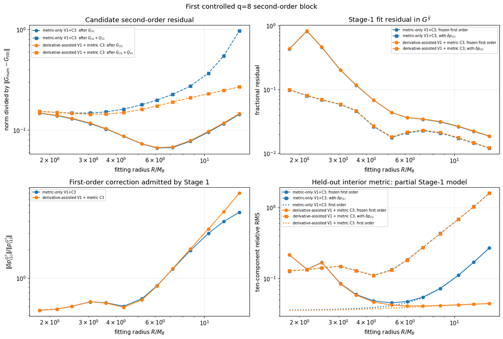

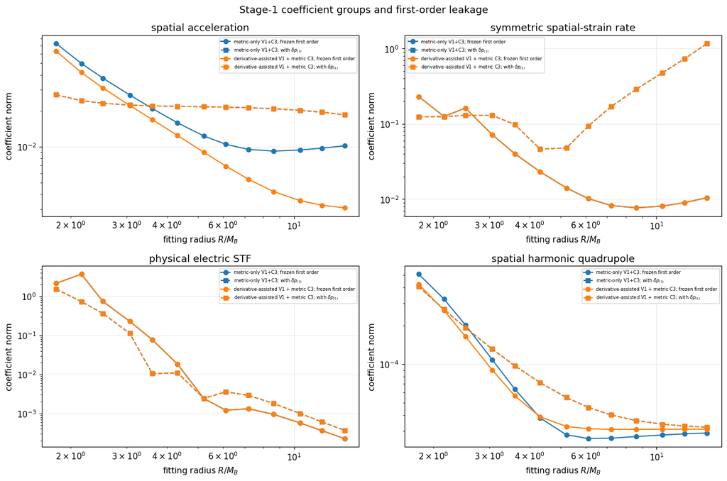

```
Second-order Stage-1 summary

metric-only V1+C3
  frozen first order      : interior=4.546104e-02 at R=0.580; GIJ fit=4.352735e-02
  with $\delta p_{(1)}$   : interior=1.108338e-01 at R=0.480; GIJ fit=2.632547e-02

derivative-assisted V1 + metric C3
  frozen first order      : interior=4.108029e-02 at R=0.800; GIJ fit=3.452774e-02
  with $\delta p_{(1)}$   : interior=1.099004e-01 at R=0.480; GIJ fit=2.673151e-02
```

```python
fig_second_order_stage1, axes = plt.subplots(
    2, 2, figsize=(14.0, 9.5))
baseline_colors = ("C0", "C1")
solve_markers = ("o", "s")

for baseline_index, baseline_name in enumerate(
        SECOND_ORDER_BASELINE_NAMES):
    axes[0, 0].loglog(
        RADIUS_OVER_SMALL_MASS,
        SECOND_ORDER_FIRST_ORDER_RESIDUAL_FRACTION[
            baseline_index],
        "o-",
        color=baseline_colors[baseline_index],
        label=baseline_name + r": after $G_{(1)}$",
    )
    axes[0, 0].loglog(
        RADIUS_OVER_SMALL_MASS,
        SECOND_ORDER_QUADRATIC_RESIDUAL_FRACTION[
            baseline_index],
        "s--",
        color=baseline_colors[baseline_index],
        label=baseline_name + r": after $G_{(1)}+Q_{11}$",
    )

    for solve_index, solve_name in enumerate(
            SECOND_ORDER_SOLVE_NAMES):
        axes[0, 1].loglog(
            RADIUS_OVER_SMALL_MASS,
            SECOND_ORDER_STAGE1_GIJ_RESIDUAL[
                baseline_index, solve_index],
            marker=solve_markers[solve_index],
            linestyle=(
                "-" if solve_index == 0 else "--"),
            color=baseline_colors[baseline_index],
            label=baseline_name + "; " + solve_name,
        )
        axes[1, 1].loglog(
            RADIUS_OVER_SMALL_MASS,
            SECOND_ORDER_STAGE1_INTERIOR_ERROR[
                baseline_index, solve_index],
            marker=solve_markers[solve_index],
            linestyle=(
                "-" if solve_index == 0 else "--"),
            color=baseline_colors[baseline_index],
            label=baseline_name + "; " + solve_name,
        )

    axes[1, 0].loglog(
        RADIUS_OVER_SMALL_MASS,
        SECOND_ORDER_FIRST_ORDER_CORRECTION_FRACTION[
            baseline_index, 1],
        "o-",
        color=baseline_colors[baseline_index],
        label=baseline_name,
    )
    axes[1, 1].loglog(
        RADIUS_OVER_SMALL_MASS,
        SECOND_ORDER_FIRST_ORDER_INTERIOR_ERROR[
            baseline_index],
        ":",
        linewidth=2.0,
        color=baseline_colors[baseline_index],
        label=baseline_name + ": first order",
    )

axes[0, 0].set_title(
    "Candidate second-order residual")
axes[0, 0].set_ylabel(
    r"norm divided by $\|G_{\rm num}-G_{(0)}\|$")
axes[0, 1].set_title(
    r"Stage-1 fit residual in $G^{ij}$")
axes[0, 1].set_ylabel("fractional residual")
axes[1, 0].set_title(
    "First-order correction admitted by Stage 1")
axes[1, 0].set_ylabel(
    r"$\|\delta p_{(1)}^{G^{ij}}\|/"
    r"\|p_{(1)}^{G^{ij}}\|$")
axes[1, 1].set_title(
    "Held-out interior metric: partial Stage-1 model")
axes[1, 1].set_ylabel(
    "ten-component relative RMS")
for axis in axes.flat:
    axis.set_xlabel(r"fitting radius $R/M_B$")
    axis.legend(fontsize=7)
fig_second_order_stage1.suptitle(
    "First controlled q=8 second-order block")
fig_second_order_stage1.tight_layout()
fig_second_order_stage1.savefig(
    OUTPUT_DIRECTORY
    / "q8_t950_second_order_stage1_validation.pdf")
fig_second_order_stage1.savefig(
    OUTPUT_DIRECTORY
    / "q8_t950_second_order_stage1_validation.png",
    dpi=180,
)
plt.show()


fig_second_order_groups, axes = plt.subplots(
    2, 2, figsize=(13.5, 9.0))
for axis, (group_name, group_slice) in zip(
        axes.flat, STAGE1_GROUP_SLICES.items()):
    for baseline_index, baseline_name in enumerate(
            SECOND_ORDER_BASELINE_NAMES):
        for solve_index, solve_name in enumerate(
                SECOND_ORDER_SOLVE_NAMES):
            axis.loglog(
                RADIUS_OVER_SMALL_MASS,
                np.linalg.norm(
                    SECOND_ORDER_STAGE1_PARAMETERS[
                        baseline_index,
                        solve_index,
                        :,
                        group_slice,
                    ],
                    axis=1,
                ),
                marker=solve_markers[solve_index],
                linestyle=(
                    "-" if solve_index == 0 else "--"),
                color=baseline_colors[baseline_index],
                label=baseline_name + "; " + solve_name,
            )
    axis.set_title(group_name)
    axis.set_xlabel(r"fitting radius $R/M_B$")
    axis.set_ylabel("coefficient norm")
    axis.legend(fontsize=6)
fig_second_order_groups.suptitle(
    "Stage-1 coefficient groups and first-order leakage")
fig_second_order_groups.tight_layout()
fig_second_order_groups.savefig(
    OUTPUT_DIRECTORY
    / "q8_t950_second_order_stage1_parameters.pdf")
fig_second_order_groups.savefig(
    OUTPUT_DIRECTORY
    / "q8_t950_second_order_stage1_parameters.png",
    dpi=180,
)
plt.show()


print("\nSecond-order Stage-1 summary")
for baseline_index, baseline_name in enumerate(
        SECOND_ORDER_BASELINE_NAMES):
    print(f"\n{baseline_name}")
    for solve_index, solve_name in enumerate(
            SECOND_ORDER_SOLVE_NAMES):
        best_index = int(np.argmin(
            SECOND_ORDER_STAGE1_INTERIOR_ERROR[
                baseline_index, solve_index]))
        print(
            f"  {solve_name:<24s}: "
            f"interior="
            f"{SECOND_ORDER_STAGE1_INTERIOR_ERROR[baseline_index, solve_index, best_index]:.6e} "
            f"at R={RADIUS_TEST_VALUES[best_index]:.3f}; "
            f"GIJ fit="
            f"{SECOND_ORDER_STAGE1_GIJ_RESIDUAL[baseline_index, solve_index, best_index]:.6e}"
        )
```

### Reading the first second-order block

The (G^{ij}) residual can become very small because Stage 1 contains 29 independent columns. That alone is not evidence of successful physical recovery. The stronger diagnostics are:

- convergence of each coefficient-group norm with radius;
- agreement between the two first-order baselines;
- the size of the admitted (\delta p_{(1)});
- prediction at the random interior points.

The interior curve is intentionally labeled a *partial* Stage-1 model. It contains the known quadratic source and 29 fitted spatial coefficients, but not the remaining temporal-even or magnetic second-order responses. It is therefore useful for detecting catastrophic overfitting or clear improvement, not yet for declaring a complete second-order boundary model.

[figure not shown]

On this slice the frozen 29-column system is numerically healthy: its normalized condition number is only (2.4)--(2.9), and manufactured coefficients are recovered to (9\times10^{-12}). The derivative-assisted first-order baseline gives the better partial Stage-1 interior result, (0.04108) at (R=0.8M_{\rm tot}), compared with (0.04546) for the metric-only baseline. Neither improves on the best first-order-only result (0.03570). This is not yet a failure of second order, because 14 second-order responses remain absent and may restore component cancellations.

The unconstrained first-order-correction solve is much less credible. Although it is algebraically full rank, its condition number grows as high as (2\times10^4); it admits corrections comparable to or larger than the original spatial first-order coefficients and worsens the best interior error to about (0.11). We should therefore keep the first-order baseline frozen for the next temporal-even and magnetic stages, or introduce a quantitatively motivated prior before allowing (\delta p_{(1)}) to vary.

## 12. Complete second-order triangular solve

We now add the fourteen responses omitted from Stage 1, without refitting any first-order coefficient. The 43 second-order unknowns are ordered as

[ \underbrace{a^i,\ \dot b^{(ij)},\ {\cal E}{ij},  
Q^i{}{\langle jk\rangle}}{\text{29 spatial coefficients}}, \qquad \underbrace{a^T,\ \dot b^T{}_i,  
Q^T{}{\langle ij\rangle}}*{\text{9 temporal-even coefficients}}, \qquad \underbrace{{\cal B}*{ij}}_{\text{5 magnetic STF coefficients}} . ]

The response structure makes a triangular component solve possible:

1. fit the 29 spatial coefficients to all six independent components of (G^{ij});
2. subtract their response and fit the nine temporal-even coefficients to (G^{TT});
3. subtract that response and fit the five magnetic coefficients to all three components of (G^{Ti}).

Each line is still an overdetermined linear least-squares problem. Later responses can affect components used in earlier stages only through structures that vanish in those projection blocks. We verify this operationally with a manufactured 43-parameter recovery test before interpreting the simulation.

```python
def gtt_values(metric):
    return np.asarray(metric[0]).ravel()


def gti_values(metric):
    return np.asarray(metric[1]).ravel()


number_of_full_second_order_parameters = len(
    FULL_PARAMETER_NAMES)
assert number_of_full_second_order_parameters == 43
assert np.array_equal(STAGE1_INDICES, np.arange(29))
assert np.array_equal(STAGE2_INDICES, np.arange(29, 38))
assert np.array_equal(STAGE3_INDICES, np.arange(38, 43))

SURFACE_FULL_SECOND_ORDER_COLUMNS = []
SURFACE_STAGE2_GTT_DESIGN = []
SURFACE_STAGE3_GTI_DESIGN = []
for radius_index, radius in enumerate(
        RADIUS_TEST_VALUES):
    columns = full_response_columns_at_points(
        radius * DIRECTIONS, SMALL_BLACK_HOLE_MASS)
    SURFACE_FULL_SECOND_ORDER_COLUMNS.append(columns)
    SURFACE_STAGE2_GTT_DESIGN.append(
        response_design(
            tuple(columns[index] for index in STAGE2_INDICES),
            gtt_values,
        )
    )
    SURFACE_STAGE3_GTI_DESIGN.append(
        response_design(
            tuple(columns[index] for index in STAGE3_INDICES),
            gti_values,
        )
    )

    # Guard against transcription drift between the original Stage-1
    # implementation and the complete response generator.
    for old_column, new_column in zip(
            SURFACE_STAGE1_COLUMNS[radius_index],
            columns[:len(STAGE1_PARAMETER_NAMES)]):
        for old_component, new_component in zip(
                old_column, new_column):
            np.testing.assert_allclose(
                old_component,
                new_component,
                rtol=2.0e-13,
                atol=2.0e-13,
            )
```

```python
COMPLETE_SECOND_ORDER_STAGE_NAMES = (
    r"after $G_{(1)}+Q_{11}$",
    "after 29 spatial responses",
    "after 9 temporal-even responses",
    "after 5 magnetic responses",
)
number_of_complete_stages = len(
    COMPLETE_SECOND_ORDER_STAGE_NAMES)

COMPLETE_SECOND_ORDER_PARAMETERS = np.zeros((
    number_of_second_order_baselines,
    number_of_radii,
    number_of_full_second_order_parameters,
))
COMPLETE_SECOND_ORDER_STAGE_CANDIDATE_FRACTION = np.empty((
    number_of_second_order_baselines,
    number_of_radii,
    number_of_complete_stages,
))
COMPLETE_SECOND_ORDER_STAGE_RAW_FRACTION = np.empty_like(
    COMPLETE_SECOND_ORDER_STAGE_CANDIDATE_FRACTION)
COMPLETE_SECOND_ORDER_COMPONENT_FRACTION = np.empty((
    number_of_second_order_baselines,
    number_of_radii,
    3,
))
COMPLETE_SECOND_ORDER_STAGE2_GTT_CLOSURE = np.empty((
    number_of_second_order_baselines,
    number_of_radii,
))
COMPLETE_SECOND_ORDER_STAGE3_GTI_CLOSURE = np.empty_like(
    COMPLETE_SECOND_ORDER_STAGE2_GTT_CLOSURE)
COMPLETE_SECOND_ORDER_STAGE2_RANK = np.empty((
    number_of_second_order_baselines,
    number_of_radii,
), dtype=int)
COMPLETE_SECOND_ORDER_STAGE3_RANK = np.empty_like(
    COMPLETE_SECOND_ORDER_STAGE2_RANK)
COMPLETE_SECOND_ORDER_STAGE2_CONDITION = np.empty((
    number_of_second_order_baselines,
    number_of_radii,
))
COMPLETE_SECOND_ORDER_STAGE3_CONDITION = np.empty_like(
    COMPLETE_SECOND_ORDER_STAGE2_CONDITION)

for baseline_index in range(
        number_of_second_order_baselines):
    for radius_index, radius in enumerate(
            RADIUS_TEST_VALUES):
        columns = SURFACE_FULL_SECOND_ORDER_COLUMNS[
            radius_index]
        candidate = SECOND_ORDER_CANDIDATE_RESIDUALS[
            baseline_index][radius_index]
        candidate_norm = max(
            np.linalg.norm(metric_values_by_point(candidate)),
            1.0e-300,
        )

        points = radius * DIRECTIONS
        numerical_metric = unpack_inverse_metric(
            FIRST_ORDER_METRIC_DATA[:, radius_index])
        background_metric = inverse_harmonic_schwarzschild(
            points, SMALL_BLACK_HOLE_MASS)
        raw_residual = subtract_metric(
            numerical_metric, background_metric)
        raw_norm = max(
            np.linalg.norm(
                metric_values_by_point(raw_residual)),
            1.0e-300,
        )

        parameters = COMPLETE_SECOND_ORDER_PARAMETERS[
            baseline_index, radius_index]
        parameters[STAGE1_INDICES] = (
            SECOND_ORDER_STAGE1_PARAMETERS[
                baseline_index, 0, radius_index]
        )
        stage1_prediction = metric_linear_combination(
            tuple(columns[index] for index in STAGE1_INDICES),
            parameters[STAGE1_INDICES],
        )
        after_stage1 = subtract_metric(
            candidate, stage1_prediction)

        (
            temporal_solution,
            temporal_rank,
            temporal_condition,
        ) = scaled_least_squares(
            SURFACE_STAGE2_GTT_DESIGN[radius_index],
            gtt_values(after_stage1),
        )
        parameters[STAGE2_INDICES] = temporal_solution
        COMPLETE_SECOND_ORDER_STAGE2_RANK[
            baseline_index, radius_index] = temporal_rank
        COMPLETE_SECOND_ORDER_STAGE2_CONDITION[
            baseline_index, radius_index] = temporal_condition
        stage2_prediction = metric_linear_combination(
            tuple(columns[index] for index in STAGE2_INDICES),
            temporal_solution,
        )
        after_stage2 = subtract_metric(
            after_stage1, stage2_prediction)

        (
            magnetic_solution,
            magnetic_rank,
            magnetic_condition,
        ) = scaled_least_squares(
            SURFACE_STAGE3_GTI_DESIGN[radius_index],
            gti_values(after_stage2),
        )
        parameters[STAGE3_INDICES] = magnetic_solution
        COMPLETE_SECOND_ORDER_STAGE3_RANK[
            baseline_index, radius_index] = magnetic_rank
        COMPLETE_SECOND_ORDER_STAGE3_CONDITION[
            baseline_index, radius_index] = magnetic_condition
        stage3_prediction = metric_linear_combination(
            tuple(columns[index] for index in STAGE3_INDICES),
            magnetic_solution,
        )
        after_stage3 = subtract_metric(
            after_stage2, stage3_prediction)
        COMPLETE_SECOND_ORDER_STAGE2_GTT_CLOSURE[
            baseline_index, radius_index] = (
                np.linalg.norm(after_stage2[0])
                / max(
                    np.linalg.norm(after_stage1[0]),
                    1.0e-300,
                )
            )
        COMPLETE_SECOND_ORDER_STAGE3_GTI_CLOSURE[
            baseline_index, radius_index] = (
                np.linalg.norm(after_stage3[1])
                / max(
                    np.linalg.norm(after_stage2[1]),
                    1.0e-300,
                )
            )

        stage_metrics = (
            candidate,
            after_stage1,
            after_stage2,
            after_stage3,
        )
        for stage_index, stage_metric in enumerate(
                stage_metrics):
            stage_norm = np.linalg.norm(
                metric_values_by_point(stage_metric))
            COMPLETE_SECOND_ORDER_STAGE_CANDIDATE_FRACTION[
                baseline_index,
                radius_index,
                stage_index,
            ] = stage_norm / candidate_norm
            COMPLETE_SECOND_ORDER_STAGE_RAW_FRACTION[
                baseline_index,
                radius_index,
                stage_index,
            ] = stage_norm / raw_norm

        for component_index, component in enumerate(
                after_stage3):
            COMPLETE_SECOND_ORDER_COMPONENT_FRACTION[
                baseline_index,
                radius_index,
                component_index,
            ] = (
                np.linalg.norm(component)
                / max(
                    np.linalg.norm(candidate[component_index]),
                    1.0e-300,
                )
            )

print("Complete second-order triangular ranks and conditions")
for baseline_index, baseline_name in enumerate(
        SECOND_ORDER_BASELINE_NAMES):
    print(f"\n{baseline_name}")
    print(
        "  temporal-even GTT block: "
        f"rank {COMPLETE_SECOND_ORDER_STAGE2_RANK[baseline_index].min()}"
        f"--{COMPLETE_SECOND_ORDER_STAGE2_RANK[baseline_index].max()}, "
        "condition "
        f"{COMPLETE_SECOND_ORDER_STAGE2_CONDITION[baseline_index].min():.3e}"
        "--"
        f"{COMPLETE_SECOND_ORDER_STAGE2_CONDITION[baseline_index].max():.3e}"
    )
    print(
        "  magnetic GTI block:      "
        f"rank {COMPLETE_SECOND_ORDER_STAGE3_RANK[baseline_index].min()}"
        f"--{COMPLETE_SECOND_ORDER_STAGE3_RANK[baseline_index].max()}, "
        "condition "
        f"{COMPLETE_SECOND_ORDER_STAGE3_CONDITION[baseline_index].min():.3e}"
        "--"
        f"{COMPLETE_SECOND_ORDER_STAGE3_CONDITION[baseline_index].max():.3e}"
    )
    print(
        "  temporal GTT closure:    "
        f"{COMPLETE_SECOND_ORDER_STAGE2_GTT_CLOSURE[baseline_index].min():.3e}"
        "--"
        f"{COMPLETE_SECOND_ORDER_STAGE2_GTT_CLOSURE[baseline_index].max():.3e}"
    )
    print(
        "  magnetic GTI closure:    "
        f"{COMPLETE_SECOND_ORDER_STAGE3_GTI_CLOSURE[baseline_index].min():.3e}"
        "--"
        f"{COMPLETE_SECOND_ORDER_STAGE3_GTI_CLOSURE[baseline_index].max():.3e}"
    )
```

```
Complete second-order triangular ranks and conditions

metric-only V1+C3
  temporal-even GTT block: rank 9--9, condition 1.527e+00--1.527e+00
  magnetic GTI block:      rank 5--5, condition 1.000e+00--1.000e+00
  temporal GTT closure:    4.226e-04--3.132e-03
  magnetic GTI closure:    9.999e-01--1.000e+00

derivative-assisted V1 + metric C3
  temporal-even GTT block: rank 9--9, condition 1.527e+00--1.527e+00
  magnetic GTI block:      rank 5--5, condition 1.000e+00--1.000e+00
  temporal GTT closure:    9.287e-04--3.763e-03
  magnetic GTI closure:    1.000e+00--1.000e+00
```

### Manufactured recovery of the complete hierarchy

We prescribe all 43 coefficients, construct their exact response on each worldtube, and apply precisely the same three solves. This is stronger than a rank printout: it checks that subtracting each fitted response leaves the correct data for the next block and that the component ordering is consistent.

```python
complete_manufactured_rng = np.random.default_rng(20260729)
MANUFACTURED_COMPLETE_PARAMETERS = (
    complete_manufactured_rng.normal(
        size=number_of_full_second_order_parameters))
MANUFACTURED_COMPLETE_PARAMETER_ERROR = np.empty(
    number_of_radii)
MANUFACTURED_COMPLETE_METRIC_CLOSURE = np.empty(
    number_of_radii)

for radius_index in range(number_of_radii):
    columns = SURFACE_FULL_SECOND_ORDER_COLUMNS[
        radius_index]
    synthetic_metric = metric_linear_combination(
        columns, MANUFACTURED_COMPLETE_PARAMETERS)
    recovered = np.zeros(
        number_of_full_second_order_parameters)

    recovered[STAGE1_INDICES], _, _ = (
        scaled_least_squares(
            SURFACE_STAGE1_GIJ_DESIGN[radius_index],
            gij_values(synthetic_metric),
        )
    )
    after_spatial = subtract_metric(
        synthetic_metric,
        metric_linear_combination(
            tuple(columns[index] for index in STAGE1_INDICES),
            recovered[STAGE1_INDICES],
        ),
    )
    recovered[STAGE2_INDICES], _, _ = (
        scaled_least_squares(
            SURFACE_STAGE2_GTT_DESIGN[radius_index],
            gtt_values(after_spatial),
        )
    )
    after_temporal = subtract_metric(
        after_spatial,
        metric_linear_combination(
            tuple(columns[index] for index in STAGE2_INDICES),
            recovered[STAGE2_INDICES],
        ),
    )
    recovered[STAGE3_INDICES], _, _ = (
        scaled_least_squares(
            SURFACE_STAGE3_GTI_DESIGN[radius_index],
            gti_values(after_temporal),
        )
    )
    reconstructed = metric_linear_combination(
        columns, recovered)

    MANUFACTURED_COMPLETE_PARAMETER_ERROR[radius_index] = (
        np.max(np.abs(
            recovered
            - MANUFACTURED_COMPLETE_PARAMETERS))
    )
    MANUFACTURED_COMPLETE_METRIC_CLOSURE[radius_index] = (
        np.linalg.norm(metric_values_by_point(
            subtract_metric(
                synthetic_metric, reconstructed)))
        / np.linalg.norm(
            metric_values_by_point(synthetic_metric))
    )

print(
    "maximum manufactured 43-parameter error:",
    f"{MANUFACTURED_COMPLETE_PARAMETER_ERROR.max():.3e}",
)
print(
    "maximum manufactured metric closure:",
    f"{MANUFACTURED_COMPLETE_METRIC_CLOSURE.max():.3e}",
)
assert MANUFACTURED_COMPLETE_PARAMETER_ERROR.max() < 3.0e-10
assert MANUFACTURED_COMPLETE_METRIC_CLOSURE.max() < 3.0e-12
```

```
maximum manufactured 43-parameter error: 7.758e-12
maximum manufactured metric closure: 1.777e-14
```

```python
# Complete held-out interior prediction.  The random points and numerical
# target are exactly the same as in the zeroth- and first-order comparisons.
INTERIOR_FULL_SECOND_ORDER_COLUMNS = (
    full_response_columns_at_points(
        INTERIOR_LOCAL_POINTS,
        SMALL_BLACK_HOLE_MASS,
    )
)
INTERIOR_FULL_SECOND_ORDER_DESIGN = np.stack([
    metric_values_by_point(column)
    for column in INTERIOR_FULL_SECOND_ORDER_COLUMNS
], axis=-1)

COMPLETE_SECOND_ORDER_QUADRATIC_INTERIOR_ERROR = np.empty((
    number_of_second_order_baselines,
    number_of_radii,
))
COMPLETE_SECOND_ORDER_INTERIOR_ERROR = np.empty_like(
    COMPLETE_SECOND_ORDER_QUADRATIC_INTERIOR_ERROR)
COMPLETE_SECOND_ORDER_INTERIOR_PERTURBATION_RESIDUAL = (
    np.empty_like(
        COMPLETE_SECOND_ORDER_QUADRATIC_INTERIOR_ERROR)
)
COMPLETE_SECOND_ORDER_POINTWISE_RELATIVE_ERROR = np.empty((
    number_of_second_order_baselines,
    number_of_radii,
    len(INTERIOR_LOCAL_POINTS),
))

for baseline_index in range(
        number_of_second_order_baselines):
    for radius_index in range(number_of_radii):
        first_order_parameters = (
            SECOND_ORDER_FIRST_ORDER_BASELINES[
                baseline_index, radius_index])
        first_order_values = np.einsum(
            "ncp,p->nc",
            INTERIOR_RESPONSE_DESIGN,
            first_order_parameters,
        )
        beta = first_order_parameters[1:4]
        spatial_strain = symmetric_matrix_from_six(
            first_order_parameters[7:13])
        quadratic_values = metric_values_by_point(
            known_quadratic_first_order_source(
                INTERIOR_LOCAL_POINTS,
                beta,
                spatial_strain,
                SMALL_BLACK_HOLE_MASS,
            )
        )
        quadratic_model = (
            INTERIOR_BACKGROUND_VALUES
            + first_order_values
            + quadratic_values
        )
        COMPLETE_SECOND_ORDER_QUADRATIC_INTERIOR_ERROR[
            baseline_index, radius_index] = (
                np.linalg.norm(
                    INTERIOR_NUMERICAL_VALUES
                    - quadratic_model)
                / np.linalg.norm(
                    INTERIOR_NUMERICAL_VALUES)
            )

        complete_model = (
            quadratic_model
            + np.einsum(
                "ncp,p->nc",
                INTERIOR_FULL_SECOND_ORDER_DESIGN,
                COMPLETE_SECOND_ORDER_PARAMETERS[
                    baseline_index, radius_index],
            )
        )
        pointwise_error = np.linalg.norm(
            INTERIOR_NUMERICAL_VALUES
            - complete_model,
            axis=1,
        ) / np.maximum(
            np.linalg.norm(
                INTERIOR_NUMERICAL_VALUES, axis=1),
            1.0e-300,
        )
        COMPLETE_SECOND_ORDER_POINTWISE_RELATIVE_ERROR[
            baseline_index, radius_index] = pointwise_error
        COMPLETE_SECOND_ORDER_INTERIOR_ERROR[
            baseline_index, radius_index] = (
                np.linalg.norm(
                    INTERIOR_NUMERICAL_VALUES
                    - complete_model)
                / np.linalg.norm(
                    INTERIOR_NUMERICAL_VALUES)
            )
        COMPLETE_SECOND_ORDER_INTERIOR_PERTURBATION_RESIDUAL[
            baseline_index, radius_index] = (
                np.linalg.norm(
                    INTERIOR_NUMERICAL_VALUES
                    - complete_model)
                / np.linalg.norm(
                    INTERIOR_PERTURBATION_VALUES)
            )
```

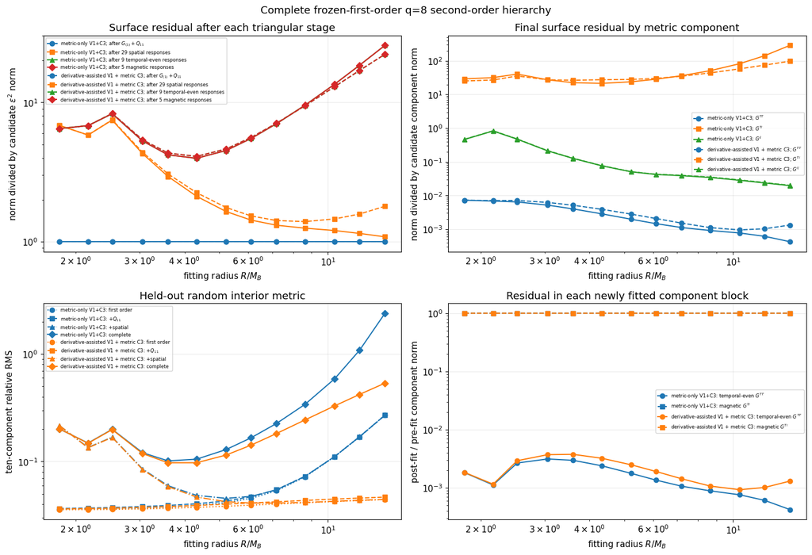

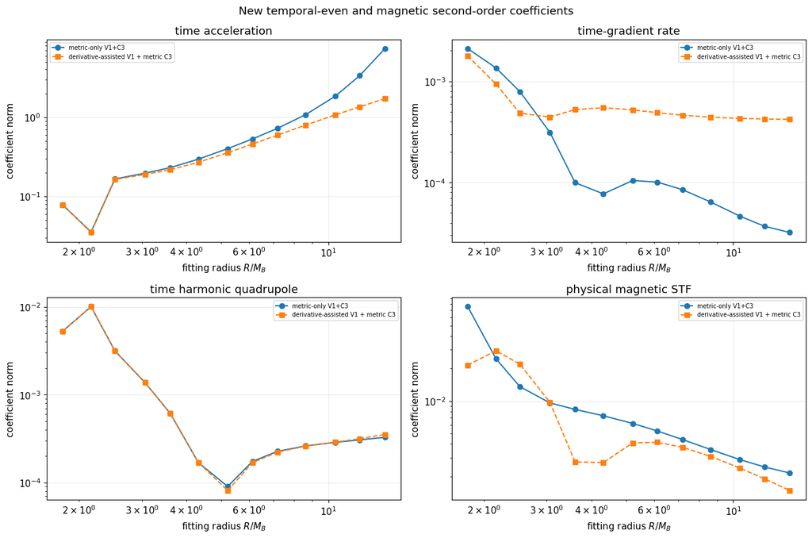

```
Complete second-order held-out interior summary

metric-only V1+C3
  best complete interior error = 1.014260e-01 at R=0.400 (R/M_B=3.600)
  best first-order interior error = 3.605541e-02
  final candidate-normalized surface residual = 4.199847e+00

derivative-assisted V1 + metric C3
  best complete interior error = 9.737959e-02 at R=0.400 (R/M_B=3.600)
  best first-order interior error = 3.569933e-02
  final candidate-normalized surface residual = 4.327167e+00
```

```python
fig_second_order_complete, axes = plt.subplots(
    2, 2, figsize=(14.5, 10.0))
stage_markers = ("o", "s", "^", "D")
component_labels = (
    r"$G^{TT}$", r"$G^{Ti}$", r"$G^{ij}$")

for baseline_index, baseline_name in enumerate(
        SECOND_ORDER_BASELINE_NAMES):
    for stage_index, stage_name in enumerate(
            COMPLETE_SECOND_ORDER_STAGE_NAMES):
        axes[0, 0].loglog(
            RADIUS_OVER_SMALL_MASS,
            COMPLETE_SECOND_ORDER_STAGE_CANDIDATE_FRACTION[
                baseline_index, :, stage_index],
            marker=stage_markers[stage_index],
            linestyle=(
                "-" if baseline_index == 0 else "--"),
            color=f"C{stage_index}",
            label=baseline_name + "; " + stage_name,
        )

    for component_index, component_label in enumerate(
            component_labels):
        axes[0, 1].loglog(
            RADIUS_OVER_SMALL_MASS,
            COMPLETE_SECOND_ORDER_COMPONENT_FRACTION[
                baseline_index, :, component_index],
            marker=stage_markers[component_index],
            linestyle=(
                "-" if baseline_index == 0 else "--"),
            color=f"C{component_index}",
            label=baseline_name + "; " + component_label,
        )

    axes[1, 0].loglog(
        RADIUS_OVER_SMALL_MASS,
        SECOND_ORDER_FIRST_ORDER_INTERIOR_ERROR[
            baseline_index],
        "o:",
        color=baseline_colors[baseline_index],
        label=baseline_name + ": first order",
    )
    axes[1, 0].loglog(
        RADIUS_OVER_SMALL_MASS,
        COMPLETE_SECOND_ORDER_QUADRATIC_INTERIOR_ERROR[
            baseline_index],
        "s--",
        color=baseline_colors[baseline_index],
        label=baseline_name + r": $+Q_{11}$",
    )
    axes[1, 0].loglog(
        RADIUS_OVER_SMALL_MASS,
        SECOND_ORDER_STAGE1_INTERIOR_ERROR[
            baseline_index, 0],
        "^-.",
        color=baseline_colors[baseline_index],
        label=baseline_name + ": +spatial",
    )
    axes[1, 0].loglog(
        RADIUS_OVER_SMALL_MASS,
        COMPLETE_SECOND_ORDER_INTERIOR_ERROR[
            baseline_index],
        "D-",
        color=baseline_colors[baseline_index],
        label=baseline_name + ": complete",
    )

    axes[1, 1].loglog(
        RADIUS_OVER_SMALL_MASS,
        COMPLETE_SECOND_ORDER_STAGE2_GTT_CLOSURE[
            baseline_index],
        "o-",
        color=baseline_colors[baseline_index],
        label=baseline_name + r": temporal-even $G^{TT}$",
    )
    axes[1, 1].loglog(
        RADIUS_OVER_SMALL_MASS,
        COMPLETE_SECOND_ORDER_STAGE3_GTI_CLOSURE[
            baseline_index],
        "s--",
        color=baseline_colors[baseline_index],
        label=baseline_name + r": magnetic $G^{Ti}$",
    )

axes[0, 0].set_title(
    "Surface residual after each triangular stage")
axes[0, 0].set_ylabel(
    r"norm divided by candidate $\epsilon^2$ norm")
axes[0, 1].set_title(
    "Final surface residual by metric component")
axes[0, 1].set_ylabel(
    "norm divided by candidate component norm")
axes[1, 0].set_title(
    "Held-out random interior metric")
axes[1, 0].set_ylabel(
    "ten-component relative RMS")
axes[1, 1].set_title(
    "Residual in each newly fitted component block")
axes[1, 1].set_ylabel(
    "post-fit / pre-fit component norm")
for axis in axes.flat:
    axis.set_xlabel(r"fitting radius $R/M_B$")
    axis.legend(fontsize=6)
fig_second_order_complete.suptitle(
    "Complete frozen-first-order q=8 second-order hierarchy")
fig_second_order_complete.tight_layout()
fig_second_order_complete.savefig(
    OUTPUT_DIRECTORY
    / "q8_t950_second_order_complete_validation.pdf")
fig_second_order_complete.savefig(
    OUTPUT_DIRECTORY
    / "q8_t950_second_order_complete_validation.png",
    dpi=180,
)
plt.show()


fig_second_order_new_groups, axes = plt.subplots(
    2, 2, figsize=(13.5, 9.0))
new_group_names = (
    "time acceleration",
    "time-gradient rate",
    "time harmonic quadrupole",
    "physical magnetic STF",
)
for axis, group_name in zip(
        axes.flat, new_group_names):
    group_slice = FULL_GROUP_SLICES[group_name]
    for baseline_index, baseline_name in enumerate(
            SECOND_ORDER_BASELINE_NAMES):
        values = np.linalg.norm(
            COMPLETE_SECOND_ORDER_PARAMETERS[
                baseline_index, :, group_slice],
            axis=1,
        )
        axis.loglog(
            RADIUS_OVER_SMALL_MASS,
            np.maximum(values, 1.0e-300),
            "o-" if baseline_index == 0 else "s--",
            color=baseline_colors[baseline_index],
            label=baseline_name,
        )
    axis.set_title(group_name)
    axis.set_xlabel(r"fitting radius $R/M_B$")
    axis.set_ylabel("coefficient norm")
    axis.legend(fontsize=7)
fig_second_order_new_groups.suptitle(
    "New temporal-even and magnetic second-order coefficients")
fig_second_order_new_groups.tight_layout()
fig_second_order_new_groups.savefig(
    OUTPUT_DIRECTORY
    / "q8_t950_second_order_complete_parameters.pdf")
fig_second_order_new_groups.savefig(
    OUTPUT_DIRECTORY
    / "q8_t950_second_order_complete_parameters.png",
    dpi=180,
)
plt.show()


print("\nComplete second-order held-out interior summary")
for baseline_index, baseline_name in enumerate(
        SECOND_ORDER_BASELINE_NAMES):
    best_index = int(np.argmin(
        COMPLETE_SECOND_ORDER_INTERIOR_ERROR[
            baseline_index]))
    first_order_best = np.min(
        SECOND_ORDER_FIRST_ORDER_INTERIOR_ERROR[
            baseline_index])
    print(f"\n{baseline_name}")
    print(
        "  best complete interior error = "
        f"{COMPLETE_SECOND_ORDER_INTERIOR_ERROR[baseline_index, best_index]:.6e} "
        f"at R={RADIUS_TEST_VALUES[best_index]:.3f} "
        f"(R/M_B={RADIUS_OVER_SMALL_MASS[best_index]:.3f})"
    )
    print(
        "  best first-order interior error = "
        f"{first_order_best:.6e}"
    )
    print(
        "  final candidate-normalized surface residual = "
        f"{COMPLETE_SECOND_ORDER_STAGE_CANDIDATE_FRACTION[baseline_index, best_index, -1]:.6e}"
    )
```

### How to read the complete fit

The manufactured test establishes that the triangular algebra itself recovers all 43 coefficients and closes the metric when the data are generated by the same model. It does **not** establish that the numerical binary metric is described accurately by the truncation on this slice.

The decisive physical diagnostic remains the random interior prediction. A small fitted surface residual accompanied by a worse interior residual is evidence that the second-order columns are absorbing omitted higher-order structure or numerical error at the fitting sphere. For that reason no coefficient is promoted to a boundary prescription solely because its own block closes.

That failure mode is what occurs on this slice. The temporal (G^{TT}) block closes to (4\times10^{-4})--(4\times10^{-3}) of its pre-fit norm, but its predicted (G^{Ti}) contribution is not supported by the numerical residual. The magnetic fit removes essentially none of that mismatch: its post-fit/pre-fit (G^{Ti}) norm is unity to the displayed precision. Thus the final (G^{TT}) and (G^{ij}) closures are small while the (G^{Ti}) residual is tens to hundreds of times its candidate norm.

The held-out interior check reaches the same conclusion. The complete hierarchy bottoms out near (9.7%)--(10.1%), whereas the corresponding first-order models reach (3.57%)--(3.61%). Since the manufactured 43-parameter test recovers coefficients to (8\times10^{-12}) and the two new matrices have condition numbers (1.53) and (1.00), this is not a rank or numerical-conditioning failure. It is a cross-component closure failure of this strictly triangular second-order estimator on the q=8 (t=950M) data.

## 13. Which second-order blocks carry recoverable information?

The failed complete triangular solve does not imply that every second-order response is unusable. We now repeat the more discriminating q=4 analysis. There are three different questions:

1. **Response sensitivity:** can a physical coefficient group make a measurable change to the metric?
2. **Fit utility:** when that group is fitted by itself, does it reduce the surface candidate residual and improve the held-out interior metric?
3. **Cross-block consistency:** do coefficients recovered from one STF block correctly predict another block that was not fitted?

A small in-block residual answers none of the other questions. Throughout this section the first-order parameters remain frozen and the known quadratic source (Q_{11}) is subtracted before fitting.

### 13.1 Irreducible STF subsystems

We begin with the same three targeted systems used for q=4.

The polar-(J=2) system combines [ G^{TT}*{\ell=2},\qquad G^{Ti}*{\ell=3},\qquad G^{ij}_{\ell=4} ] to recover the STF spatial-strain rate, physical electric STF tensor, and time-coordinate quadrupole: fifteen coefficients in total.

The spatial system fits the three accelerations and fifteen spatial quadrupole coefficients using (G^{ij}*{\ell=1}), then predicts the held-out (G^{ij}*{\ell=3,5}) blocks.

Finally, the fully symmetric (J=3) part of the spatial quadrupole has seven coefficients that can be recovered independently from each of (G^{TT}*{\ell=3}), (G^{Ti}*{\ell=4}), and (G^{ij}_{\ell=5}). Agreement between these independent estimators is a particularly clean closure test.

```python
from itertools import permutations

POLAR_J2_BLOCKS = (
    ("GTT", 2), ("GTI", 3), ("GIJ", 4))
SPATIAL_ESTIMATOR_BLOCKS = (("GIJ", 1),)
SPATIAL_CLOSURE_BLOCKS = (
    ("GIJ", 3), ("GIJ", 5))
SPATIAL_J3_BLOCKS = (
    ("GTT", 3), ("GTI", 4), ("GIJ", 5))


def response_field_on_sphere(radius, builder):
    matrices = np.asarray([
        builder(direction) for direction in DIRECTIONS
    ])
    return matrix_to_metric_tuple(matrices)


def polar_j2_response_columns(radius):
    columns = []
    for basis in STF_BASIS:
        columns.append(response_field_on_sphere(
            radius,
            lambda direction, basis=basis:
            strain_rate_response_at_direction(
                SMALL_BLACK_HOLE_MASS,
                radius,
                direction,
                basis,
            ),
        ))
    for basis in STF_BASIS:
        columns.append(response_field_on_sphere(
            radius,
            lambda direction, basis=basis:
            electric_response_at_direction(
                SMALL_BLACK_HOLE_MASS,
                radius,
                direction,
                basis,
            ),
        ))
    for basis in STF_BASIS:
        columns.append(response_field_on_sphere(
            radius,
            lambda direction, basis=basis:
            time_quadrupole_response_at_direction(
                SMALL_BLACK_HOLE_MASS,
                radius,
                direction,
                basis,
            ),
        ))
    return tuple(columns)


def projected_design(
        columns, blocks, parameter_indices=None):
    if parameter_indices is None:
        parameter_indices = np.arange(len(columns))
    return np.concatenate([
        np.column_stack([
            metric_stf_block(*columns[index], block)
            for index in parameter_indices
        ])
        for block in blocks
    ], axis=0)


def projected_data(metric, blocks):
    return np.concatenate([
        metric_stf_block(*metric, block)
        for block in blocks
    ])


def projected_residual_fraction(
        columns, estimate, metric, block,
        parameter_indices=None):
    matrix = projected_design(
        columns, (block,), parameter_indices)
    data = projected_data(metric, (block,))
    return (
        np.linalg.norm(data - matrix @ estimate)
        / max(np.linalg.norm(data), 1.0e-300)
    )


def orthonormal_stf_rank3_basis():
    symmetric_basis = []
    for i in range(3):
        for j in range(i, 3):
            for k in range(j, 3):
                tensor = np.zeros((3, 3, 3))
                index_permutations = sorted(
                    set(permutations((i, j, k))))
                for indices in index_permutations:
                    tensor[indices] = (
                        1.0 / np.sqrt(
                            len(index_permutations)))
                symmetric_basis.append(tensor)
    symmetric_basis = np.asarray(symmetric_basis)
    trace_constraints = np.column_stack([
        np.einsum(
            "aiik->ak", symmetric_basis)[:, component]
        for component in range(3)
    ]).T
    _, singular_values, right_vectors = np.linalg.svd(
        trace_constraints)
    rank = np.count_nonzero(
        singular_values
        > 1.0e-12 * singular_values[0])
    basis = np.einsum(
        "ab,bijk->aijk",
        right_vectors[rank:],
        symmetric_basis,
    )
    assert basis.shape == (7, 3, 3, 3)
    assert (
        np.max(np.abs(
            np.einsum("aiik->ak", basis)))
        < 1.0e-12
    )
    return basis


SPATIAL_J3_BASIS = orthonormal_stf_rank3_basis()


def spatial_j3_response_columns(radius):
    return tuple(
        response_field_on_sphere(
            radius,
            lambda direction, basis=basis:
            spatial_quadrupole_response_at_direction(
                SMALL_BLACK_HOLE_MASS,
                radius,
                direction,
                basis,
            ),
        )
        for basis in SPATIAL_J3_BASIS
    )
```

```python
POLAR_J2_ESTIMATES = np.empty((
    number_of_second_order_baselines,
    number_of_radii,
    15,
))
POLAR_J2_BLOCK_RESIDUALS = np.empty((
    number_of_second_order_baselines,
    number_of_radii,
    len(POLAR_J2_BLOCKS),
))
POLAR_J2_RANK = np.empty(
    number_of_radii, dtype=int)
POLAR_J2_CONDITION = np.empty(number_of_radii)

SPATIAL_ORTHOGONAL_ESTIMATES = np.empty((
    number_of_second_order_baselines,
    number_of_radii,
    18,
))
SPATIAL_ORTHOGONAL_IN_SAMPLE = np.empty((
    number_of_second_order_baselines,
    number_of_radii,
))
SPATIAL_ORTHOGONAL_CLOSURE = np.empty((
    number_of_second_order_baselines,
    number_of_radii,
    len(SPATIAL_CLOSURE_BLOCKS),
))
SPATIAL_ORTHOGONAL_RANK = np.empty(
    number_of_radii, dtype=int)
SPATIAL_ORTHOGONAL_CONDITION = np.empty(
    number_of_radii)

SPATIAL_J3_ESTIMATES = np.empty((
    number_of_second_order_baselines,
    number_of_radii,
    len(SPATIAL_J3_BLOCKS),
    7,
))
SPATIAL_J3_CLOSURE = np.empty((
    number_of_second_order_baselines,
    number_of_radii,
    len(SPATIAL_J3_BLOCKS),
    len(SPATIAL_J3_BLOCKS),
))
SPATIAL_J3_RANK = np.empty((
    number_of_radii,
    len(SPATIAL_J3_BLOCKS),
), dtype=int)
SPATIAL_J3_CONDITION = np.empty((
    number_of_radii,
    len(SPATIAL_J3_BLOCKS),
))

spatial_parameter_indices = np.r_[
    np.arange(0, 3), np.arange(14, 29)]

for radius_index, radius in enumerate(
        RADIUS_TEST_VALUES):
    polar_columns = polar_j2_response_columns(radius)
    polar_matrix = projected_design(
        polar_columns, POLAR_J2_BLOCKS)
    _, polar_rank, polar_condition = (
        scaled_least_squares(
            polar_matrix,
            np.zeros(polar_matrix.shape[0]),
        )
    )
    POLAR_J2_RANK[radius_index] = polar_rank
    POLAR_J2_CONDITION[radius_index] = (
        polar_condition)

    complete_columns = (
        SURFACE_FULL_SECOND_ORDER_COLUMNS[
            radius_index])
    spatial_matrix = projected_design(
        complete_columns,
        SPATIAL_ESTIMATOR_BLOCKS,
        spatial_parameter_indices,
    )
    _, spatial_rank, spatial_condition = (
        scaled_least_squares(
            spatial_matrix,
            np.zeros(spatial_matrix.shape[0]),
        )
    )
    SPATIAL_ORTHOGONAL_RANK[
        radius_index] = spatial_rank
    SPATIAL_ORTHOGONAL_CONDITION[
        radius_index] = spatial_condition

    j3_columns = spatial_j3_response_columns(radius)
    for estimator_index, estimator_block in enumerate(
            SPATIAL_J3_BLOCKS):
        j3_matrix = projected_design(
            j3_columns, (estimator_block,))
        _, j3_rank, j3_condition = (
            scaled_least_squares(
                j3_matrix,
                np.zeros(j3_matrix.shape[0]),
            )
        )
        SPATIAL_J3_RANK[
            radius_index, estimator_index] = j3_rank
        SPATIAL_J3_CONDITION[
            radius_index, estimator_index] = (
                j3_condition)

    for baseline_index in range(
            number_of_second_order_baselines):
        candidate = SECOND_ORDER_CANDIDATE_RESIDUALS[
            baseline_index][radius_index]

        polar_data = projected_data(
            candidate, POLAR_J2_BLOCKS)
        polar_estimate, _, _ = scaled_least_squares(
            polar_matrix, polar_data)
        POLAR_J2_ESTIMATES[
            baseline_index, radius_index] = (
                polar_estimate)
        for block_index, block in enumerate(
                POLAR_J2_BLOCKS):
            POLAR_J2_BLOCK_RESIDUALS[
                baseline_index,
                radius_index,
                block_index,
            ] = projected_residual_fraction(
                polar_columns,
                polar_estimate,
                candidate,
                block,
            )

        spatial_data = projected_data(
            candidate, SPATIAL_ESTIMATOR_BLOCKS)
        spatial_estimate, _, _ = scaled_least_squares(
            spatial_matrix, spatial_data)
        SPATIAL_ORTHOGONAL_ESTIMATES[
            baseline_index, radius_index] = (
                spatial_estimate)
        SPATIAL_ORTHOGONAL_IN_SAMPLE[
            baseline_index, radius_index] = (
                np.linalg.norm(
                    spatial_data
                    - spatial_matrix @ spatial_estimate)
                / max(
                    np.linalg.norm(spatial_data),
                    1.0e-300,
                )
            )
        for block_index, block in enumerate(
                SPATIAL_CLOSURE_BLOCKS):
            closure_matrix = projected_design(
                complete_columns,
                (block,),
                spatial_parameter_indices,
            )
            closure_data = projected_data(
                candidate, (block,))
            SPATIAL_ORTHOGONAL_CLOSURE[
                baseline_index,
                radius_index,
                block_index,
            ] = (
                np.linalg.norm(
                    closure_data
                    - closure_matrix @ spatial_estimate)
                / max(
                    np.linalg.norm(closure_data),
                    1.0e-300,
                )
            )

        for estimator_index, estimator_block in enumerate(
                SPATIAL_J3_BLOCKS):
            j3_matrix = projected_design(
                j3_columns, (estimator_block,))
            j3_data = projected_data(
                candidate, (estimator_block,))
            j3_estimate, _, _ = scaled_least_squares(
                j3_matrix, j3_data)
            SPATIAL_J3_ESTIMATES[
                baseline_index,
                radius_index,
                estimator_index,
            ] = j3_estimate
            for prediction_index, prediction_block in enumerate(
                    SPATIAL_J3_BLOCKS):
                prediction_matrix = projected_design(
                    j3_columns, (prediction_block,))
                prediction_data = projected_data(
                    candidate, (prediction_block,))
                SPATIAL_J3_CLOSURE[
                    baseline_index,
                    radius_index,
                    estimator_index,
                    prediction_index,
                ] = (
                    np.linalg.norm(
                        prediction_data
                        - prediction_matrix @ j3_estimate)
                    / max(
                        np.linalg.norm(prediction_data),
                        1.0e-300,
                    )
                )

assert np.all(POLAR_J2_RANK == 15)
assert np.all(SPATIAL_ORTHOGONAL_RANK == 18)
assert np.all(SPATIAL_J3_RANK == 7)
print(
    "targeted condition ranges:",
    f"polar J2 {POLAR_J2_CONDITION.min():.3e}"
    f"--{POLAR_J2_CONDITION.max():.3e};",
    "spatial J1 "
    f"{SPATIAL_ORTHOGONAL_CONDITION.min():.3e}"
    f"--{SPATIAL_ORTHOGONAL_CONDITION.max():.3e};",
    "spatial J3 "
    f"{SPATIAL_J3_CONDITION.min():.3e}"
    f"--{SPATIAL_J3_CONDITION.max():.3e}",
)
```

```
targeted condition ranges: polar J2 9.852e+00--6.203e+01; spatial J1 2.433e+00--2.939e+00; spatial J3 1.129e+00--1.278e+00
```

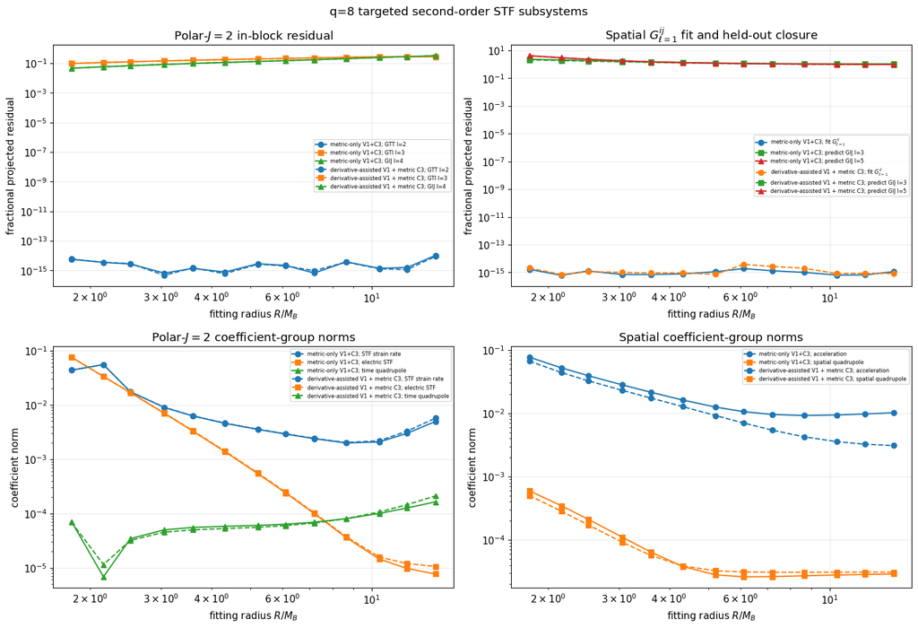

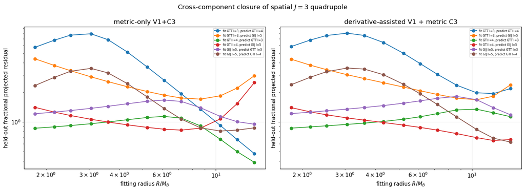

```python
fig_targeted_blocks, axes = plt.subplots(
    2, 2, figsize=(14.5, 10.0))
block_markers = ("o", "s", "^")

for baseline_index, baseline_name in enumerate(
        SECOND_ORDER_BASELINE_NAMES):
    for block_index, block in enumerate(
            POLAR_J2_BLOCKS):
        axes[0, 0].loglog(
            RADIUS_OVER_SMALL_MASS,
            POLAR_J2_BLOCK_RESIDUALS[
                baseline_index, :, block_index],
            marker=block_markers[block_index],
            linestyle=(
                "-" if baseline_index == 0 else "--"),
            color=f"C{block_index}",
            label=baseline_name + "; " + block_name(block),
        )

    axes[0, 1].loglog(
        RADIUS_OVER_SMALL_MASS,
        SPATIAL_ORTHOGONAL_IN_SAMPLE[
            baseline_index],
        "o-" if baseline_index == 0 else "o--",
        color=f"C{baseline_index}",
        label=baseline_name + r"; fit $G^{ij}_{\ell=1}$",
    )
    for block_index, block in enumerate(
            SPATIAL_CLOSURE_BLOCKS):
        axes[0, 1].loglog(
            RADIUS_OVER_SMALL_MASS,
            SPATIAL_ORTHOGONAL_CLOSURE[
                baseline_index, :, block_index],
            marker=block_markers[block_index + 1],
            linestyle=(
                "-" if baseline_index == 0 else "--"),
            color=f"C{block_index + 2}",
            label=baseline_name + "; predict "
            + block_name(block),
        )

    polar_group_slices = (
        slice(0, 5), slice(5, 10), slice(10, 15))
    polar_group_labels = (
        "STF strain rate", "electric STF",
        "time quadrupole")
    for group_index, (
            group_slice, group_label) in enumerate(zip(
                polar_group_slices,
                polar_group_labels)):
        axes[1, 0].loglog(
            RADIUS_OVER_SMALL_MASS,
            np.linalg.norm(
                POLAR_J2_ESTIMATES[
                    baseline_index, :, group_slice],
                axis=1,
            ),
            marker=block_markers[group_index],
            linestyle=(
                "-" if baseline_index == 0 else "--"),
            color=f"C{group_index}",
            label=baseline_name + "; " + group_label,
        )

    axes[1, 1].loglog(
        RADIUS_OVER_SMALL_MASS,
        np.linalg.norm(
            SPATIAL_ORTHOGONAL_ESTIMATES[
                baseline_index, :, :3],
            axis=1,
        ),
        "o-" if baseline_index == 0 else "o--",
        color="C0",
        label=baseline_name + "; acceleration",
    )
    axes[1, 1].loglog(
        RADIUS_OVER_SMALL_MASS,
        np.linalg.norm(
            SPATIAL_ORTHOGONAL_ESTIMATES[
                baseline_index, :, 3:],
            axis=1,
        ),
        "s-" if baseline_index == 0 else "s--",
        color="C1",
        label=baseline_name + "; spatial quadrupole",
    )

axes[0, 0].set_title(
    r"Polar-$J=2$ in-block residual")
axes[0, 0].set_ylabel(
    "fractional projected residual")
axes[0, 1].set_title(
    r"Spatial $G^{ij}_{\ell=1}$ fit and held-out closure")
axes[0, 1].set_ylabel(
    "fractional projected residual")
axes[1, 0].set_title(
    r"Polar-$J=2$ coefficient-group norms")
axes[1, 0].set_ylabel("coefficient norm")
axes[1, 1].set_title(
    "Spatial coefficient-group norms")
axes[1, 1].set_ylabel("coefficient norm")
for axis in axes.flat:
    axis.set_xlabel(r"fitting radius $R/M_B$")
    axis.legend(fontsize=6)
fig_targeted_blocks.suptitle(
    "q=8 targeted second-order STF subsystems")
fig_targeted_blocks.tight_layout()
fig_targeted_blocks.savefig(
    OUTPUT_DIRECTORY
    / "q8_t950_second_order_targeted_blocks.pdf")
fig_targeted_blocks.savefig(
    OUTPUT_DIRECTORY
    / "q8_t950_second_order_targeted_blocks.png",
    dpi=180,
)
plt.show()


fig_j3_closure, axes = plt.subplots(
    1, 2, figsize=(15.0, 5.5), sharey=True)
for baseline_index, (
        baseline_name, axis) in enumerate(zip(
            SECOND_ORDER_BASELINE_NAMES, axes)):
    for estimator_index, estimator_block in enumerate(
            SPATIAL_J3_BLOCKS):
        for prediction_index, prediction_block in enumerate(
                SPATIAL_J3_BLOCKS):
            if estimator_index == prediction_index:
                continue
            axis.loglog(
                RADIUS_OVER_SMALL_MASS,
                SPATIAL_J3_CLOSURE[
                    baseline_index,
                    :,
                    estimator_index,
                    prediction_index,
                ],
                marker="o",
                label=(
                    "fit " + block_name(estimator_block)
                    + ", predict "
                    + block_name(prediction_block)
                ),
            )
    axis.set_title(baseline_name)
    axis.set_xlabel(r"fitting radius $R/M_B$")
    axis.set_ylabel(
        "held-out fractional projected residual")
    axis.legend(fontsize=6)
fig_j3_closure.suptitle(
    r"Cross-component closure of spatial $J=3$ quadrupole")
fig_j3_closure.tight_layout()
fig_j3_closure.savefig(
    OUTPUT_DIRECTORY
    / "q8_t950_second_order_spatial_j3_closure.pdf")
fig_j3_closure.savefig(
    OUTPUT_DIRECTORY
    / "q8_t950_second_order_spatial_j3_closure.png",
    dpi=180,
)
plt.show()
```

### 13.2 Independent group fits and direct sensitivity

The STF tests expose consistency, but they do not directly measure how much each physical group changes the complete inverse metric. For every radius and first-order baseline we therefore perform a separate global least-squares fit for each of the eight second-order groups.

For each group we record:

- the reduction of the full ten-component surface candidate norm;
- the change in held-out interior error relative to the first-order-plus-(Q_{11}) model;
- the norm of the group's fitted interior contribution relative to the numerical non-Schwarzschild perturbation.

The groups are not combined in this test, so a useful group cannot borrow coefficients from another group to hide a closure failure.

```python
SECOND_ORDER_SENSITIVITY_GROUP_NAMES = tuple(
    FULL_GROUP_SLICES.keys())
SECOND_ORDER_SENSITIVITY_GROUP_SLICES = tuple(
    FULL_GROUP_SLICES.values())
number_of_sensitivity_groups = len(
    SECOND_ORDER_SENSITIVITY_GROUP_NAMES)

GROUP_ONLY_PARAMETERS = np.zeros((
    number_of_second_order_baselines,
    number_of_radii,
    number_of_sensitivity_groups,
    number_of_full_second_order_parameters,
))
GROUP_ONLY_SURFACE_RESIDUAL_FRACTION = np.empty((
    number_of_second_order_baselines,
    number_of_radii,
    number_of_sensitivity_groups,
))
GROUP_ONLY_SURFACE_REDUCTION = np.empty_like(
    GROUP_ONLY_SURFACE_RESIDUAL_FRACTION)
GROUP_ONLY_INTERIOR_ERROR = np.empty_like(
    GROUP_ONLY_SURFACE_RESIDUAL_FRACTION)
GROUP_ONLY_INTERIOR_ERROR_RATIO = np.empty_like(
    GROUP_ONLY_SURFACE_RESIDUAL_FRACTION)
GROUP_ONLY_INTERIOR_CONTRIBUTION = np.empty_like(
    GROUP_ONLY_SURFACE_RESIDUAL_FRACTION)
GROUP_ONLY_RANK = np.empty((
    number_of_radii,
    number_of_sensitivity_groups,
), dtype=int)
GROUP_ONLY_CONDITION = np.empty((
    number_of_radii,
    number_of_sensitivity_groups,
))

for radius_index in range(number_of_radii):
    columns = SURFACE_FULL_SECOND_ORDER_COLUMNS[
        radius_index]
    for group_index, group_slice in enumerate(
            SECOND_ORDER_SENSITIVITY_GROUP_SLICES):
        group_indices = np.arange(
            group_slice.start, group_slice.stop)
        surface_matrix = response_design(
            tuple(columns[index] for index in group_indices),
            lambda metric:
            metric_values_by_point(metric).ravel(),
        )
        _, group_rank, group_condition = (
            scaled_least_squares(
                surface_matrix,
                np.zeros(surface_matrix.shape[0]),
            )
        )
        GROUP_ONLY_RANK[
            radius_index, group_index] = group_rank
        GROUP_ONLY_CONDITION[
            radius_index, group_index] = group_condition

        interior_group_design = (
            INTERIOR_FULL_SECOND_ORDER_DESIGN[
                :, :, group_indices]
        )
        for baseline_index in range(
                number_of_second_order_baselines):
            candidate_values = metric_values_by_point(
                SECOND_ORDER_CANDIDATE_RESIDUALS[
                    baseline_index][radius_index]
            )
            estimate, _, _ = scaled_least_squares(
                surface_matrix,
                candidate_values.ravel(),
            )
            GROUP_ONLY_PARAMETERS[
                baseline_index,
                radius_index,
                group_index,
                group_indices,
            ] = estimate
            surface_remainder = (
                candidate_values.ravel()
                - surface_matrix @ estimate
            )
            surface_fraction = (
                np.linalg.norm(surface_remainder)
                / max(
                    np.linalg.norm(candidate_values),
                    1.0e-300,
                )
            )
            GROUP_ONLY_SURFACE_RESIDUAL_FRACTION[
                baseline_index,
                radius_index,
                group_index,
            ] = surface_fraction
            GROUP_ONLY_SURFACE_REDUCTION[
                baseline_index,
                radius_index,
                group_index,
            ] = max(0.0, 1.0 - surface_fraction)

            first_order_parameters = (
                SECOND_ORDER_FIRST_ORDER_BASELINES[
                    baseline_index, radius_index])
            first_order_values = np.einsum(
                "ncp,p->nc",
                INTERIOR_RESPONSE_DESIGN,
                first_order_parameters,
            )
            quadratic_values = metric_values_by_point(
                known_quadratic_first_order_source(
                    INTERIOR_LOCAL_POINTS,
                    first_order_parameters[1:4],
                    symmetric_matrix_from_six(
                        first_order_parameters[7:13]),
                    SMALL_BLACK_HOLE_MASS,
                )
            )
            quadratic_model = (
                INTERIOR_BACKGROUND_VALUES
                + first_order_values
                + quadratic_values
            )
            group_contribution = np.einsum(
                "ncp,p->nc",
                interior_group_design,
                estimate,
            )
            group_model = (
                quadratic_model + group_contribution)
            group_error = (
                np.linalg.norm(
                    INTERIOR_NUMERICAL_VALUES
                    - group_model)
                / np.linalg.norm(
                    INTERIOR_NUMERICAL_VALUES)
            )
            GROUP_ONLY_INTERIOR_ERROR[
                baseline_index,
                radius_index,
                group_index,
            ] = group_error
            GROUP_ONLY_INTERIOR_ERROR_RATIO[
                baseline_index,
                radius_index,
                group_index,
            ] = (
                group_error
                / COMPLETE_SECOND_ORDER_QUADRATIC_INTERIOR_ERROR[
                    baseline_index, radius_index]
            )
            GROUP_ONLY_INTERIOR_CONTRIBUTION[
                baseline_index,
                radius_index,
                group_index,
            ] = (
                np.linalg.norm(group_contribution)
                / np.linalg.norm(
                    INTERIOR_PERTURBATION_VALUES)
            )
```

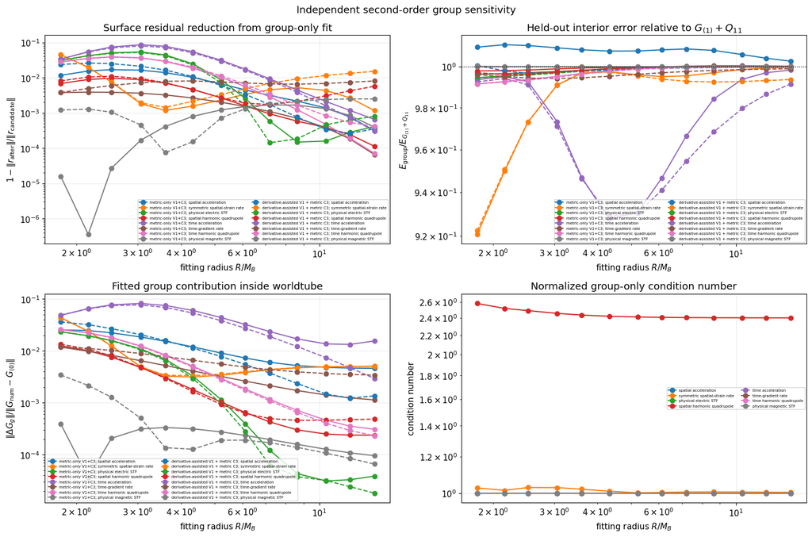

```
Best independent group fits

metric-only V1+C3
group                         best surface reduction  best interior ratio (radius)
spatial acceleration           1.6943e-02           1.0027e+00 (R=1.60)
symmetric spatial-strain rate  4.5108e-02           9.2077e-01 (R=0.20)
physical electric STF          5.3857e-02           9.9456e-01 (R=0.20)
spatial harmonic quadrupole    9.6352e-03           9.9789e-01 (R=0.20)
time acceleration              8.6576e-02           9.2764e-01 (R=0.48)
time-gradient rate             3.8942e-03           9.9628e-01 (R=0.20)
time harmonic quadrupole       3.9174e-02           9.9150e-01 (R=0.20)
physical magnetic STF          1.6903e-03           1.0000e+00 (R=0.80)

derivative-assisted V1 + metric C3
group                         best surface reduction  best interior ratio (radius)
spatial acceleration           2.6089e-02           9.9677e-01 (R=0.28)
symmetric spatial-strain rate  4.4917e-02           9.2241e-01 (R=0.20)
physical electric STF          5.2121e-02           9.9451e-01 (R=0.20)
spatial harmonic quadrupole    1.0978e-02           9.9618e-01 (R=0.24)
time acceleration              7.9845e-02           9.2910e-01 (R=0.48)
time-gradient rate             8.0931e-03           9.9420e-01 (R=0.34)
time harmonic quadrupole       3.8547e-02           9.9157e-01 (R=0.20)
physical magnetic STF          2.5041e-03           1.0000e+00 (R=0.40)
```

```python
fig_group_only, axes = plt.subplots(
    2, 2, figsize=(15.0, 10.0))
group_colors = [
    f"C{index}" for index in range(
        number_of_sensitivity_groups)]

for baseline_index, baseline_name in enumerate(
        SECOND_ORDER_BASELINE_NAMES):
    for group_index, group_name in enumerate(
            SECOND_ORDER_SENSITIVITY_GROUP_NAMES):
        linestyle = (
            "-" if baseline_index == 0 else "--")
        label = baseline_name + "; " + group_name
        axes[0, 0].loglog(
            RADIUS_OVER_SMALL_MASS,
            np.maximum(
                GROUP_ONLY_SURFACE_REDUCTION[
                    baseline_index, :, group_index],
                1.0e-12,
            ),
            linestyle=linestyle,
            marker="o",
            color=group_colors[group_index],
            label=label,
        )
        axes[0, 1].loglog(
            RADIUS_OVER_SMALL_MASS,
            GROUP_ONLY_INTERIOR_ERROR_RATIO[
                baseline_index, :, group_index],
            linestyle=linestyle,
            marker="o",
            color=group_colors[group_index],
            label=label,
        )
        axes[1, 0].loglog(
            RADIUS_OVER_SMALL_MASS,
            np.maximum(
                GROUP_ONLY_INTERIOR_CONTRIBUTION[
                    baseline_index, :, group_index],
                1.0e-15,
            ),
            linestyle=linestyle,
            marker="o",
            color=group_colors[group_index],
            label=label,
        )

for group_index, group_name in enumerate(
        SECOND_ORDER_SENSITIVITY_GROUP_NAMES):
    axes[1, 1].loglog(
        RADIUS_OVER_SMALL_MASS,
        GROUP_ONLY_CONDITION[:, group_index],
        "o-",
        color=group_colors[group_index],
        label=group_name,
    )

axes[0, 0].set_title(
    "Surface residual reduction from group-only fit")
axes[0, 0].set_ylabel(
    r"$1-\|r_{\rm after}\|/\|r_{\rm candidate}\|$")
axes[0, 1].set_title(
    r"Held-out interior error relative to $G_{(1)}+Q_{11}$")
axes[0, 1].set_ylabel(
    r"$E_{\rm group}/E_{G_{(1)}+Q_{11}}$")
axes[0, 1].axhline(
    1.0, color="black", linestyle=":", linewidth=1.0)
axes[1, 0].set_title(
    "Fitted group contribution inside worldtube")
axes[1, 0].set_ylabel(
    r"$\|\Delta G_g\|/\|G_{\rm num}-G_{(0)}\|$")
axes[1, 1].set_title(
    "Normalized group-only condition number")
axes[1, 1].set_ylabel("condition number")
for axis in axes.flat:
    axis.set_xlabel(r"fitting radius $R/M_B$")
    axis.legend(fontsize=5, ncol=2)
fig_group_only.suptitle(
    "Independent second-order group sensitivity")
fig_group_only.tight_layout()
fig_group_only.savefig(
    OUTPUT_DIRECTORY
    / "q8_t950_second_order_group_sensitivity.pdf")
fig_group_only.savefig(
    OUTPUT_DIRECTORY
    / "q8_t950_second_order_group_sensitivity.png",
    dpi=180,
)
plt.show()


print("\nBest independent group fits")
for baseline_index, baseline_name in enumerate(
        SECOND_ORDER_BASELINE_NAMES):
    print(f"\n{baseline_name}")
    print(
        "group                         "
        "best surface reduction  "
        "best interior ratio (radius)"
    )
    for group_index, group_name in enumerate(
            SECOND_ORDER_SENSITIVITY_GROUP_NAMES):
        surface_best = np.max(
            GROUP_ONLY_SURFACE_REDUCTION[
                baseline_index, :, group_index])
        interior_best_index = int(np.argmin(
            GROUP_ONLY_INTERIOR_ERROR_RATIO[
                baseline_index, :, group_index]))
        print(
            f"{group_name:29s} "
            f"{surface_best: .4e}          "
            f"{GROUP_ONLY_INTERIOR_ERROR_RATIO[baseline_index, interior_best_index, group_index]: .4e} "
            f"(R={RADIUS_TEST_VALUES[interior_best_index]:.2f})"
        )
```

### 13.3 Small fixed group combinations

The individual fits identify spatial-strain rate and time acceleration as the only groups with a several-percent interior effect. We now fit a short, predeclared list of combinations. This is not a search over the held-out points: every combination is chosen from the physical group structure before the interior errors are evaluated.

The comparison includes the two groups separately and together, two modest extensions, the complete polar-(J=2) family, and a globally balanced fit of all 43 columns. Unlike the triangular solve, each combination minimizes the full ten-component surface residual simultaneously.

```python
SECOND_ORDER_SUBSET_DEFINITIONS = (
    ("strain rate", (1,)),
    ("time acceleration", (4,)),
    ("strain rate + time acceleration", (1, 4)),
    (
        "strain rate + time acceleration + electric",
        (1, 2, 4),
    ),
    (
        "strain rate + time acceleration + time quadrupole",
        (1, 4, 6),
    ),
    (
        "polar J2 groups",
        (1, 2, 6),
    ),
    (
        "all 43, globally balanced",
        tuple(range(number_of_sensitivity_groups)),
    ),
)
SECOND_ORDER_SUBSET_NAMES = tuple(
    definition[0]
    for definition in SECOND_ORDER_SUBSET_DEFINITIONS)
SECOND_ORDER_SUBSET_PARAMETER_INDICES = tuple(
    np.concatenate([
        np.arange(
            SECOND_ORDER_SENSITIVITY_GROUP_SLICES[
                group_index].start,
            SECOND_ORDER_SENSITIVITY_GROUP_SLICES[
                group_index].stop,
        )
        for group_index in group_indices
    ])
    for _, group_indices
    in SECOND_ORDER_SUBSET_DEFINITIONS
)
number_of_second_order_subsets = len(
    SECOND_ORDER_SUBSET_NAMES)

SECOND_ORDER_SUBSET_PARAMETERS = np.zeros((
    number_of_second_order_baselines,
    number_of_radii,
    number_of_second_order_subsets,
    number_of_full_second_order_parameters,
))
SECOND_ORDER_SUBSET_SURFACE_FRACTION = np.empty((
    number_of_second_order_baselines,
    number_of_radii,
    number_of_second_order_subsets,
))
SECOND_ORDER_SUBSET_INTERIOR_ERROR = np.empty_like(
    SECOND_ORDER_SUBSET_SURFACE_FRACTION)
SECOND_ORDER_SUBSET_INTERIOR_RATIO = np.empty_like(
    SECOND_ORDER_SUBSET_SURFACE_FRACTION)
SECOND_ORDER_SUBSET_RANK = np.empty((
    number_of_radii,
    number_of_second_order_subsets,
), dtype=int)
SECOND_ORDER_SUBSET_CONDITION = np.empty((
    number_of_radii,
    number_of_second_order_subsets,
))

for radius_index in range(number_of_radii):
    columns = SURFACE_FULL_SECOND_ORDER_COLUMNS[
        radius_index]
    for subset_index, parameter_indices in enumerate(
            SECOND_ORDER_SUBSET_PARAMETER_INDICES):
        surface_matrix = response_design(
            tuple(
                columns[index]
                for index in parameter_indices),
            lambda metric:
            metric_values_by_point(metric).ravel(),
        )
        for baseline_index in range(
                number_of_second_order_baselines):
            candidate_values = metric_values_by_point(
                SECOND_ORDER_CANDIDATE_RESIDUALS[
                    baseline_index][radius_index]
            ).ravel()
            estimate, rank, condition = (
                scaled_least_squares(
                    surface_matrix, candidate_values))
            SECOND_ORDER_SUBSET_PARAMETERS[
                baseline_index,
                radius_index,
                subset_index,
                parameter_indices,
            ] = estimate
            SECOND_ORDER_SUBSET_RANK[
                radius_index, subset_index] = rank
            SECOND_ORDER_SUBSET_CONDITION[
                radius_index, subset_index] = condition
            SECOND_ORDER_SUBSET_SURFACE_FRACTION[
                baseline_index,
                radius_index,
                subset_index,
            ] = (
                np.linalg.norm(
                    candidate_values
                    - surface_matrix @ estimate)
                / max(
                    np.linalg.norm(candidate_values),
                    1.0e-300,
                )
            )

            first_order_parameters = (
                SECOND_ORDER_FIRST_ORDER_BASELINES[
                    baseline_index, radius_index])
            quadratic_model = (
                INTERIOR_BACKGROUND_VALUES
                + np.einsum(
                    "ncp,p->nc",
                    INTERIOR_RESPONSE_DESIGN,
                    first_order_parameters,
                )
                + metric_values_by_point(
                    known_quadratic_first_order_source(
                        INTERIOR_LOCAL_POINTS,
                        first_order_parameters[1:4],
                        symmetric_matrix_from_six(
                            first_order_parameters[7:13]),
                        SMALL_BLACK_HOLE_MASS,
                    )
                )
            )
            subset_prediction = np.einsum(
                "ncp,p->nc",
                INTERIOR_FULL_SECOND_ORDER_DESIGN[
                    :, :, parameter_indices],
                estimate,
            )
            subset_model = (
                quadratic_model + subset_prediction)
            subset_error = (
                np.linalg.norm(
                    INTERIOR_NUMERICAL_VALUES
                    - subset_model)
                / np.linalg.norm(
                    INTERIOR_NUMERICAL_VALUES)
            )
            SECOND_ORDER_SUBSET_INTERIOR_ERROR[
                baseline_index,
                radius_index,
                subset_index,
            ] = subset_error
            SECOND_ORDER_SUBSET_INTERIOR_RATIO[
                baseline_index,
                radius_index,
                subset_index,
            ] = (
                subset_error
                / COMPLETE_SECOND_ORDER_QUADRATIC_INTERIOR_ERROR[
                    baseline_index, radius_index]
            )
```

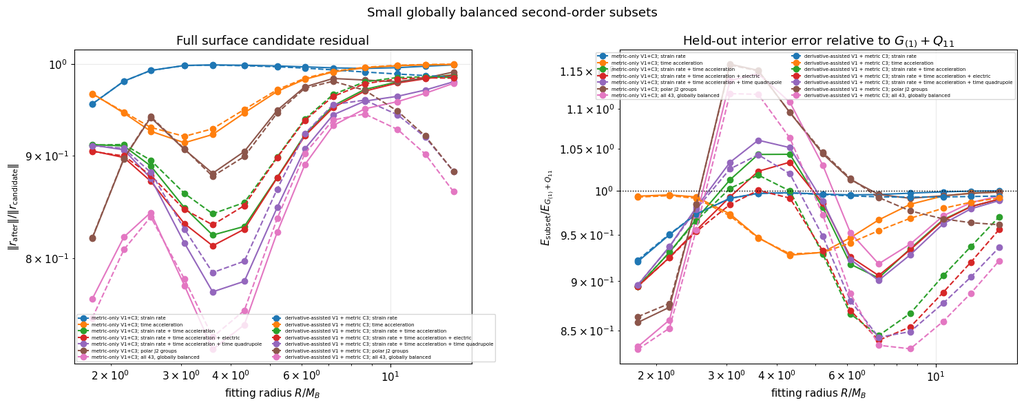

```
Fixed second-order subset comparison

metric-only V1+C3
strain rate                                          best ratio=9.207652e-01 at R=0.20; surface=9.548924e-01
time acceleration                                    best ratio=9.276353e-01 at R=0.48; surface=9.453050e-01
strain rate + time acceleration                      best ratio=8.942634e-01 at R=0.20; surface=9.115270e-01
strain rate + time acceleration + electric           best ratio=8.946292e-01 at R=0.20; surface=9.049698e-01
strain rate + time acceleration + time quadrupole    best ratio=8.959614e-01 at R=0.20; surface=9.109760e-01
polar J2 groups                                      best ratio=8.578477e-01 at R=0.20; surface=8.184718e-01
all 43, globally balanced                            best ratio=8.339885e-01 at R=0.20; surface=7.634292e-01

derivative-assisted V1 + metric C3
strain rate                                          best ratio=9.224070e-01 at R=0.20; surface=9.550834e-01
time acceleration                                    best ratio=9.290970e-01 at R=0.48; surface=9.490115e-01
strain rate + time acceleration                      best ratio=8.448107e-01 at R=0.80; surface=9.654290e-01
strain rate + time acceleration + electric           best ratio=8.401913e-01 at R=0.80; surface=9.632857e-01
strain rate + time acceleration + time quadrupole    best ratio=8.431703e-01 at R=0.80; surface=9.543580e-01
polar J2 groups                                      best ratio=8.635991e-01 at R=0.20; surface=8.190154e-01
all 43, globally balanced                            best ratio=8.313881e-01 at R=0.20; surface=7.467918e-01
```

```python
fig_subset_comparison, axes = plt.subplots(
    1, 2, figsize=(15.0, 6.0))
subset_colors = [
    f"C{index}" for index in range(
        number_of_second_order_subsets)]
for baseline_index, baseline_name in enumerate(
        SECOND_ORDER_BASELINE_NAMES):
    for subset_index, subset_name in enumerate(
            SECOND_ORDER_SUBSET_NAMES):
        linestyle = (
            "-" if baseline_index == 0 else "--")
        label = baseline_name + "; " + subset_name
        axes[0].loglog(
            RADIUS_OVER_SMALL_MASS,
            SECOND_ORDER_SUBSET_SURFACE_FRACTION[
                baseline_index, :, subset_index],
            marker="o",
            linestyle=linestyle,
            color=subset_colors[subset_index],
            label=label,
        )
        axes[1].loglog(
            RADIUS_OVER_SMALL_MASS,
            SECOND_ORDER_SUBSET_INTERIOR_RATIO[
                baseline_index, :, subset_index],
            marker="o",
            linestyle=linestyle,
            color=subset_colors[subset_index],
            label=label,
        )
axes[0].set_title(
    "Full surface candidate residual")
axes[0].set_ylabel(
    r"$\|r_{\rm after}\|/\|r_{\rm candidate}\|$")
axes[1].set_title(
    r"Held-out interior error relative to $G_{(1)}+Q_{11}$")
axes[1].set_ylabel(
    r"$E_{\rm subset}/E_{G_{(1)}+Q_{11}}$")
axes[1].axhline(
    1.0, color="black", linestyle=":",
    linewidth=1.0)
for axis in axes:
    axis.set_xlabel(r"fitting radius $R/M_B$")
    axis.legend(fontsize=5, ncol=2)
fig_subset_comparison.suptitle(
    "Small globally balanced second-order subsets")
fig_subset_comparison.tight_layout()
fig_subset_comparison.savefig(
    OUTPUT_DIRECTORY
    / "q8_t950_second_order_subset_comparison.pdf")
fig_subset_comparison.savefig(
    OUTPUT_DIRECTORY
    / "q8_t950_second_order_subset_comparison.png",
    dpi=180,
)
plt.show()


print("\nFixed second-order subset comparison")
for baseline_index, baseline_name in enumerate(
        SECOND_ORDER_BASELINE_NAMES):
    print(f"\n{baseline_name}")
    for subset_index, subset_name in enumerate(
            SECOND_ORDER_SUBSET_NAMES):
        best_index = int(np.argmin(
            SECOND_ORDER_SUBSET_INTERIOR_RATIO[
                baseline_index, :, subset_index]))
        print(
            f"{subset_name:52s} "
            f"best ratio="
            f"{SECOND_ORDER_SUBSET_INTERIOR_RATIO[baseline_index, best_index, subset_index]:.6e} "
            f"at R={RADIUS_TEST_VALUES[best_index]:.2f}; "
            f"surface="
            f"{SECOND_ORDER_SUBSET_SURFACE_FRACTION[baseline_index, best_index, subset_index]:.6e}"
        )
```

### 13.4 Direct ablation of the complete triangular fit

The independent fits ask what each group can do alone. The complementary ablation test keeps the complete triangular coefficients fixed and removes one group without refitting the others. The contribution norm measures sensitivity; the error ratio [ E_{-g}/E_{\rm full} ] measures utility. Values above one mean the group improves the interior prediction, values near one mean it is irrelevant, and values below one mean that removing the group makes the prediction better.

```python
COMPLETE_ABLATION_CONTRIBUTION = np.empty((
    number_of_second_order_baselines,
    number_of_radii,
    number_of_sensitivity_groups,
))
COMPLETE_ABLATION_ERROR_RATIO = np.empty_like(
    COMPLETE_ABLATION_CONTRIBUTION)

for baseline_index in range(
        number_of_second_order_baselines):
    for radius_index in range(number_of_radii):
        first_order_parameters = (
            SECOND_ORDER_FIRST_ORDER_BASELINES[
                baseline_index, radius_index])
        first_order_values = np.einsum(
            "ncp,p->nc",
            INTERIOR_RESPONSE_DESIGN,
            first_order_parameters,
        )
        quadratic_values = metric_values_by_point(
            known_quadratic_first_order_source(
                INTERIOR_LOCAL_POINTS,
                first_order_parameters[1:4],
                symmetric_matrix_from_six(
                    first_order_parameters[7:13]),
                SMALL_BLACK_HOLE_MASS,
            )
        )
        complete_second_order_values = np.einsum(
            "ncp,p->nc",
            INTERIOR_FULL_SECOND_ORDER_DESIGN,
            COMPLETE_SECOND_ORDER_PARAMETERS[
                baseline_index, radius_index],
        )
        full_model = (
            INTERIOR_BACKGROUND_VALUES
            + first_order_values
            + quadratic_values
            + complete_second_order_values
        )
        full_error = np.linalg.norm(
            INTERIOR_NUMERICAL_VALUES - full_model)

        for group_index, group_slice in enumerate(
                SECOND_ORDER_SENSITIVITY_GROUP_SLICES):
            group_indices = np.arange(
                group_slice.start, group_slice.stop)
            group_contribution = np.einsum(
                "ncp,p->nc",
                INTERIOR_FULL_SECOND_ORDER_DESIGN[
                    :, :, group_indices],
                COMPLETE_SECOND_ORDER_PARAMETERS[
                    baseline_index,
                    radius_index,
                    group_indices,
                ],
            )
            ablated_model = (
                full_model - group_contribution)
            COMPLETE_ABLATION_CONTRIBUTION[
                baseline_index,
                radius_index,
                group_index,
            ] = (
                np.linalg.norm(group_contribution)
                / np.linalg.norm(
                    INTERIOR_PERTURBATION_VALUES)
            )
            COMPLETE_ABLATION_ERROR_RATIO[
                baseline_index,
                radius_index,
                group_index,
            ] = (
                np.linalg.norm(
                    INTERIOR_NUMERICAL_VALUES
                    - ablated_model)
                / full_error
            )
```

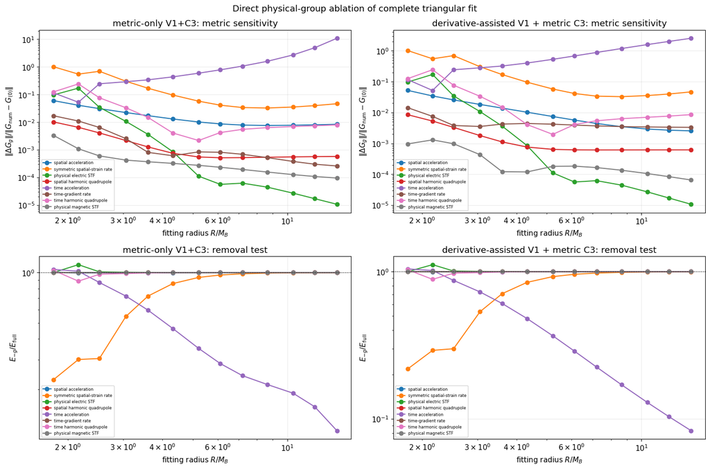

```python
fig_ablation_scan, axes = plt.subplots(
    2, 2, figsize=(15.0, 10.0))
for baseline_index, baseline_name in enumerate(
        SECOND_ORDER_BASELINE_NAMES):
    contribution_axis = axes[0, baseline_index]
    error_axis = axes[1, baseline_index]
    for group_index, group_name in enumerate(
            SECOND_ORDER_SENSITIVITY_GROUP_NAMES):
        contribution_axis.loglog(
            RADIUS_OVER_SMALL_MASS,
            np.maximum(
                COMPLETE_ABLATION_CONTRIBUTION[
                    baseline_index, :, group_index],
                1.0e-15,
            ),
            "o-",
            color=group_colors[group_index],
            label=group_name,
        )
        error_axis.loglog(
            RADIUS_OVER_SMALL_MASS,
            COMPLETE_ABLATION_ERROR_RATIO[
                baseline_index, :, group_index],
            "o-",
            color=group_colors[group_index],
            label=group_name,
        )
    contribution_axis.set_title(
        baseline_name + ": metric sensitivity")
    contribution_axis.set_ylabel(
        r"$\|\Delta G_g\|/\|G_{\rm num}-G_{(0)}\|$")
    error_axis.set_title(
        baseline_name + ": removal test")
    error_axis.set_ylabel(r"$E_{-g}/E_{\rm full}$")
    error_axis.axhline(
        1.0, color="black", linestyle=":",
        linewidth=1.0)
    for axis in (contribution_axis, error_axis):
        axis.set_xlabel(r"fitting radius $R/M_B$")
        axis.legend(fontsize=6)
fig_ablation_scan.suptitle(
    "Direct physical-group ablation of complete triangular fit")
fig_ablation_scan.tight_layout()
fig_ablation_scan.savefig(
    OUTPUT_DIRECTORY
    / "q8_t950_second_order_group_ablation.pdf")
fig_ablation_scan.savefig(
    OUTPUT_DIRECTORY
    / "q8_t950_second_order_group_ablation.png",
    dpi=180,
)
plt.show()
```

### Reading the sensitivity analysis

The three diagnostics must be read together. A large contribution norm means the metric is sensitive to the fitted coefficient, not that the coefficient is accurate. A strong independent surface reduction with an interior error ratio above one indicates overfitting at the worldtube. Conversely, a group with a modest surface effect but a stable interior improvement may be a better candidate for the matching subsystem.

The irreducible cross-block plots are the strictest recovery test: a block is credible only if its coefficients are reasonably stable with radius and predict multipoles that were not included in the fit.

On the q=8 slice, the sensitivity is concentrated but the result is more promising than the triangular solve suggested:

- fitted independently, spatial-strain rate lowers the best interior error by about (7.8%)--(7.9%), and time acceleration by about (7.1%)--(7.2%);
- fitting those two groups jointly lowers it by (10.6%) for the metric-only baseline and by as much as (15.5%) for the derivative-assisted baseline;
- electric STF, time quadrupole, acceleration, time-gradient rate, and spatial quadrupole each change the best group-only interior error by less than one percent; the magnetic STF response is numerically irrelevant at this accuracy;
- adding electric STF or time quadrupole to the strain-rate/time-acceleration pair does not improve its best small-radius result.

By contrast, the spatial (G^{ij}_{\ell=1}) subsystem is not validated. It fits its square estimator block to roundoff, but the held-out (\ell=3,5) residuals remain near or above unity. The three independent spatial-(J=3) estimators also fail to give uniformly good cross-component closure. These spatial quadrupole coefficients should therefore not yet be used as individually recovered quantities.

A globally balanced 43-column fit reaches the lowest interior error, (3.01\times10^{-2}), without the catastrophic (G^{Ti}) amplification of the triangular solve. This shows that second-order response directions do contain useful aggregate information, but it does not establish that all 43 coefficients are separately resolved. The conservative provisional subsystem is therefore the spatial-strain rate plus time acceleration; the polar-(J=2) system is the next block worth testing with radial derivatives.

## 14. Joint value-and-radial-derivative fits at second order

We now add [ {\cal D}G^{ab}\equiv R n^i\partial_iG^{ab} ] to the two provisional second-order systems:

1. symmetric spatial-strain rate plus time acceleration;
2. the fifteen-parameter polar-(J=2) subsystem.

No new unknown is introduced. The same coefficient must multiply a response (\mathcal R_A(R)) in the metric equation and (R\partial_R\mathcal R_A(R)) in the derivative equation. The numerical derivative comes directly from the evolved (\Phi_{iab}). Only the analytic background, first-order responses, quadratic source, and second-order responses are differentiated with the converged five-point radial stencil.

For derivative weight (w_D), the joint system is [ \begin{pmatrix} A\\ w_D A_D \end{pmatrix}p \simeq \begin{pmatrix} d\\ w_D d_D \end{pmatrix}. ] We scan the same weights used at first order. Metric values at the fixed random interior points remain completely held out.

```python
SECOND_ORDER_DERIVATIVE_WEIGHTS = (
    JOINT_DERIVATIVE_WEIGHTS.copy())
SECOND_ORDER_DERIVATIVE_WEIGHT_LABELS = (
    JOINT_WEIGHT_LABELS)


def analytic_full_second_order_response_derivatives(
        radius, relative_step=1.0e-4):
    step = relative_step * radius
    samples = [
        full_response_columns_at_points(
            (radius + offset * step) * DIRECTIONS,
            SMALL_BLACK_HOLE_MASS,
        )
        for offset in (-2.0, -1.0, 1.0, 2.0)
    ]
    return tuple(
        tuple(
            (
                samples[0][parameter][component]
                - 8.0 * samples[1][parameter][component]
                + 8.0 * samples[2][parameter][component]
                - samples[3][parameter][component]
            ) / (12.0 * step)
            for component in range(3)
        )
        for parameter in range(
            number_of_full_second_order_parameters)
    )


def analytic_polar_j2_response_derivatives(
        radius, relative_step=1.0e-4):
    step = relative_step * radius
    samples = [
        polar_j2_response_columns(
            radius + offset * step)
        for offset in (-2.0, -1.0, 1.0, 2.0)
    ]
    return tuple(
        tuple(
            (
                samples[0][parameter][component]
                - 8.0 * samples[1][parameter][component]
                + 8.0 * samples[2][parameter][component]
                - samples[3][parameter][component]
            ) / (12.0 * step)
            for component in range(3)
        )
        for parameter in range(15)
    )


def polar_j2_response_columns_at_points(points):
    points = np.asarray(points)
    radii = np.linalg.norm(points, axis=1)
    directions = points / radii[:, None]
    builders = []
    for basis in STF_BASIS:
        builders.append(
            lambda radius, direction, basis=basis:
            strain_rate_response_at_direction(
                SMALL_BLACK_HOLE_MASS,
                radius,
                direction,
                basis,
            )
        )
    for basis in STF_BASIS:
        builders.append(
            lambda radius, direction, basis=basis:
            electric_response_at_direction(
                SMALL_BLACK_HOLE_MASS,
                radius,
                direction,
                basis,
            )
        )
    for basis in STF_BASIS:
        builders.append(
            lambda radius, direction, basis=basis:
            time_quadrupole_response_at_direction(
                SMALL_BLACK_HOLE_MASS,
                radius,
                direction,
                basis,
            )
        )
    return tuple(
        matrix_to_metric_tuple(np.asarray([
            builder(radius, direction)
            for radius, direction in zip(
                radii, directions)
        ]))
        for builder in builders
    )


SECOND_ORDER_DERIVATIVE_CANDIDATES = [
    [None for _ in RADIUS_TEST_VALUES]
    for _ in SECOND_ORDER_BASELINE_NAMES
]
SURFACE_FULL_SECOND_ORDER_DERIVATIVES = []
SURFACE_POLAR_J2_DERIVATIVES = []
SECOND_ORDER_DERIVATIVE_STENCIL_ERROR = np.empty(
    number_of_radii)

for radius_index, radius in enumerate(
        RADIUS_TEST_VALUES):
    numerical_derivative = metric_tuple_from_matrix(
        NUMERICAL_RADIAL_DERIVATIVE[radius_index])
    background_derivative = (
        analytic_background_radial_derivative(radius))
    first_order_derivatives = (
        analytic_response_radial_derivatives(radius))
    full_second_order_derivatives = (
        analytic_full_second_order_response_derivatives(
            radius))
    polar_derivatives = (
        analytic_polar_j2_response_derivatives(radius))
    SURFACE_FULL_SECOND_ORDER_DERIVATIVES.append(
        tuple(
            tuple(radius * component for component in column)
            for column in full_second_order_derivatives
        )
    )
    SURFACE_POLAR_J2_DERIVATIVES.append(
        tuple(
            tuple(radius * component for component in column)
            for column in polar_derivatives
        )
    )

    half_step = (
        analytic_full_second_order_response_derivatives(
            radius, relative_step=5.0e-5))
    full_values = np.concatenate([
        metric_values_by_point(column).ravel()
        for column in full_second_order_derivatives
    ])
    half_values = np.concatenate([
        metric_values_by_point(column).ravel()
        for column in half_step
    ])
    SECOND_ORDER_DERIVATIVE_STENCIL_ERROR[
        radius_index] = (
            np.linalg.norm(full_values - half_values)
            / np.linalg.norm(half_values)
        )

    for baseline_index in range(
            number_of_second_order_baselines):
        first_order_parameters = (
            SECOND_ORDER_FIRST_ORDER_BASELINES[
                baseline_index, radius_index])
        first_order_derivative_prediction = (
            metric_linear_combination(
                first_order_derivatives,
                first_order_parameters,
            )
        )
        quadratic_derivative = (
            five_point_radial_derivative(
                lambda points:
                known_quadratic_first_order_source(
                    points,
                    first_order_parameters[1:4],
                    symmetric_matrix_from_six(
                        first_order_parameters[7:13]),
                    SMALL_BLACK_HOLE_MASS,
                ),
                radius,
            )
        )
        SECOND_ORDER_DERIVATIVE_CANDIDATES[
            baseline_index][radius_index] = tuple(
                radius * (
                    numerical
                    - background
                    - first_order
                    - quadratic
                )
                for numerical, background, first_order, quadratic
                in zip(
                    numerical_derivative,
                    background_derivative,
                    first_order_derivative_prediction,
                    quadratic_derivative,
                )
        )

print(
    "second-order response derivative stencil check:",
    f"max={SECOND_ORDER_DERIVATIVE_STENCIL_ERROR.max():.3e}",
)
assert (
    SECOND_ORDER_DERIVATIVE_STENCIL_ERROR.max()
    < 2.0e-9
)
```

```
second-order response derivative stencil check: max=4.305e-12
```

```python
PROVISIONAL_SECOND_ORDER_PARAMETER_INDICES = np.r_[
    np.arange(
        FULL_GROUP_SLICES[
            "symmetric spatial-strain rate"].start,
        FULL_GROUP_SLICES[
            "symmetric spatial-strain rate"].stop,
    ),
    np.arange(
        FULL_GROUP_SLICES[
            "time acceleration"].start,
        FULL_GROUP_SLICES[
            "time acceleration"].stop,
    ),
]
number_of_second_order_weights = len(
    SECOND_ORDER_DERIVATIVE_WEIGHTS)

SECOND_ORDER_JOINT_SUBSET_PARAMETERS = np.zeros((
    number_of_second_order_baselines,
    number_of_second_order_weights,
    number_of_radii,
    number_of_full_second_order_parameters,
))
SECOND_ORDER_JOINT_SUBSET_VALUE_RESIDUAL = np.empty((
    number_of_second_order_baselines,
    number_of_second_order_weights,
    number_of_radii,
))
SECOND_ORDER_JOINT_SUBSET_DERIVATIVE_RESIDUAL = (
    np.empty_like(
        SECOND_ORDER_JOINT_SUBSET_VALUE_RESIDUAL)
)
SECOND_ORDER_JOINT_SUBSET_INTERIOR_ERROR = np.empty_like(
    SECOND_ORDER_JOINT_SUBSET_VALUE_RESIDUAL)
SECOND_ORDER_JOINT_SUBSET_CONDITION = np.empty_like(
    SECOND_ORDER_JOINT_SUBSET_VALUE_RESIDUAL)

SECOND_ORDER_JOINT_POLAR_PARAMETERS = np.empty((
    number_of_second_order_baselines,
    number_of_second_order_weights,
    number_of_radii,
    15,
))
SECOND_ORDER_JOINT_POLAR_VALUE_RESIDUAL = np.empty((
    number_of_second_order_baselines,
    number_of_second_order_weights,
    number_of_radii,
))
SECOND_ORDER_JOINT_POLAR_DERIVATIVE_RESIDUAL = (
    np.empty_like(
        SECOND_ORDER_JOINT_POLAR_VALUE_RESIDUAL)
)
SECOND_ORDER_JOINT_POLAR_INTERIOR_ERROR = np.empty_like(
    SECOND_ORDER_JOINT_POLAR_VALUE_RESIDUAL)
SECOND_ORDER_JOINT_POLAR_CONDITION = np.empty_like(
    SECOND_ORDER_JOINT_POLAR_VALUE_RESIDUAL)

INTERIOR_POLAR_J2_COLUMNS = (
    polar_j2_response_columns_at_points(
        INTERIOR_LOCAL_POINTS))
INTERIOR_POLAR_J2_DESIGN = np.stack([
    metric_values_by_point(column)
    for column in INTERIOR_POLAR_J2_COLUMNS
], axis=-1)

for radius_index, radius in enumerate(
        RADIUS_TEST_VALUES):
    full_columns = SURFACE_FULL_SECOND_ORDER_COLUMNS[
        radius_index]
    full_derivatives = (
        SURFACE_FULL_SECOND_ORDER_DERIVATIVES[
            radius_index])
    subset_value_matrix = response_design(
        tuple(
            full_columns[index]
            for index in
            PROVISIONAL_SECOND_ORDER_PARAMETER_INDICES),
        lambda metric:
        metric_values_by_point(metric).ravel(),
    )
    subset_derivative_matrix = response_design(
        tuple(
            full_derivatives[index]
            for index in
            PROVISIONAL_SECOND_ORDER_PARAMETER_INDICES),
        lambda metric:
        metric_values_by_point(metric).ravel(),
    )

    polar_columns = polar_j2_response_columns(radius)
    polar_derivatives = (
        SURFACE_POLAR_J2_DERIVATIVES[radius_index])
    polar_value_matrix = projected_design(
        polar_columns, POLAR_J2_BLOCKS)
    polar_derivative_matrix = projected_design(
        polar_derivatives, POLAR_J2_BLOCKS)

    for baseline_index in range(
            number_of_second_order_baselines):
        candidate = SECOND_ORDER_CANDIDATE_RESIDUALS[
            baseline_index][radius_index]
        derivative_candidate = (
            SECOND_ORDER_DERIVATIVE_CANDIDATES[
                baseline_index][radius_index])
        subset_value_data = (
            metric_values_by_point(candidate).ravel())
        subset_derivative_data = (
            metric_values_by_point(
                derivative_candidate).ravel())
        polar_value_data = projected_data(
            candidate, POLAR_J2_BLOCKS)
        polar_derivative_data = projected_data(
            derivative_candidate, POLAR_J2_BLOCKS)

        first_order_parameters = (
            SECOND_ORDER_FIRST_ORDER_BASELINES[
                baseline_index, radius_index])
        quadratic_model = (
            INTERIOR_BACKGROUND_VALUES
            + np.einsum(
                "ncp,p->nc",
                INTERIOR_RESPONSE_DESIGN,
                first_order_parameters,
            )
            + metric_values_by_point(
                known_quadratic_first_order_source(
                    INTERIOR_LOCAL_POINTS,
                    first_order_parameters[1:4],
                    symmetric_matrix_from_six(
                        first_order_parameters[7:13]),
                    SMALL_BLACK_HOLE_MASS,
                )
            )
        )

        for weight_index, derivative_weight in enumerate(
                SECOND_ORDER_DERIVATIVE_WEIGHTS):
            subset_matrix = np.concatenate((
                subset_value_matrix,
                derivative_weight
                * subset_derivative_matrix,
            ), axis=0)
            subset_data = np.concatenate((
                subset_value_data,
                derivative_weight
                * subset_derivative_data,
            ))
            subset_estimate, subset_rank, subset_condition = (
                scaled_least_squares(
                    subset_matrix, subset_data))
            assert subset_rank == len(
                PROVISIONAL_SECOND_ORDER_PARAMETER_INDICES)
            SECOND_ORDER_JOINT_SUBSET_PARAMETERS[
                baseline_index,
                weight_index,
                radius_index,
                PROVISIONAL_SECOND_ORDER_PARAMETER_INDICES,
            ] = subset_estimate
            SECOND_ORDER_JOINT_SUBSET_CONDITION[
                baseline_index,
                weight_index,
                radius_index,
            ] = subset_condition
            SECOND_ORDER_JOINT_SUBSET_VALUE_RESIDUAL[
                baseline_index,
                weight_index,
                radius_index,
            ] = (
                np.linalg.norm(
                    subset_value_data
                    - subset_value_matrix
                    @ subset_estimate)
                / np.linalg.norm(subset_value_data)
            )
            SECOND_ORDER_JOINT_SUBSET_DERIVATIVE_RESIDUAL[
                baseline_index,
                weight_index,
                radius_index,
            ] = (
                np.linalg.norm(
                    subset_derivative_data
                    - subset_derivative_matrix
                    @ subset_estimate)
                / np.linalg.norm(
                    subset_derivative_data)
            )
            subset_model = (
                quadratic_model
                + np.einsum(
                    "ncp,p->nc",
                    INTERIOR_FULL_SECOND_ORDER_DESIGN[
                        :,
                        :,
                        PROVISIONAL_SECOND_ORDER_PARAMETER_INDICES,
                    ],
                    subset_estimate,
                )
            )
            SECOND_ORDER_JOINT_SUBSET_INTERIOR_ERROR[
                baseline_index,
                weight_index,
                radius_index,
            ] = (
                np.linalg.norm(
                    INTERIOR_NUMERICAL_VALUES
                    - subset_model)
                / np.linalg.norm(
                    INTERIOR_NUMERICAL_VALUES)
            )

            polar_matrix = np.concatenate((
                polar_value_matrix,
                derivative_weight
                * polar_derivative_matrix,
            ), axis=0)
            polar_data = np.concatenate((
                polar_value_data,
                derivative_weight
                * polar_derivative_data,
            ))
            polar_estimate, polar_rank, polar_condition = (
                scaled_least_squares(
                    polar_matrix, polar_data))
            assert polar_rank == 15
            SECOND_ORDER_JOINT_POLAR_PARAMETERS[
                baseline_index,
                weight_index,
                radius_index,
            ] = polar_estimate
            SECOND_ORDER_JOINT_POLAR_CONDITION[
                baseline_index,
                weight_index,
                radius_index,
            ] = polar_condition
            SECOND_ORDER_JOINT_POLAR_VALUE_RESIDUAL[
                baseline_index,
                weight_index,
                radius_index,
            ] = (
                np.linalg.norm(
                    polar_value_data
                    - polar_value_matrix @ polar_estimate)
                / np.linalg.norm(polar_value_data)
            )
            SECOND_ORDER_JOINT_POLAR_DERIVATIVE_RESIDUAL[
                baseline_index,
                weight_index,
                radius_index,
            ] = (
                np.linalg.norm(
                    polar_derivative_data
                    - polar_derivative_matrix @ polar_estimate)
                / np.linalg.norm(
                    polar_derivative_data)
            )
            polar_model = (
                quadratic_model
                + np.einsum(
                    "ncp,p->nc",
                    INTERIOR_POLAR_J2_DESIGN,
                    polar_estimate,
                )
            )
            SECOND_ORDER_JOINT_POLAR_INTERIOR_ERROR[
                baseline_index,
                weight_index,
                radius_index,
            ] = (
                np.linalg.norm(
                    INTERIOR_NUMERICAL_VALUES
                    - polar_model)
                / np.linalg.norm(
                    INTERIOR_NUMERICAL_VALUES)
            )

# Weight zero must reproduce the corresponding value-only fits.
subset_definition_index = (
    SECOND_ORDER_SUBSET_NAMES.index(
        "strain rate + time acceleration"))
np.testing.assert_allclose(
    SECOND_ORDER_JOINT_SUBSET_INTERIOR_ERROR[:, 0],
    SECOND_ORDER_SUBSET_INTERIOR_ERROR[
        :, :, subset_definition_index],
    rtol=3.0e-12,
    atol=3.0e-13,
)
np.testing.assert_allclose(
    SECOND_ORDER_JOINT_POLAR_PARAMETERS[:, 0],
    POLAR_J2_ESTIMATES,
    rtol=3.0e-11,
    atol=3.0e-12,
)
```

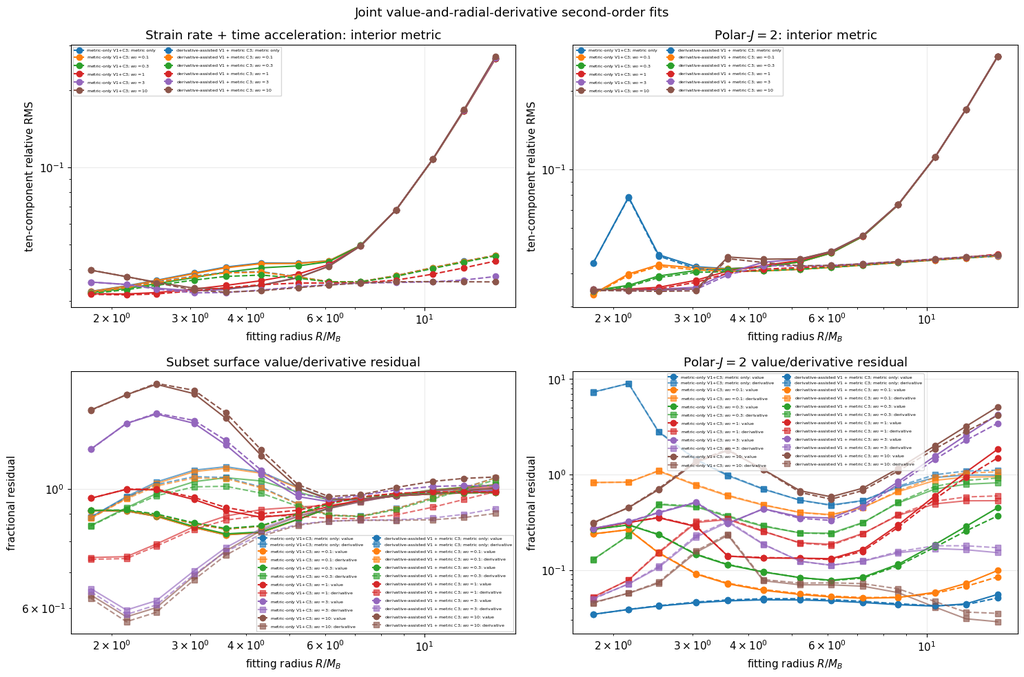

```
Second-order joint radial-derivative summary

metric-only V1+C3
  strain rate + time acceleration     : interior=3.194238e-02, weight=1, R=0.240
  polar J2                            : interior=3.347148e-02, weight=0.1, R=0.200

derivative-assisted V1 + metric C3
  strain rate + time acceleration     : interior=3.166491e-02, weight=1, R=0.240
  polar J2                            : interior=3.320908e-02, weight=0.1, R=0.200
```

```python
fig_second_order_joint_derivative, axes = plt.subplots(
    2, 2, figsize=(15.0, 10.0))
weight_colors = [
    f"C{index}" for index in range(
        number_of_second_order_weights)]

for baseline_index, baseline_name in enumerate(
        SECOND_ORDER_BASELINE_NAMES):
    linestyle = (
        "-" if baseline_index == 0 else "--")
    for weight_index, weight_label in enumerate(
            SECOND_ORDER_DERIVATIVE_WEIGHT_LABELS):
        label = baseline_name + "; " + weight_label
        axes[0, 0].loglog(
            RADIUS_OVER_SMALL_MASS,
            SECOND_ORDER_JOINT_SUBSET_INTERIOR_ERROR[
                baseline_index, weight_index],
            marker="o",
            linestyle=linestyle,
            color=weight_colors[weight_index],
            label=label,
        )
        axes[0, 1].loglog(
            RADIUS_OVER_SMALL_MASS,
            SECOND_ORDER_JOINT_POLAR_INTERIOR_ERROR[
                baseline_index, weight_index],
            marker="o",
            linestyle=linestyle,
            color=weight_colors[weight_index],
            label=label,
        )
        axes[1, 0].loglog(
            RADIUS_OVER_SMALL_MASS,
            SECOND_ORDER_JOINT_SUBSET_VALUE_RESIDUAL[
                baseline_index, weight_index],
            marker="o",
            linestyle=linestyle,
            color=weight_colors[weight_index],
            label=label + ": value",
        )
        axes[1, 0].loglog(
            RADIUS_OVER_SMALL_MASS,
            SECOND_ORDER_JOINT_SUBSET_DERIVATIVE_RESIDUAL[
                baseline_index, weight_index],
            marker="s",
            linestyle=linestyle,
            color=weight_colors[weight_index],
            alpha=0.65,
            label=label + ": derivative",
        )
        axes[1, 1].loglog(
            RADIUS_OVER_SMALL_MASS,
            SECOND_ORDER_JOINT_POLAR_VALUE_RESIDUAL[
                baseline_index, weight_index],
            marker="o",
            linestyle=linestyle,
            color=weight_colors[weight_index],
            label=label + ": value",
        )
        axes[1, 1].loglog(
            RADIUS_OVER_SMALL_MASS,
            SECOND_ORDER_JOINT_POLAR_DERIVATIVE_RESIDUAL[
                baseline_index, weight_index],
            marker="s",
            linestyle=linestyle,
            color=weight_colors[weight_index],
            alpha=0.65,
            label=label + ": derivative",
        )

axes[0, 0].set_title(
    "Strain rate + time acceleration: interior metric")
axes[0, 0].set_ylabel(
    "ten-component relative RMS")
axes[0, 1].set_title(
    r"Polar-$J=2$: interior metric")
axes[0, 1].set_ylabel(
    "ten-component relative RMS")
axes[1, 0].set_title(
    "Subset surface value/derivative residual")
axes[1, 0].set_ylabel("fractional residual")
axes[1, 1].set_title(
    r"Polar-$J=2$ value/derivative residual")
axes[1, 1].set_ylabel("fractional residual")
for axis in axes.flat:
    axis.set_xlabel(r"fitting radius $R/M_B$")
    axis.legend(fontsize=4.5, ncol=2)
fig_second_order_joint_derivative.suptitle(
    "Joint value-and-radial-derivative second-order fits")
fig_second_order_joint_derivative.tight_layout()
fig_second_order_joint_derivative.savefig(
    OUTPUT_DIRECTORY
    / "q8_t950_second_order_joint_radial_derivative.pdf")
fig_second_order_joint_derivative.savefig(
    OUTPUT_DIRECTORY
    / "q8_t950_second_order_joint_radial_derivative.png",
    dpi=180,
)
plt.show()


print("\nSecond-order joint radial-derivative summary")
for baseline_index, baseline_name in enumerate(
        SECOND_ORDER_BASELINE_NAMES):
    print(f"\n{baseline_name}")
    for family_name, errors in (
        (
            "strain rate + time acceleration",
            SECOND_ORDER_JOINT_SUBSET_INTERIOR_ERROR[
                baseline_index],
        ),
        (
            "polar J2",
            SECOND_ORDER_JOINT_POLAR_INTERIOR_ERROR[
                baseline_index],
        ),
    ):
        best = np.unravel_index(
            np.argmin(errors), errors.shape)
        print(
            f"  {family_name:36s}: "
            f"interior={errors[best]:.6e}, "
            f"weight={SECOND_ORDER_DERIVATIVE_WEIGHTS[best[0]]:g}, "
            f"R={RADIUS_TEST_VALUES[best[1]]:.3f}"
        )
```